# NHS Acute Discharge Delays Analysis (2025–2026)

## Project Overview

This project analyses NHS England Acute Daily Discharge Situation Report data for the 2025–2026 financial year.

The analysis focuses on acute discharge delays, including patients who no longer meet the criteria to reside, patients discharged, patients remaining in hospital, additional bed days lost, discharge destinations and delay reasons.

This project forms Phase 3 of a wider NHS operational analytics portfolio:

1. NHS A&E Patient Flow Analysis
2. NHS Bed Availability & Occupancy Analysis
3. NHS Acute Discharge Delays Analysis

Together, these projects explore different parts of the hospital patient-flow pathway: demand into A&E, inpatient bed capacity, and discharge flow out of hospital.

## Project Objectives

The objectives of this project are to:

1. Analyse national acute discharge delay trends across 2025–26.
2. Identify changes in patients who no longer meet the criteria to reside.
3. Analyse patients discharged and patients remaining in hospital after no longer meeting criteria to reside.
4. Explore regional, ICB and provider-level variation in discharge delays.
5. Analyse additional bed days lost linked to delayed discharge.
6. Examine discharge destinations and delay reasons.
7. Prepare clean Tableau-ready datasets for dashboard development.

## Dataset Information

This project uses NHS England Acute Daily Discharge Situation Report monthly CSV files for the 2025–26 financial year.

The files cover:

- April 2025 to March 2026
- National, regional, ICB and provider-level reporting
- Daily discharge activity
- Weekly snapshot metrics
- Discharge destination information
- Delay reason information

The dataset is provided in long format, with each row representing a reporting period, geography level, organisation, metric and value.

## Why This Project Matters

Delayed discharge can create pressure across the hospital system by reducing available inpatient capacity and affecting patient flow.

Patients who no longer meet the criteria to reside but remain in hospital may contribute to wider capacity pressure, especially when combined with high bed occupancy and urgent care demand.

This analysis provides insight into the discharge side of the patient-flow pathway, complementing earlier analysis of A&E performance and bed occupancy.

## Importing Libraries

The following libraries are used for data loading, cleaning, analysis, validation and visualisation.

```python
import pandas as pd
import numpy as np
import matplotlib.pyplot as plt
import os
import warnings

warnings.filterwarnings("ignore")

pd.set_option("display.max_columns", 100)
pd.set_option("display.max_rows", 100)
pd.set_option("display.max_colwidth", 120)
```

## Setting Project Paths

The project folder contains the monthly CSV files in a `data` folder and saves analysis outputs to the `outputs` folder.

```python
# Set the main project folder.

project_path = r"C:\Users\raahu\OneDrive\Desktop\nhs-discharge-delays-sitrep-analysis"

if not os.path.exists(project_path):
    project_path = os.getcwd()

data_path = os.path.join(project_path, "data")

# Fallback for environments where the CSV files are stored in the same folder as the notebook
if not os.path.exists(data_path):
    data_path = project_path

output_path = os.path.join(project_path, "outputs")
charts_path = os.path.join(output_path, "charts")
tables_path = os.path.join(output_path, "tables")
validation_path = os.path.join(output_path, "validation")
tableau_path = os.path.join(output_path, "tableau")

for path in [output_path, charts_path, tables_path, validation_path, tableau_path]:
    os.makedirs(path, exist_ok=True)

print("Project path:", project_path)
print("Data path:", data_path)
print("Output path:", output_path)
```

```
Project path: C:\Users\raahu\OneDrive\Desktop\nhs-discharge-delays-sitrep-analysis
Data path: C:\Users\raahu\OneDrive\Desktop\nhs-discharge-delays-sitrep-analysis\data
Output path: C:\Users\raahu\OneDrive\Desktop\nhs-discharge-delays-sitrep-analysis\outputs
```

## Loading NHS England Monthly CSV Files

The 12 monthly Acute Daily Discharge Situation Report CSV files are loaded and combined into a single raw dataset.

```python
csv_files = {
    "apr_2025": "acute_discharge_sitrep_apr_2025.csv",
    "may_2025": "acute_discharge_sitrep_may_2025.csv",
    "jun_2025": "acute_discharge_sitrep_jun_2025.csv",
    "jul_2025": "acute_discharge_sitrep_jul_2025.csv",
    "aug_2025": "acute_discharge_sitrep_aug_2025.csv",
    "sep_2025": "acute_discharge_sitrep_sep_2025.csv",
    "oct_2025": "acute_discharge_sitrep_oct_2025.csv",
    "nov_2025": "acute_discharge_sitrep_nov_2025.csv",
    "dec_2025": "acute_discharge_sitrep_dec_2025.csv",
    "jan_2026": "acute_discharge_sitrep_jan_2026.csv",
    "feb_2026": "acute_discharge_sitrep_feb_2026.csv",
    "mar_2026": "acute_discharge_sitrep_mar_2026.csv"
}

for month_key, file_name in csv_files.items():
    file_path = os.path.join(data_path, file_name)
    print(month_key, "exists:", os.path.exists(file_path))
```

```
apr_2025 exists: True
may_2025 exists: True
jun_2025 exists: True
jul_2025 exists: True
aug_2025 exists: True
sep_2025 exists: True
oct_2025 exists: True
nov_2025 exists: True
dec_2025 exists: True
jan_2026 exists: True
feb_2026 exists: True
mar_2026 exists: True
```

```python
csv_dataframes = []

for month_key, file_name in csv_files.items():
    file_path = os.path.join(data_path, file_name)

    temp_df = pd.read_csv(file_path)
    temp_df["file_month"] = month_key
    temp_df["source_file"] = file_name

    csv_dataframes.append(temp_df)

discharge_raw = pd.concat(csv_dataframes, ignore_index=True)

print("Combined raw shape:", discharge_raw.shape)
display(discharge_raw.head())
```

```
Combined raw shape: (429408, 12)
```

|  | Period | Level | Region | ICB | Org Code | Org Name | Metric | Metric Type | Metric Group | Value | file_month | source_file |
| --- | --- | --- | --- | --- | --- | --- | --- | --- | --- | --- | --- | --- |
| 0 | 01/04/2025 | National | [z] | [z] | ENG | ENGLAND (Type 1 Trusts) | Number of patients who no longer meet the criteria to reside | Daily metric | NCTR | 24427 | apr_2025 | acute_discharge_sitrep_apr_2025.csv |
| 1 | 01/04/2025 | Region | EAST OF ENGLAND | [z] | Y61 | EAST OF ENGLAND | Number of patients who no longer meet the criteria to reside | Daily metric | NCTR | 2182 | apr_2025 | acute_discharge_sitrep_apr_2025.csv |
| 2 | 01/04/2025 | Region | LONDON | [z] | Y56 | LONDON | Number of patients who no longer meet the criteria to reside | Daily metric | NCTR | 3285 | apr_2025 | acute_discharge_sitrep_apr_2025.csv |
| 3 | 01/04/2025 | Region | MIDLANDS | [z] | Y60 | MIDLANDS | Number of patients who no longer meet the criteria to reside | Daily metric | NCTR | 4208 | apr_2025 | acute_discharge_sitrep_apr_2025.csv |
| 4 | 01/04/2025 | Region | NORTH EAST AND YORKSHIRE | [z] | Y63 | NORTH EAST AND YORKSHIRE | Number of patients who no longer meet the criteria to reside | Daily metric | NCTR | 4090 | apr_2025 | acute_discharge_sitrep_apr_2025.csv |

## Initial Dataset Validation

Initial validation checks the raw structure, row counts, column names, data types and reporting date coverage across all monthly files.

```python
print("Columns:")
print(discharge_raw.columns.tolist())

print("\nData types:")
print(discharge_raw.dtypes)

print("\nFirst 10 rows:")
display(discharge_raw.head(10))
```

```
Columns:
['Period', 'Level', 'Region', 'ICB', 'Org Code', 'Org Name', 'Metric', 'Metric Type', 'Metric Group', 'Value', 'file_month', 'source_file']

Data types:
Period          str
Level           str
Region          str
ICB             str
Org Code        str
Org Name        str
Metric          str
Metric Type     str
Metric Group    str
Value           str
file_month      str
source_file     str
dtype: object

First 10 rows:
```

|  | Period | Level | Region | ICB | Org Code | Org Name | Metric | Metric Type | Metric Group | Value | file_month | source_file |
| --- | --- | --- | --- | --- | --- | --- | --- | --- | --- | --- | --- | --- |
| 0 | 01/04/2025 | National | [z] | [z] | ENG | ENGLAND (Type 1 Trusts) | Number of patients who no longer meet the criteria to reside | Daily metric | NCTR | 24427 | apr_2025 | acute_discharge_sitrep_apr_2025.csv |
| 1 | 01/04/2025 | Region | EAST OF ENGLAND | [z] | Y61 | EAST OF ENGLAND | Number of patients who no longer meet the criteria to reside | Daily metric | NCTR | 2182 | apr_2025 | acute_discharge_sitrep_apr_2025.csv |
| 2 | 01/04/2025 | Region | LONDON | [z] | Y56 | LONDON | Number of patients who no longer meet the criteria to reside | Daily metric | NCTR | 3285 | apr_2025 | acute_discharge_sitrep_apr_2025.csv |
| 3 | 01/04/2025 | Region | MIDLANDS | [z] | Y60 | MIDLANDS | Number of patients who no longer meet the criteria to reside | Daily metric | NCTR | 4208 | apr_2025 | acute_discharge_sitrep_apr_2025.csv |
| 4 | 01/04/2025 | Region | NORTH EAST AND YORKSHIRE | [z] | Y63 | NORTH EAST AND YORKSHIRE | Number of patients who no longer meet the criteria to reside | Daily metric | NCTR | 4090 | apr_2025 | acute_discharge_sitrep_apr_2025.csv |
| 5 | 01/04/2025 | Region | NORTH WEST | [z] | Y62 | NORTH WEST | Number of patients who no longer meet the criteria to reside | Daily metric | NCTR | 3835 | apr_2025 | acute_discharge_sitrep_apr_2025.csv |
| 6 | 01/04/2025 | Region | SOUTH EAST | [z] | Y59 | SOUTH EAST | Number of patients who no longer meet the criteria to reside | Daily metric | NCTR | 3677 | apr_2025 | acute_discharge_sitrep_apr_2025.csv |
| 7 | 01/04/2025 | Region | SOUTH WEST | [z] | Y58 | SOUTH WEST | Number of patients who no longer meet the criteria to reside | Daily metric | NCTR | 3150 | apr_2025 | acute_discharge_sitrep_apr_2025.csv |
| 8 | 01/04/2025 | ICB | EAST OF ENGLAND | NHS CAMBRIDGESHIRE AND PETERBOROUGH INTEGRATED CARE BOARD | QUE | NHS CAMBRIDGESHIRE AND PETERBOROUGH INTEGRATED CARE BOARD | Number of patients who no longer meet the criteria to reside | Daily metric | NCTR | 330 | apr_2025 | acute_discharge_sitrep_apr_2025.csv |
| 9 | 01/04/2025 | ICB | EAST OF ENGLAND | NHS NORFOLK AND WAVENEY INTEGRATED CARE BOARD | QMM | NHS NORFOLK AND WAVENEY INTEGRATED CARE BOARD | Number of patients who no longer meet the criteria to reside | Daily metric | NCTR | 359 | apr_2025 | acute_discharge_sitrep_apr_2025.csv |

```python
rows_by_file = (
    discharge_raw
    .groupby(["file_month", "source_file"], as_index=False)
    .size()
    .rename(columns={"size": "row_count"})
)

display(rows_by_file)
```

|  | file_month | source_file | row_count |
| --- | --- | --- | --- |
| 0 | apr_2025 | acute_discharge_sitrep_apr_2025.csv | 31416 |
| 1 | aug_2025 | acute_discharge_sitrep_aug_2025.csv | 38136 |
| 2 | dec_2025 | acute_discharge_sitrep_dec_2025.csv | 38136 |
| 3 | feb_2026 | acute_discharge_sitrep_feb_2026.csv | 36624 |
| 4 | jan_2026 | acute_discharge_sitrep_jan_2026.csv | 38640 |
| 5 | jul_2025 | acute_discharge_sitrep_jul_2025.csv | 31920 |
| 6 | jun_2025 | acute_discharge_sitrep_jun_2025.csv | 31080 |
| 7 | mar_2026 | acute_discharge_sitrep_mar_2026.csv | 38136 |
| 8 | may_2025 | acute_discharge_sitrep_may_2025.csv | 31416 |
| 9 | nov_2025 | acute_discharge_sitrep_nov_2025.csv | 37632 |
| 10 | oct_2025 | acute_discharge_sitrep_oct_2025.csv | 38640 |
| 11 | sep_2025 | acute_discharge_sitrep_sep_2025.csv | 37632 |

```python
discharge_raw["period_date"] = pd.to_datetime(
    discharge_raw["Period"],
    dayfirst=True,
    errors="coerce"
)

print("Invalid or missing dates:", discharge_raw["period_date"].isna().sum())

display(discharge_raw[["Period", "period_date", "file_month"]].head())
```

```
Invalid or missing dates: 0
```

|  | Period | period_date | file_month |
| --- | --- | --- | --- |
| 0 | 01/04/2025 | 2025-04-01 | apr_2025 |
| 1 | 01/04/2025 | 2025-04-01 | apr_2025 |
| 2 | 01/04/2025 | 2025-04-01 | apr_2025 |
| 3 | 01/04/2025 | 2025-04-01 | apr_2025 |
| 4 | 01/04/2025 | 2025-04-01 | apr_2025 |

```python
date_check = (
    discharge_raw
    .groupby("file_month", as_index=False)
    .agg(
        min_period_date=("period_date", "min"),
        max_period_date=("period_date", "max"),
        unique_dates=("period_date", "nunique")
    )
)

display(date_check)
```

|  | file_month | min_period_date | max_period_date | unique_dates |
| --- | --- | --- | --- | --- |
| 0 | apr_2025 | 2025-03-31 | 2025-10-01 | 32 |
| 1 | aug_2025 | 2025-08-01 | 2025-08-31 | 31 |
| 2 | dec_2025 | 2025-12-01 | 2025-12-31 | 31 |
| 3 | feb_2026 | 2026-02-01 | 2026-02-28 | 28 |
| 4 | jan_2026 | 2025-12-29 | 2026-01-31 | 32 |
| 5 | jul_2025 | 2025-06-30 | 2025-07-31 | 32 |
| 6 | jun_2025 | 2025-05-01 | 2025-10-01 | 32 |
| 7 | mar_2026 | 2026-03-01 | 2026-03-31 | 31 |
| 8 | may_2025 | 2025-05-01 | 2025-05-31 | 31 |
| 9 | nov_2025 | 2025-11-01 | 2025-11-30 | 30 |
| 10 | oct_2025 | 2025-09-29 | 2025-10-31 | 32 |
| 11 | sep_2025 | 2025-09-01 | 2025-09-30 | 30 |

## Date Validation and Data Quality Flags

Date validation is important because the monthly CSV files include a small number of expected weekly-boundary dates and a small number of out-of-month rows requiring review.

Rows are flagged rather than immediately removed so that the cleaning decision remains transparent.

```python
expected_months = {
    "apr_2025": ("2025-04-01", "2025-04-30"),
    "may_2025": ("2025-05-01", "2025-05-31"),
    "jun_2025": ("2025-06-01", "2025-06-30"),
    "jul_2025": ("2025-07-01", "2025-07-31"),
    "aug_2025": ("2025-08-01", "2025-08-31"),
    "sep_2025": ("2025-09-01", "2025-09-30"),
    "oct_2025": ("2025-10-01", "2025-10-31"),
    "nov_2025": ("2025-11-01", "2025-11-30"),
    "dec_2025": ("2025-12-01", "2025-12-31"),
    "jan_2026": ("2026-01-01", "2026-01-31"),
    "feb_2026": ("2026-02-01", "2026-02-28"),
    "mar_2026": ("2026-03-01", "2026-03-31")
}

start_dates = pd.to_datetime(discharge_raw["file_month"].map(lambda x: expected_months[x][0]))
end_dates = pd.to_datetime(discharge_raw["file_month"].map(lambda x: expected_months[x][1]))

discharge_raw["date_status"] = np.select(
    [
        discharge_raw["period_date"].isna(),
        (discharge_raw["period_date"] >= start_dates) & (discharge_raw["period_date"] <= end_dates),
        (discharge_raw["period_date"] < start_dates) & ((start_dates - discharge_raw["period_date"]).dt.days <= 7)
    ],
    [
        "Invalid or missing date",
        "Inside expected month",
        "Previous-month weekly boundary"
    ],
    default="Outside expected range"
)

date_status_summary = (
    discharge_raw
    .groupby(["file_month", "date_status"], as_index=False)
    .size()
    .rename(columns={"size": "row_count"})
)

display(date_status_summary)
```

|  | file_month | date_status | row_count |
| --- | --- | --- | --- |
| 0 | apr_2025 | Inside expected month | 24696 |
| 1 | apr_2025 | Outside expected range | 6216 |
| 2 | apr_2025 | Previous-month weekly boundary | 504 |
| 3 | aug_2025 | Inside expected month | 38136 |
| 4 | dec_2025 | Inside expected month | 38136 |
| 5 | feb_2026 | Inside expected month | 36624 |
| 6 | jan_2026 | Inside expected month | 38136 |
| 7 | jan_2026 | Previous-month weekly boundary | 504 |
| 8 | jul_2025 | Inside expected month | 31416 |
| 9 | jul_2025 | Previous-month weekly boundary | 504 |
| 10 | jun_2025 | Inside expected month | 24696 |
| 11 | jun_2025 | Outside expected range | 6384 |
| 12 | mar_2026 | Inside expected month | 38136 |
| 13 | may_2025 | Inside expected month | 31416 |
| 14 | nov_2025 | Inside expected month | 37632 |
| 15 | oct_2025 | Inside expected month | 38136 |
| 16 | oct_2025 | Previous-month weekly boundary | 504 |
| 17 | sep_2025 | Inside expected month | 37632 |

```python
suspicious_dates = discharge_raw[
    discharge_raw["date_status"] == "Outside expected range"
].copy()

print("Suspicious rows:", suspicious_dates.shape[0])

display(
    suspicious_dates[
        [
            "file_month",
            "Period",
            "period_date",
            "Level",
            "Region",
            "ICB",
            "Org Code",
            "Org Name",
            "Metric Group",
            "Metric Type",
            "Metric",
            "Value",
            "source_file"
        ]
    ].head(100)
)
```

```
Suspicious rows: 12600
```

|  | file_month | Period | period_date | Level | Region | ICB | Org Code | Org Name | Metric Group | Metric Type | Metric | Value | source_file |
| --- | --- | --- | --- | --- | --- | --- | --- | --- | --- | --- | --- | --- | --- |
| 25200 | apr_2025 | 01/10/2025 | 2025-10-01 | National | [z] | [z] | ENG | ENGLAND (Type 1 Trusts) | Delay reason LOS 7+ | Weekly snapshot metric | Hospital process – Awaiting therapy review of need for supported discharge | 811.5666667 | acute_discharge_sitrep_apr_2025.csv |
| 25201 | apr_2025 | 01/10/2025 | 2025-10-01 | Region | EAST OF ENGLAND | [z] | Y61 | EAST OF ENGLAND | Delay reason LOS 7+ | Weekly snapshot metric | Hospital process – Awaiting therapy review of need for supported discharge | 59.4 | acute_discharge_sitrep_apr_2025.csv |
| 25202 | apr_2025 | 01/10/2025 | 2025-10-01 | Region | LONDON | [z] | Y56 | LONDON | Delay reason LOS 7+ | Weekly snapshot metric | Hospital process – Awaiting therapy review of need for supported discharge | 165 | acute_discharge_sitrep_apr_2025.csv |
| 25203 | apr_2025 | 01/10/2025 | 2025-10-01 | Region | MIDLANDS | [z] | Y60 | MIDLANDS | Delay reason LOS 7+ | Weekly snapshot metric | Hospital process – Awaiting therapy review of need for supported discharge | 131.25 | acute_discharge_sitrep_apr_2025.csv |
| 25204 | apr_2025 | 01/10/2025 | 2025-10-01 | Region | NORTH EAST AND YORKSHIRE | [z] | Y63 | NORTH EAST AND YORKSHIRE | Delay reason LOS 7+ | Weekly snapshot metric | Hospital process – Awaiting therapy review of need for supported discharge | 85 | acute_discharge_sitrep_apr_2025.csv |
| 25205 | apr_2025 | 01/10/2025 | 2025-10-01 | Region | NORTH WEST | [z] | Y62 | NORTH WEST | Delay reason LOS 7+ | Weekly snapshot metric | Hospital process – Awaiting therapy review of need for supported discharge | 138.4 | acute_discharge_sitrep_apr_2025.csv |
| 25206 | apr_2025 | 01/10/2025 | 2025-10-01 | Region | SOUTH EAST | [z] | Y59 | SOUTH EAST | Delay reason LOS 7+ | Weekly snapshot metric | Hospital process – Awaiting therapy review of need for supported discharge | 163.85 | acute_discharge_sitrep_apr_2025.csv |
| 25207 | apr_2025 | 01/10/2025 | 2025-10-01 | Region | SOUTH WEST | [z] | Y58 | SOUTH WEST | Delay reason LOS 7+ | Weekly snapshot metric | Hospital process – Awaiting therapy review of need for supported discharge | 68.66666667 | acute_discharge_sitrep_apr_2025.csv |
| 25208 | apr_2025 | 01/10/2025 | 2025-10-01 | ICB | EAST OF ENGLAND | NHS CAMBRIDGESHIRE AND PETERBOROUGH INTEGRATED CARE BOARD | QUE | NHS CAMBRIDGESHIRE AND PETERBOROUGH INTEGRATED CARE BOARD | Delay reason LOS 7+ | Weekly snapshot metric | Hospital process – Awaiting therapy review of need for supported discharge | 0.4 | acute_discharge_sitrep_apr_2025.csv |
| 25209 | apr_2025 | 01/10/2025 | 2025-10-01 | ICB | EAST OF ENGLAND | NHS NORFOLK AND WAVENEY INTEGRATED CARE BOARD | QMM | NHS NORFOLK AND WAVENEY INTEGRATED CARE BOARD | Delay reason LOS 7+ | Weekly snapshot metric | Hospital process – Awaiting therapy review of need for supported discharge | 18.8 | acute_discharge_sitrep_apr_2025.csv |
| 25210 | apr_2025 | 01/10/2025 | 2025-10-01 | ICB | EAST OF ENGLAND | NHS SUFFOLK AND NORTH EAST ESSEX INTEGRATED CARE BOARD | QJG | NHS SUFFOLK AND NORTH EAST ESSEX INTEGRATED CARE BOARD | Delay reason LOS 7+ | Weekly snapshot metric | Hospital process – Awaiting therapy review of need for supported discharge | 6 | acute_discharge_sitrep_apr_2025.csv |
| 25211 | apr_2025 | 01/10/2025 | 2025-10-01 | ICB | EAST OF ENGLAND | NHS BEDFORDSHIRE, LUTON AND MILTON KEYNES INTEGRATED CARE BOARD | QHG | NHS BEDFORDSHIRE, LUTON AND MILTON KEYNES INTEGRATED CARE BOARD | Delay reason LOS 7+ | Weekly snapshot metric | Hospital process – Awaiting therapy review of need for supported discharge | 13.6 | acute_discharge_sitrep_apr_2025.csv |
| 25212 | apr_2025 | 01/10/2025 | 2025-10-01 | ICB | EAST OF ENGLAND | NHS HERTFORDSHIRE AND WEST ESSEX INTEGRATED CARE BOARD | QM7 | NHS HERTFORDSHIRE AND WEST ESSEX INTEGRATED CARE BOARD | Delay reason LOS 7+ | Weekly snapshot metric | Hospital process – Awaiting therapy review of need for supported discharge | 2.2 | acute_discharge_sitrep_apr_2025.csv |
| 25213 | apr_2025 | 01/10/2025 | 2025-10-01 | ICB | EAST OF ENGLAND | NHS MID AND SOUTH ESSEX INTEGRATED CARE BOARD | QH8 | NHS MID AND SOUTH ESSEX INTEGRATED CARE BOARD | Delay reason LOS 7+ | Weekly snapshot metric | Hospital process – Awaiting therapy review of need for supported discharge | 18.4 | acute_discharge_sitrep_apr_2025.csv |
| 25214 | apr_2025 | 01/10/2025 | 2025-10-01 | ICB | LONDON | NHS NORTH WEST LONDON INTEGRATED CARE BOARD | QRV | NHS NORTH WEST LONDON INTEGRATED CARE BOARD | Delay reason LOS 7+ | Weekly snapshot metric | Hospital process – Awaiting therapy review of need for supported discharge | 23 | acute_discharge_sitrep_apr_2025.csv |
| 25215 | apr_2025 | 01/10/2025 | 2025-10-01 | ICB | LONDON | NHS NORTH CENTRAL LONDON INTEGRATED CARE BOARD | QMJ | NHS NORTH CENTRAL LONDON INTEGRATED CARE BOARD | Delay reason LOS 7+ | Weekly snapshot metric | Hospital process – Awaiting therapy review of need for supported discharge | 16.4 | acute_discharge_sitrep_apr_2025.csv |
| 25216 | apr_2025 | 01/10/2025 | 2025-10-01 | ICB | LONDON | NHS NORTH EAST LONDON INTEGRATED CARE BOARD | QMF | NHS NORTH EAST LONDON INTEGRATED CARE BOARD | Delay reason LOS 7+ | Weekly snapshot metric | Hospital process – Awaiting therapy review of need for supported discharge | 36 | acute_discharge_sitrep_apr_2025.csv |
| 25217 | apr_2025 | 01/10/2025 | 2025-10-01 | ICB | LONDON | NHS SOUTH EAST LONDON INTEGRATED CARE BOARD | QKK | NHS SOUTH EAST LONDON INTEGRATED CARE BOARD | Delay reason LOS 7+ | Weekly snapshot metric | Hospital process – Awaiting therapy review of need for supported discharge | 41 | acute_discharge_sitrep_apr_2025.csv |
| 25218 | apr_2025 | 01/10/2025 | 2025-10-01 | ICB | LONDON | NHS SOUTH WEST LONDON INTEGRATED CARE BOARD | QWE | NHS SOUTH WEST LONDON INTEGRATED CARE BOARD | Delay reason LOS 7+ | Weekly snapshot metric | Hospital process – Awaiting therapy review of need for supported discharge | 48.6 | acute_discharge_sitrep_apr_2025.csv |
| 25219 | apr_2025 | 01/10/2025 | 2025-10-01 | ICB | MIDLANDS | NHS STAFFORDSHIRE AND STOKE-ON-TRENT INTEGRATED CARE BOARD | QNC | NHS STAFFORDSHIRE AND STOKE-ON-TRENT INTEGRATED CARE BOARD | Delay reason LOS 7+ | Weekly snapshot metric | Hospital process – Awaiting therapy review of need for supported discharge | 5.2 | acute_discharge_sitrep_apr_2025.csv |
| 25220 | apr_2025 | 01/10/2025 | 2025-10-01 | ICB | MIDLANDS | NHS SHROPSHIRE, TELFORD AND WREKIN INTEGRATED CARE BOARD | QOC | NHS SHROPSHIRE, TELFORD AND WREKIN INTEGRATED CARE BOARD | Delay reason LOS 7+ | Weekly snapshot metric | Hospital process – Awaiting therapy review of need for supported discharge | 2 | acute_discharge_sitrep_apr_2025.csv |
| 25221 | apr_2025 | 01/10/2025 | 2025-10-01 | ICB | MIDLANDS | NHS DERBY AND DERBYSHIRE INTEGRATED CARE BOARD | QJ2 | NHS DERBY AND DERBYSHIRE INTEGRATED CARE BOARD | Delay reason LOS 7+ | Weekly snapshot metric | Hospital process – Awaiting therapy review of need for supported discharge | 11 | acute_discharge_sitrep_apr_2025.csv |
| 25222 | apr_2025 | 01/10/2025 | 2025-10-01 | ICB | MIDLANDS | NHS LINCOLNSHIRE INTEGRATED CARE BOARD | QJM | NHS LINCOLNSHIRE INTEGRATED CARE BOARD | Delay reason LOS 7+ | Weekly snapshot metric | Hospital process – Awaiting therapy review of need for supported discharge | 14.8 | acute_discharge_sitrep_apr_2025.csv |
| 25223 | apr_2025 | 01/10/2025 | 2025-10-01 | ICB | MIDLANDS | NHS NOTTINGHAM AND NOTTINGHAMSHIRE INTEGRATED CARE BOARD | QT1 | NHS NOTTINGHAM AND NOTTINGHAMSHIRE INTEGRATED CARE BOARD | Delay reason LOS 7+ | Weekly snapshot metric | Hospital process – Awaiting therapy review of need for supported discharge | 11.2 | acute_discharge_sitrep_apr_2025.csv |
| 25224 | apr_2025 | 01/10/2025 | 2025-10-01 | ICB | MIDLANDS | NHS LEICESTER, LEICESTERSHIRE AND RUTLAND INTEGRATED CARE BOARD | QK1 | NHS LEICESTER, LEICESTERSHIRE AND RUTLAND INTEGRATED CARE BOARD | Delay reason LOS 7+ | Weekly snapshot metric | Hospital process – Awaiting therapy review of need for supported discharge | 23 | acute_discharge_sitrep_apr_2025.csv |
| 25225 | apr_2025 | 01/10/2025 | 2025-10-01 | ICB | MIDLANDS | NHS BLACK COUNTRY INTEGRATED CARE BOARD | QUA | NHS BLACK COUNTRY INTEGRATED CARE BOARD | Delay reason LOS 7+ | Weekly snapshot metric | Hospital process – Awaiting therapy review of need for supported discharge | 18.6 | acute_discharge_sitrep_apr_2025.csv |
| 25226 | apr_2025 | 01/10/2025 | 2025-10-01 | ICB | MIDLANDS | NHS BIRMINGHAM AND SOLIHULL INTEGRATED CARE BOARD | QHL | NHS BIRMINGHAM AND SOLIHULL INTEGRATED CARE BOARD | Delay reason LOS 7+ | Weekly snapshot metric | Hospital process – Awaiting therapy review of need for supported discharge | 22 | acute_discharge_sitrep_apr_2025.csv |
| 25227 | apr_2025 | 01/10/2025 | 2025-10-01 | ICB | MIDLANDS | NHS COVENTRY AND WARWICKSHIRE INTEGRATED CARE BOARD | QWU | NHS COVENTRY AND WARWICKSHIRE INTEGRATED CARE BOARD | Delay reason LOS 7+ | Weekly snapshot metric | Hospital process – Awaiting therapy review of need for supported discharge | 2.4 | acute_discharge_sitrep_apr_2025.csv |
| 25228 | apr_2025 | 01/10/2025 | 2025-10-01 | ICB | MIDLANDS | NHS HEREFORDSHIRE AND WORCESTERSHIRE INTEGRATED CARE BOARD | QGH | NHS HEREFORDSHIRE AND WORCESTERSHIRE INTEGRATED CARE BOARD | Delay reason LOS 7+ | Weekly snapshot metric | Hospital process – Awaiting therapy review of need for supported discharge | 5.8 | acute_discharge_sitrep_apr_2025.csv |
| 25229 | apr_2025 | 01/10/2025 | 2025-10-01 | ICB | MIDLANDS | NHS NORTHAMPTONSHIRE INTEGRATED CARE BOARD | QPM | NHS NORTHAMPTONSHIRE INTEGRATED CARE BOARD | Delay reason LOS 7+ | Weekly snapshot metric | Hospital process – Awaiting therapy review of need for supported discharge | 13.8 | acute_discharge_sitrep_apr_2025.csv |

[output cut: 70 more lines]

```python
suspicious_summary = (
    suspicious_dates
    .groupby(["file_month", "Period", "Metric Group", "Metric Type"], as_index=False)
    .size()
    .rename(columns={"size": "row_count"})
    .sort_values(["file_month", "Period", "Metric Group"])
)

display(suspicious_summary)
```

|  | file_month | Period | Metric Group | Metric Type | row_count |
| --- | --- | --- | --- | --- | --- |
| 0 | apr_2025 | 01/10/2025 | Delay reason LOS 7+ | Weekly snapshot metric | 6216 |
| 1 | jun_2025 | 01/05/2025 | NCTR | Daily metric | 168 |
| 2 | jun_2025 | 01/10/2025 | Delay reason LOS 7+ | Weekly snapshot metric | 6216 |

```python
suspicious_value_check = (
    suspicious_dates
    .groupby(["file_month", "Period", "Metric Group"], as_index=False)
    .agg(
        row_count=("Value", "count"),
        missing_values=("Value", lambda x: x.isna().sum()),
        unique_metrics=("Metric", "nunique"),
        unique_orgs=("Org Code", "nunique")
    )
)

display(suspicious_value_check)
```

|  | file_month | Period | Metric Group | row_count | missing_values | unique_metrics | unique_orgs |
| --- | --- | --- | --- | --- | --- | --- | --- |
| 0 | apr_2025 | 01/10/2025 | Delay reason LOS 7+ | 6216 | 0 | 37 | 168 |
| 1 | jun_2025 | 01/05/2025 | NCTR | 168 | 0 | 1 | 168 |
| 2 | jun_2025 | 01/10/2025 | Delay reason LOS 7+ | 6216 | 0 | 37 | 168 |

```python
june_nctr_suspicious = suspicious_dates[
    (suspicious_dates["file_month"] == "jun_2025") &
    (suspicious_dates["Metric Group"] == "NCTR")
].copy()

display(
    june_nctr_suspicious[
        [
            "file_month",
            "Period",
            "period_date",
            "Level",
            "Region",
            "ICB",
            "Org Code",
            "Org Name",
            "Metric Group",
            "Metric Type",
            "Metric",
            "Value",
            "source_file"
        ]
    ].head(50)
)

print("Unique metrics:")
print(june_nctr_suspicious["Metric"].unique())

print("\nValue summary:")
display(june_nctr_suspicious["Value"].value_counts(dropna=False).head(20))
```

|  | file_month | Period | period_date | Level | Region | ICB | Org Code | Org Name | Metric Group | Metric Type | Metric | Value | source_file |
| --- | --- | --- | --- | --- | --- | --- | --- | --- | --- | --- | --- | --- | --- |
| 67872 | jun_2025 | 01/05/2025 | 2025-05-01 | National | [z] | [z] | ENG | ENGLAND (Type 1 Trusts) | NCTR | Daily metric | Number of patients who no longer meet the criteria to reside | - | acute_discharge_sitrep_jun_2025.csv |
| 67873 | jun_2025 | 01/05/2025 | 2025-05-01 | Region | EAST OF ENGLAND | [z] | Y61 | EAST OF ENGLAND | NCTR | Daily metric | Number of patients who no longer meet the criteria to reside | - | acute_discharge_sitrep_jun_2025.csv |
| 67874 | jun_2025 | 01/05/2025 | 2025-05-01 | Region | LONDON | [z] | Y56 | LONDON | NCTR | Daily metric | Number of patients who no longer meet the criteria to reside | - | acute_discharge_sitrep_jun_2025.csv |
| 67875 | jun_2025 | 01/05/2025 | 2025-05-01 | Region | MIDLANDS | [z] | Y60 | MIDLANDS | NCTR | Daily metric | Number of patients who no longer meet the criteria to reside | - | acute_discharge_sitrep_jun_2025.csv |
| 67876 | jun_2025 | 01/05/2025 | 2025-05-01 | Region | NORTH EAST AND YORKSHIRE | [z] | Y63 | NORTH EAST AND YORKSHIRE | NCTR | Daily metric | Number of patients who no longer meet the criteria to reside | - | acute_discharge_sitrep_jun_2025.csv |
| 67877 | jun_2025 | 01/05/2025 | 2025-05-01 | Region | NORTH WEST | [z] | Y62 | NORTH WEST | NCTR | Daily metric | Number of patients who no longer meet the criteria to reside | - | acute_discharge_sitrep_jun_2025.csv |
| 67878 | jun_2025 | 01/05/2025 | 2025-05-01 | Region | SOUTH EAST | [z] | Y59 | SOUTH EAST | NCTR | Daily metric | Number of patients who no longer meet the criteria to reside | - | acute_discharge_sitrep_jun_2025.csv |
| 67879 | jun_2025 | 01/05/2025 | 2025-05-01 | Region | SOUTH WEST | [z] | Y58 | SOUTH WEST | NCTR | Daily metric | Number of patients who no longer meet the criteria to reside | - | acute_discharge_sitrep_jun_2025.csv |
| 67880 | jun_2025 | 01/05/2025 | 2025-05-01 | ICB | EAST OF ENGLAND | NHS CAMBRIDGESHIRE AND PETERBOROUGH INTEGRATED CARE BOARD | QUE | NHS CAMBRIDGESHIRE AND PETERBOROUGH INTEGRATED CARE BOARD | NCTR | Daily metric | Number of patients who no longer meet the criteria to reside | - | acute_discharge_sitrep_jun_2025.csv |
| 67881 | jun_2025 | 01/05/2025 | 2025-05-01 | ICB | EAST OF ENGLAND | NHS NORFOLK AND WAVENEY INTEGRATED CARE BOARD | QMM | NHS NORFOLK AND WAVENEY INTEGRATED CARE BOARD | NCTR | Daily metric | Number of patients who no longer meet the criteria to reside | - | acute_discharge_sitrep_jun_2025.csv |
| 67882 | jun_2025 | 01/05/2025 | 2025-05-01 | ICB | EAST OF ENGLAND | NHS SUFFOLK AND NORTH EAST ESSEX INTEGRATED CARE BOARD | QJG | NHS SUFFOLK AND NORTH EAST ESSEX INTEGRATED CARE BOARD | NCTR | Daily metric | Number of patients who no longer meet the criteria to reside | - | acute_discharge_sitrep_jun_2025.csv |
| 67883 | jun_2025 | 01/05/2025 | 2025-05-01 | ICB | EAST OF ENGLAND | NHS BEDFORDSHIRE, LUTON AND MILTON KEYNES INTEGRATED CARE BOARD | QHG | NHS BEDFORDSHIRE, LUTON AND MILTON KEYNES INTEGRATED CARE BOARD | NCTR | Daily metric | Number of patients who no longer meet the criteria to reside | - | acute_discharge_sitrep_jun_2025.csv |
| 67884 | jun_2025 | 01/05/2025 | 2025-05-01 | ICB | EAST OF ENGLAND | NHS HERTFORDSHIRE AND WEST ESSEX INTEGRATED CARE BOARD | QM7 | NHS HERTFORDSHIRE AND WEST ESSEX INTEGRATED CARE BOARD | NCTR | Daily metric | Number of patients who no longer meet the criteria to reside | - | acute_discharge_sitrep_jun_2025.csv |
| 67885 | jun_2025 | 01/05/2025 | 2025-05-01 | ICB | EAST OF ENGLAND | NHS MID AND SOUTH ESSEX INTEGRATED CARE BOARD | QH8 | NHS MID AND SOUTH ESSEX INTEGRATED CARE BOARD | NCTR | Daily metric | Number of patients who no longer meet the criteria to reside | - | acute_discharge_sitrep_jun_2025.csv |
| 67886 | jun_2025 | 01/05/2025 | 2025-05-01 | ICB | LONDON | NHS NORTH WEST LONDON INTEGRATED CARE BOARD | QRV | NHS NORTH WEST LONDON INTEGRATED CARE BOARD | NCTR | Daily metric | Number of patients who no longer meet the criteria to reside | - | acute_discharge_sitrep_jun_2025.csv |
| 67887 | jun_2025 | 01/05/2025 | 2025-05-01 | ICB | LONDON | NHS NORTH CENTRAL LONDON INTEGRATED CARE BOARD | QMJ | NHS NORTH CENTRAL LONDON INTEGRATED CARE BOARD | NCTR | Daily metric | Number of patients who no longer meet the criteria to reside | - | acute_discharge_sitrep_jun_2025.csv |
| 67888 | jun_2025 | 01/05/2025 | 2025-05-01 | ICB | LONDON | NHS NORTH EAST LONDON INTEGRATED CARE BOARD | QMF | NHS NORTH EAST LONDON INTEGRATED CARE BOARD | NCTR | Daily metric | Number of patients who no longer meet the criteria to reside | - | acute_discharge_sitrep_jun_2025.csv |
| 67889 | jun_2025 | 01/05/2025 | 2025-05-01 | ICB | LONDON | NHS SOUTH EAST LONDON INTEGRATED CARE BOARD | QKK | NHS SOUTH EAST LONDON INTEGRATED CARE BOARD | NCTR | Daily metric | Number of patients who no longer meet the criteria to reside | - | acute_discharge_sitrep_jun_2025.csv |
| 67890 | jun_2025 | 01/05/2025 | 2025-05-01 | ICB | LONDON | NHS SOUTH WEST LONDON INTEGRATED CARE BOARD | QWE | NHS SOUTH WEST LONDON INTEGRATED CARE BOARD | NCTR | Daily metric | Number of patients who no longer meet the criteria to reside | - | acute_discharge_sitrep_jun_2025.csv |
| 67891 | jun_2025 | 01/05/2025 | 2025-05-01 | ICB | MIDLANDS | NHS STAFFORDSHIRE AND STOKE-ON-TRENT INTEGRATED CARE BOARD | QNC | NHS STAFFORDSHIRE AND STOKE-ON-TRENT INTEGRATED CARE BOARD | NCTR | Daily metric | Number of patients who no longer meet the criteria to reside | - | acute_discharge_sitrep_jun_2025.csv |
| 67892 | jun_2025 | 01/05/2025 | 2025-05-01 | ICB | MIDLANDS | NHS SHROPSHIRE, TELFORD AND WREKIN INTEGRATED CARE BOARD | QOC | NHS SHROPSHIRE, TELFORD AND WREKIN INTEGRATED CARE BOARD | NCTR | Daily metric | Number of patients who no longer meet the criteria to reside | - | acute_discharge_sitrep_jun_2025.csv |
| 67893 | jun_2025 | 01/05/2025 | 2025-05-01 | ICB | MIDLANDS | NHS DERBY AND DERBYSHIRE INTEGRATED CARE BOARD | QJ2 | NHS DERBY AND DERBYSHIRE INTEGRATED CARE BOARD | NCTR | Daily metric | Number of patients who no longer meet the criteria to reside | - | acute_discharge_sitrep_jun_2025.csv |
| 67894 | jun_2025 | 01/05/2025 | 2025-05-01 | ICB | MIDLANDS | NHS LINCOLNSHIRE INTEGRATED CARE BOARD | QJM | NHS LINCOLNSHIRE INTEGRATED CARE BOARD | NCTR | Daily metric | Number of patients who no longer meet the criteria to reside | - | acute_discharge_sitrep_jun_2025.csv |
| 67895 | jun_2025 | 01/05/2025 | 2025-05-01 | ICB | MIDLANDS | NHS NOTTINGHAM AND NOTTINGHAMSHIRE INTEGRATED CARE BOARD | QT1 | NHS NOTTINGHAM AND NOTTINGHAMSHIRE INTEGRATED CARE BOARD | NCTR | Daily metric | Number of patients who no longer meet the criteria to reside | - | acute_discharge_sitrep_jun_2025.csv |
| 67896 | jun_2025 | 01/05/2025 | 2025-05-01 | ICB | MIDLANDS | NHS LEICESTER, LEICESTERSHIRE AND RUTLAND INTEGRATED CARE BOARD | QK1 | NHS LEICESTER, LEICESTERSHIRE AND RUTLAND INTEGRATED CARE BOARD | NCTR | Daily metric | Number of patients who no longer meet the criteria to reside | - | acute_discharge_sitrep_jun_2025.csv |
| 67897 | jun_2025 | 01/05/2025 | 2025-05-01 | ICB | MIDLANDS | NHS BLACK COUNTRY INTEGRATED CARE BOARD | QUA | NHS BLACK COUNTRY INTEGRATED CARE BOARD | NCTR | Daily metric | Number of patients who no longer meet the criteria to reside | - | acute_discharge_sitrep_jun_2025.csv |
| 67898 | jun_2025 | 01/05/2025 | 2025-05-01 | ICB | MIDLANDS | NHS BIRMINGHAM AND SOLIHULL INTEGRATED CARE BOARD | QHL | NHS BIRMINGHAM AND SOLIHULL INTEGRATED CARE BOARD | NCTR | Daily metric | Number of patients who no longer meet the criteria to reside | - | acute_discharge_sitrep_jun_2025.csv |
| 67899 | jun_2025 | 01/05/2025 | 2025-05-01 | ICB | MIDLANDS | NHS COVENTRY AND WARWICKSHIRE INTEGRATED CARE BOARD | QWU | NHS COVENTRY AND WARWICKSHIRE INTEGRATED CARE BOARD | NCTR | Daily metric | Number of patients who no longer meet the criteria to reside | - | acute_discharge_sitrep_jun_2025.csv |
| 67900 | jun_2025 | 01/05/2025 | 2025-05-01 | ICB | MIDLANDS | NHS HEREFORDSHIRE AND WORCESTERSHIRE INTEGRATED CARE BOARD | QGH | NHS HEREFORDSHIRE AND WORCESTERSHIRE INTEGRATED CARE BOARD | NCTR | Daily metric | Number of patients who no longer meet the criteria to reside | - | acute_discharge_sitrep_jun_2025.csv |
| 67901 | jun_2025 | 01/05/2025 | 2025-05-01 | ICB | MIDLANDS | NHS NORTHAMPTONSHIRE INTEGRATED CARE BOARD | QPM | NHS NORTHAMPTONSHIRE INTEGRATED CARE BOARD | NCTR | Daily metric | Number of patients who no longer meet the criteria to reside | - | acute_discharge_sitrep_jun_2025.csv |
| 67902 | jun_2025 | 01/05/2025 | 2025-05-01 | ICB | NORTH EAST AND YORKSHIRE | NHS SOUTH YORKSHIRE INTEGRATED CARE BOARD | QF7 | NHS SOUTH YORKSHIRE INTEGRATED CARE BOARD | NCTR | Daily metric | Number of patients who no longer meet the criteria to reside | - | acute_discharge_sitrep_jun_2025.csv |
| 67903 | jun_2025 | 01/05/2025 | 2025-05-01 | ICB | NORTH EAST AND YORKSHIRE | NHS NORTH EAST AND NORTH CUMBRIA INTEGRATED CARE BOARD | QHM | NHS NORTH EAST AND NORTH CUMBRIA INTEGRATED CARE BOARD | NCTR | Daily metric | Number of patients who no longer meet the criteria to reside | - | acute_discharge_sitrep_jun_2025.csv |
| 67904 | jun_2025 | 01/05/2025 | 2025-05-01 | ICB | NORTH EAST AND YORKSHIRE | NHS HUMBER AND NORTH YORKSHIRE INTEGRATED CARE BOARD | QOQ | NHS HUMBER AND NORTH YORKSHIRE INTEGRATED CARE BOARD | NCTR | Daily metric | Number of patients who no longer meet the criteria to reside | - | acute_discharge_sitrep_jun_2025.csv |
| 67905 | jun_2025 | 01/05/2025 | 2025-05-01 | ICB | NORTH EAST AND YORKSHIRE | NHS WEST YORKSHIRE INTEGRATED CARE BOARD | QWO | NHS WEST YORKSHIRE INTEGRATED CARE BOARD | NCTR | Daily metric | Number of patients who no longer meet the criteria to reside | - | acute_discharge_sitrep_jun_2025.csv |
| 67906 | jun_2025 | 01/05/2025 | 2025-05-01 | ICB | NORTH WEST | NHS GREATER MANCHESTER INTEGRATED CARE BOARD | QOP | NHS GREATER MANCHESTER INTEGRATED CARE BOARD | NCTR | Daily metric | Number of patients who no longer meet the criteria to reside | - | acute_discharge_sitrep_jun_2025.csv |
| 67907 | jun_2025 | 01/05/2025 | 2025-05-01 | ICB | NORTH WEST | NHS CHESHIRE AND MERSEYSIDE INTEGRATED CARE BOARD | QYG | NHS CHESHIRE AND MERSEYSIDE INTEGRATED CARE BOARD | NCTR | Daily metric | Number of patients who no longer meet the criteria to reside | - | acute_discharge_sitrep_jun_2025.csv |
| 67908 | jun_2025 | 01/05/2025 | 2025-05-01 | ICB | NORTH WEST | NHS LANCASHIRE AND SOUTH CUMBRIA INTEGRATED CARE BOARD | QE1 | NHS LANCASHIRE AND SOUTH CUMBRIA INTEGRATED CARE BOARD | NCTR | Daily metric | Number of patients who no longer meet the criteria to reside | - | acute_discharge_sitrep_jun_2025.csv |
| 67909 | jun_2025 | 01/05/2025 | 2025-05-01 | ICB | SOUTH EAST | NHS KENT AND MEDWAY INTEGRATED CARE BOARD | QKS | NHS KENT AND MEDWAY INTEGRATED CARE BOARD | NCTR | Daily metric | Number of patients who no longer meet the criteria to reside | - | acute_discharge_sitrep_jun_2025.csv |
| 67910 | jun_2025 | 01/05/2025 | 2025-05-01 | ICB | SOUTH EAST | NHS FRIMLEY INTEGRATED CARE BOARD | QNQ | NHS FRIMLEY INTEGRATED CARE BOARD | NCTR | Daily metric | Number of patients who no longer meet the criteria to reside | - | acute_discharge_sitrep_jun_2025.csv |
| 67911 | jun_2025 | 01/05/2025 | 2025-05-01 | ICB | SOUTH EAST | NHS HAMPSHIRE AND ISLE OF WIGHT INTEGRATED CARE BOARD | QRL | NHS HAMPSHIRE AND ISLE OF WIGHT INTEGRATED CARE BOARD | NCTR | Daily metric | Number of patients who no longer meet the criteria to reside | - | acute_discharge_sitrep_jun_2025.csv |
| 67912 | jun_2025 | 01/05/2025 | 2025-05-01 | ICB | SOUTH EAST | NHS BUCKINGHAMSHIRE, OXFORDSHIRE AND BERKSHIRE WEST INTEGRATED CARE BOARD | QU9 | NHS BUCKINGHAMSHIRE, OXFORDSHIRE AND BERKSHIRE WEST INTEGRATED CARE BOARD | NCTR | Daily metric | Number of patients who no longer meet the criteria to reside | - | acute_discharge_sitrep_jun_2025.csv |
| 67913 | jun_2025 | 01/05/2025 | 2025-05-01 | ICB | SOUTH EAST | NHS SURREY HEARTLANDS INTEGRATED CARE BOARD | QXU | NHS SURREY HEARTLANDS INTEGRATED CARE BOARD | NCTR | Daily metric | Number of patients who no longer meet the criteria to reside | - | acute_discharge_sitrep_jun_2025.csv |
| 67914 | jun_2025 | 01/05/2025 | 2025-05-01 | ICB | SOUTH EAST | NHS SUSSEX INTEGRATED CARE BOARD | QNX | NHS SUSSEX INTEGRATED CARE BOARD | NCTR | Daily metric | Number of patients who no longer meet the criteria to reside | - | acute_discharge_sitrep_jun_2025.csv |
| 67915 | jun_2025 | 01/05/2025 | 2025-05-01 | ICB | SOUTH WEST | NHS CORNWALL AND THE ISLES OF SCILLY INTEGRATED CARE BOARD | QT6 | NHS CORNWALL AND THE ISLES OF SCILLY INTEGRATED CARE BOARD | NCTR | Daily metric | Number of patients who no longer meet the criteria to reside | - | acute_discharge_sitrep_jun_2025.csv |
| 67916 | jun_2025 | 01/05/2025 | 2025-05-01 | ICB | SOUTH WEST | NHS DEVON INTEGRATED CARE BOARD | QJK | NHS DEVON INTEGRATED CARE BOARD | NCTR | Daily metric | Number of patients who no longer meet the criteria to reside | - | acute_discharge_sitrep_jun_2025.csv |
| 67917 | jun_2025 | 01/05/2025 | 2025-05-01 | ICB | SOUTH WEST | NHS SOMERSET INTEGRATED CARE BOARD | QSL | NHS SOMERSET INTEGRATED CARE BOARD | NCTR | Daily metric | Number of patients who no longer meet the criteria to reside | - | acute_discharge_sitrep_jun_2025.csv |
| 67918 | jun_2025 | 01/05/2025 | 2025-05-01 | ICB | SOUTH WEST | NHS BRISTOL, NORTH SOMERSET AND SOUTH GLOUCESTERSHIRE INTEGRATED CARE BOARD | QUY | NHS BRISTOL, NORTH SOMERSET AND SOUTH GLOUCESTERSHIRE INTEGRATED CARE BOARD | NCTR | Daily metric | Number of patients who no longer meet the criteria to reside | - | acute_discharge_sitrep_jun_2025.csv |
| 67919 | jun_2025 | 01/05/2025 | 2025-05-01 | ICB | SOUTH WEST | NHS BATH AND NORTH EAST SOMERSET, SWINDON AND WILTSHIRE INTEGRATED CARE BOARD | QOX | NHS BATH AND NORTH EAST SOMERSET, SWINDON AND WILTSHIRE INTEGRATED CARE BOARD | NCTR | Daily metric | Number of patients who no longer meet the criteria to reside | - | acute_discharge_sitrep_jun_2025.csv |
| 67920 | jun_2025 | 01/05/2025 | 2025-05-01 | ICB | SOUTH WEST | NHS DORSET INTEGRATED CARE BOARD | QVV | NHS DORSET INTEGRATED CARE BOARD | NCTR | Daily metric | Number of patients who no longer meet the criteria to reside | - | acute_discharge_sitrep_jun_2025.csv |
| 67921 | jun_2025 | 01/05/2025 | 2025-05-01 | ICB | SOUTH WEST | NHS GLOUCESTERSHIRE INTEGRATED CARE BOARD | QR1 | NHS GLOUCESTERSHIRE INTEGRATED CARE BOARD | NCTR | Daily metric | Number of patients who no longer meet the criteria to reside | - | acute_discharge_sitrep_jun_2025.csv |

```
Unique metrics:
<StringArray>
['Number of patients who no longer meet the criteria to reside']
Length: 1, dtype: str

Value summary:
```

```
Value
-    168
Name: count, dtype: int64
```

```python
reporting_month_map = {
    "apr_2025": "2025-04-01",
    "may_2025": "2025-05-01",
    "jun_2025": "2025-06-01",
    "jul_2025": "2025-07-01",
    "aug_2025": "2025-08-01",
    "sep_2025": "2025-09-01",
    "oct_2025": "2025-10-01",
    "nov_2025": "2025-11-01",
    "dec_2025": "2025-12-01",
    "jan_2026": "2026-01-01",
    "feb_2026": "2026-02-01",
    "mar_2026": "2026-03-01"
}

reporting_quarter_map = {
    "apr_2025": "Q1",
    "may_2025": "Q1",
    "jun_2025": "Q1",
    "jul_2025": "Q2",
    "aug_2025": "Q2",
    "sep_2025": "Q2",
    "oct_2025": "Q3",
    "nov_2025": "Q3",
    "dec_2025": "Q3",
    "jan_2026": "Q4",
    "feb_2026": "Q4",
    "mar_2026": "Q4"
}

discharge_raw["reporting_month"] = pd.to_datetime(
    discharge_raw["file_month"].map(reporting_month_map)
)

discharge_raw["reporting_quarter"] = discharge_raw["file_month"].map(reporting_quarter_map)

discharge_raw["reporting_month_label"] = discharge_raw["reporting_month"].dt.strftime("%b %Y")

display(
    discharge_raw[
        ["file_month", "Period", "period_date", "reporting_month", "reporting_month_label", "reporting_quarter", "date_status"]
    ].head()
)
```

|  | file_month | Period | period_date | reporting_month | reporting_month_label | reporting_quarter | date_status |
| --- | --- | --- | --- | --- | --- | --- | --- |
| 0 | apr_2025 | 01/04/2025 | 2025-04-01 | 2025-04-01 | Apr 2025 | Q1 | Inside expected month |
| 1 | apr_2025 | 01/04/2025 | 2025-04-01 | 2025-04-01 | Apr 2025 | Q1 | Inside expected month |
| 2 | apr_2025 | 01/04/2025 | 2025-04-01 | 2025-04-01 | Apr 2025 | Q1 | Inside expected month |
| 3 | apr_2025 | 01/04/2025 | 2025-04-01 | 2025-04-01 | Apr 2025 | Q1 | Inside expected month |
| 4 | apr_2025 | 01/04/2025 | 2025-04-01 | 2025-04-01 | Apr 2025 | Q1 | Inside expected month |

```python
discharge_raw["data_quality_flag"] = "Review"

discharge_raw.loc[
    discharge_raw["date_status"] == "Inside expected month",
    "data_quality_flag"
] = "Valid reporting-month row"

discharge_raw.loc[
    discharge_raw["date_status"] == "Previous-month weekly boundary",
    "data_quality_flag"
] = "Valid weekly boundary row"

# April and June CSV files contain LOS 7+ delay reason rows labelled 01/10/2025.
# These rows matched the official monthly Excel publications during validation, so they are retained and flagged.
corrected_delay_reason_label = (
    discharge_raw["file_month"].isin(["apr_2025", "jun_2025"]) &
    (discharge_raw["Period"] == "01/10/2025") &
    (discharge_raw["Metric Group"] == "Delay reason LOS 7+")
)

discharge_raw.loc[
    corrected_delay_reason_label,
    "data_quality_flag"
] = "Corrected CSV date-label issue"

# June also contains out-of-month NCTR rows dated 01/05/2025 with non-numeric values.
# These are excluded from the clean analytical dataset.
june_out_of_month_nctr = (
    (discharge_raw["file_month"] == "jun_2025") &
    (discharge_raw["Period"] == "01/05/2025") &
    (discharge_raw["Metric Group"] == "NCTR")
)

discharge_raw.loc[
    june_out_of_month_nctr,
    "data_quality_flag"
] = "Exclude - suspicious duplicate/out-of-month NCTR row"

quality_summary = (
    discharge_raw
    .groupby(["file_month", "data_quality_flag"], as_index=False)
    .size()
    .rename(columns={"size": "row_count"})
)

display(quality_summary)
```

|  | file_month | data_quality_flag | row_count |
| --- | --- | --- | --- |
| 0 | apr_2025 | Corrected CSV date-label issue | 6216 |
| 1 | apr_2025 | Valid reporting-month row | 24696 |
| 2 | apr_2025 | Valid weekly boundary row | 504 |
| 3 | aug_2025 | Valid reporting-month row | 38136 |
| 4 | dec_2025 | Valid reporting-month row | 38136 |
| 5 | feb_2026 | Valid reporting-month row | 36624 |
| 6 | jan_2026 | Valid reporting-month row | 38136 |
| 7 | jan_2026 | Valid weekly boundary row | 504 |
| 8 | jul_2025 | Valid reporting-month row | 31416 |
| 9 | jul_2025 | Valid weekly boundary row | 504 |
| 10 | jun_2025 | Corrected CSV date-label issue | 6216 |
| 11 | jun_2025 | Exclude - suspicious duplicate/out-of-month NCTR row | 168 |
| 12 | jun_2025 | Valid reporting-month row | 24696 |
| 13 | mar_2026 | Valid reporting-month row | 38136 |
| 14 | may_2025 | Valid reporting-month row | 31416 |
| 15 | nov_2025 | Valid reporting-month row | 37632 |
| 16 | oct_2025 | Valid reporting-month row | 38136 |
| 17 | oct_2025 | Valid weekly boundary row | 504 |
| 18 | sep_2025 | Valid reporting-month row | 37632 |

## Cleaning the Dataset

The cleaning process removes rows that were identified as suspicious duplicate/out-of-month NCTR records, standardises column names and creates a numeric value field for analysis.

```python
discharge_clean = discharge_raw[
    discharge_raw["data_quality_flag"] != "Exclude - suspicious duplicate/out-of-month NCTR row"
].copy()

print("Raw rows:", discharge_raw.shape[0])
print("Clean rows:", discharge_clean.shape[0])
print("Rows removed:", discharge_raw.shape[0] - discharge_clean.shape[0])

display(
    discharge_clean["data_quality_flag"]
    .value_counts()
    .reset_index()
    .rename(columns={"index": "data_quality_flag", "data_quality_flag": "row_count"})
)
```

```
Raw rows: 429408
Clean rows: 429240
Rows removed: 168
```

|  | row_count | count |
| --- | --- | --- |
| 0 | Valid reporting-month row | 414792 |
| 1 | Corrected CSV date-label issue | 12432 |
| 2 | Valid weekly boundary row | 2016 |

```python
discharge_clean = discharge_clean.rename(
    columns={
        "Period": "period",
        "Level": "level",
        "Region": "region",
        "ICB": "icb",
        "Org Code": "org_code",
        "Org Name": "org_name",
        "Metric": "metric",
        "Metric Type": "metric_type",
        "Metric Group": "metric_group",
        "Value": "value"
    }
)

print(discharge_clean.columns.tolist())
display(discharge_clean.head())
```

```
['period', 'level', 'region', 'icb', 'org_code', 'org_name', 'metric', 'metric_type', 'metric_group', 'value', 'file_month', 'source_file', 'period_date', 'date_status', 'reporting_month', 'reporting_quarter', 'reporting_month_label', 'data_quality_flag']
```

|  | period | level | region | icb | org_code | org_name | metric | metric_type | metric_group | value | file_month | source_file | period_date | date_status | reporting_month | reporting_quarter | reporting_month_label | data_quality_flag |
| --- | --- | --- | --- | --- | --- | --- | --- | --- | --- | --- | --- | --- | --- | --- | --- | --- | --- | --- |
| 0 | 01/04/2025 | National | [z] | [z] | ENG | ENGLAND (Type 1 Trusts) | Number of patients who no longer meet the criteria to reside | Daily metric | NCTR | 24427 | apr_2025 | acute_discharge_sitrep_apr_2025.csv | 2025-04-01 | Inside expected month | 2025-04-01 | Q1 | Apr 2025 | Valid reporting-month row |
| 1 | 01/04/2025 | Region | EAST OF ENGLAND | [z] | Y61 | EAST OF ENGLAND | Number of patients who no longer meet the criteria to reside | Daily metric | NCTR | 2182 | apr_2025 | acute_discharge_sitrep_apr_2025.csv | 2025-04-01 | Inside expected month | 2025-04-01 | Q1 | Apr 2025 | Valid reporting-month row |
| 2 | 01/04/2025 | Region | LONDON | [z] | Y56 | LONDON | Number of patients who no longer meet the criteria to reside | Daily metric | NCTR | 3285 | apr_2025 | acute_discharge_sitrep_apr_2025.csv | 2025-04-01 | Inside expected month | 2025-04-01 | Q1 | Apr 2025 | Valid reporting-month row |
| 3 | 01/04/2025 | Region | MIDLANDS | [z] | Y60 | MIDLANDS | Number of patients who no longer meet the criteria to reside | Daily metric | NCTR | 4208 | apr_2025 | acute_discharge_sitrep_apr_2025.csv | 2025-04-01 | Inside expected month | 2025-04-01 | Q1 | Apr 2025 | Valid reporting-month row |
| 4 | 01/04/2025 | Region | NORTH EAST AND YORKSHIRE | [z] | Y63 | NORTH EAST AND YORKSHIRE | Number of patients who no longer meet the criteria to reside | Daily metric | NCTR | 4090 | apr_2025 | acute_discharge_sitrep_apr_2025.csv | 2025-04-01 | Inside expected month | 2025-04-01 | Q1 | Apr 2025 | Valid reporting-month row |

```python
text_cols = [
    "period",
    "level",
    "region",
    "icb",
    "org_code",
    "org_name",
    "metric",
    "metric_type",
    "metric_group",
    "file_month",
    "source_file",
    "date_status",
    "data_quality_flag",
    "reporting_quarter",
    "reporting_month_label"
]

for col in text_cols:
    discharge_clean[col] = discharge_clean[col].astype(str).str.strip()

display(discharge_clean[text_cols].head())
```

|  | period | level | region | icb | org_code | org_name | metric | metric_type | metric_group | file_month | source_file | date_status | data_quality_flag | reporting_quarter | reporting_month_label |
| --- | --- | --- | --- | --- | --- | --- | --- | --- | --- | --- | --- | --- | --- | --- | --- |
| 0 | 01/04/2025 | National | [z] | [z] | ENG | ENGLAND (Type 1 Trusts) | Number of patients who no longer meet the criteria to reside | Daily metric | NCTR | apr_2025 | acute_discharge_sitrep_apr_2025.csv | Inside expected month | Valid reporting-month row | Q1 | Apr 2025 |
| 1 | 01/04/2025 | Region | EAST OF ENGLAND | [z] | Y61 | EAST OF ENGLAND | Number of patients who no longer meet the criteria to reside | Daily metric | NCTR | apr_2025 | acute_discharge_sitrep_apr_2025.csv | Inside expected month | Valid reporting-month row | Q1 | Apr 2025 |
| 2 | 01/04/2025 | Region | LONDON | [z] | Y56 | LONDON | Number of patients who no longer meet the criteria to reside | Daily metric | NCTR | apr_2025 | acute_discharge_sitrep_apr_2025.csv | Inside expected month | Valid reporting-month row | Q1 | Apr 2025 |
| 3 | 01/04/2025 | Region | MIDLANDS | [z] | Y60 | MIDLANDS | Number of patients who no longer meet the criteria to reside | Daily metric | NCTR | apr_2025 | acute_discharge_sitrep_apr_2025.csv | Inside expected month | Valid reporting-month row | Q1 | Apr 2025 |
| 4 | 01/04/2025 | Region | NORTH EAST AND YORKSHIRE | [z] | Y63 | NORTH EAST AND YORKSHIRE | Number of patients who no longer meet the criteria to reside | Daily metric | NCTR | apr_2025 | acute_discharge_sitrep_apr_2025.csv | Inside expected month | Valid reporting-month row | Q1 | Apr 2025 |

```python
discharge_clean["value_clean"] = (
    discharge_clean["value"]
    .replace("-", np.nan)
    .replace("[z]", np.nan)
)

discharge_clean["value_clean"] = pd.to_numeric(
    discharge_clean["value_clean"],
    errors="coerce"
)

print("Original value column type:", discharge_clean["value"].dtype)
print("Clean value column type:", discharge_clean["value_clean"].dtype)

print("\nMissing numeric values after cleaning:")
print(discharge_clean["value_clean"].isna().sum())

display(
    discharge_clean[["value", "value_clean", "metric_group", "metric"]].head(20)
)
```

```
Original value column type: str
Clean value column type: float64

Missing numeric values after cleaning:
1422
```

|  | value | value_clean | metric_group | metric |
| --- | --- | --- | --- | --- |
| 0 | 24427 | 24427.0 | NCTR | Number of patients who no longer meet the criteria to reside |
| 1 | 2182 | 2182.0 | NCTR | Number of patients who no longer meet the criteria to reside |
| 2 | 3285 | 3285.0 | NCTR | Number of patients who no longer meet the criteria to reside |
| 3 | 4208 | 4208.0 | NCTR | Number of patients who no longer meet the criteria to reside |
| 4 | 4090 | 4090.0 | NCTR | Number of patients who no longer meet the criteria to reside |
| 5 | 3835 | 3835.0 | NCTR | Number of patients who no longer meet the criteria to reside |
| 6 | 3677 | 3677.0 | NCTR | Number of patients who no longer meet the criteria to reside |
| 7 | 3150 | 3150.0 | NCTR | Number of patients who no longer meet the criteria to reside |
| 8 | 330 | 330.0 | NCTR | Number of patients who no longer meet the criteria to reside |
| 9 | 359 | 359.0 | NCTR | Number of patients who no longer meet the criteria to reside |
| 10 | 360 | 360.0 | NCTR | Number of patients who no longer meet the criteria to reside |
| 11 | 409 | 409.0 | NCTR | Number of patients who no longer meet the criteria to reside |
| 12 | 359 | 359.0 | NCTR | Number of patients who no longer meet the criteria to reside |
| 13 | 365 | 365.0 | NCTR | Number of patients who no longer meet the criteria to reside |
| 14 | 871 | 871.0 | NCTR | Number of patients who no longer meet the criteria to reside |
| 15 | 600 | 600.0 | NCTR | Number of patients who no longer meet the criteria to reside |
| 16 | 624 | 624.0 | NCTR | Number of patients who no longer meet the criteria to reside |
| 17 | 684 | 684.0 | NCTR | Number of patients who no longer meet the criteria to reside |
| 18 | 506 | 506.0 | NCTR | Number of patients who no longer meet the criteria to reside |
| 19 | 291 | 291.0 | NCTR | Number of patients who no longer meet the criteria to reside |

```python
missing_by_metric_group = (
    discharge_clean
    .groupby("metric_group", as_index=False)
    .agg(
        total_rows=("value_clean", "size"),
        missing_values=("value_clean", lambda x: x.isna().sum()),
        non_missing_values=("value_clean", lambda x: x.notna().sum())
    )
)

missing_by_metric_group["missing_pct"] = (
    missing_by_metric_group["missing_values"] /
    missing_by_metric_group["total_rows"] * 100
).round(2)

display(missing_by_metric_group.sort_values("missing_pct", ascending=False))
```

|  | metric_group | total_rows | missing_values | non_missing_values | missing_pct |
| --- | --- | --- | --- | --- | --- |
| 7 | NCTR | 61320 | 420 | 60900 | 0.68 |
| 6 | Discharges | 61320 | 420 | 60900 | 0.68 |
| 8 | NCTR not discharged | 61320 | 420 | 60900 | 0.68 |
| 0 | Additional bed days lost | 26208 | 162 | 26046 | 0.62 |
| 1 | Delay reason | 24864 | 0 | 24864 | 0.00 |
| 4 | Delay reason LOS 7+ Costs | 53760 | 0 | 53760 | 0.00 |
| 3 | Delay reason LOS 7+ | 74592 | 0 | 74592 | 0.00 |
| 2 | Delay reason LOS 14+ | 49728 | 0 | 49728 | 0.00 |
| 5 | Discharge destination | 16128 | 0 | 16128 | 0.00 |

```python
metric_group_summary = (
    discharge_clean
    .groupby(["metric_group", "metric_type"], as_index=False)
    .agg(
        row_count=("value_clean", "size"),
        unique_metrics=("metric", "nunique"),
        non_missing_values=("value_clean", lambda x: x.notna().sum())
    )
    .sort_values(["metric_group", "metric_type"])
)

display(metric_group_summary)
```

|  | metric_group | metric_type | row_count | unique_metrics | non_missing_values |
| --- | --- | --- | --- | --- | --- |
| 0 | Additional bed days lost | Weekly snapshot metric | 26208 | 3 | 26046 |
| 1 | Delay reason | Weekly snapshot metric | 24864 | 37 | 24864 |
| 2 | Delay reason LOS 14+ | Weekly snapshot metric | 49728 | 37 | 49728 |
| 3 | Delay reason LOS 7+ | Weekly snapshot metric | 74592 | 37 | 74592 |
| 4 | Delay reason LOS 7+ Costs | Weekly snapshot metric | 53760 | 40 | 53760 |
| 5 | Discharge destination | Daily metric | 16128 | 8 | 16128 |
| 6 | Discharges | Daily metric | 61320 | 1 | 60900 |
| 7 | NCTR | Daily metric | 61320 | 1 | 60900 |
| 8 | NCTR not discharged | Daily metric | 61320 | 1 | 60900 |

## Creating Working Datasets

The cleaned dataset was separated into working datasets based on metric group. This allows daily discharge-flow metrics, weekly bed-day metrics, discharge destinations and delay reasons to be analysed separately.

The main working datasets are:

- NCTR: patients who no longer meet the criteria to reside
- Discharges: patients discharged
- NCTR not discharged: patients who no longer meet criteria to reside but were not discharged
- Additional bed days lost
- Discharge destination
- Delay reasons

Cost-related delay reason rows are retained separately but excluded from the main analysis to avoid mixing patient-count metrics with cost-related measures.

```python
nctr = discharge_clean[
    discharge_clean["metric_group"] == "NCTR"
].copy()

discharges = discharge_clean[
    discharge_clean["metric_group"] == "Discharges"
].copy()

nctr_not_discharged = discharge_clean[
    discharge_clean["metric_group"] == "NCTR not discharged"
].copy()

additional_bed_days = discharge_clean[
    discharge_clean["metric_group"] == "Additional bed days lost"
].copy()

discharge_destination = discharge_clean[
    discharge_clean["metric_group"] == "Discharge destination"
].copy()

delay_reason = discharge_clean[
    discharge_clean["metric_group"].isin([
        "Delay reason",
        "Delay reason LOS 7+",
        "Delay reason LOS 14+"
    ])
].copy()

delay_reason_costs = discharge_clean[
    discharge_clean["metric_group"] == "Delay reason LOS 7+ Costs"
].copy()

print("NCTR:", nctr.shape)
print("Discharges:", discharges.shape)
print("NCTR not discharged:", nctr_not_discharged.shape)
print("Additional bed days lost:", additional_bed_days.shape)
print("Discharge destination:", discharge_destination.shape)
print("Delay reason:", delay_reason.shape)
print("Delay reason costs:", delay_reason_costs.shape)
```

```
NCTR: (61320, 19)
Discharges: (61320, 19)
NCTR not discharged: (61320, 19)
Additional bed days lost: (26208, 19)
Discharge destination: (16128, 19)
Delay reason: (149184, 19)
Delay reason costs: (53760, 19)
```

```python
working_datasets = {
    "NCTR": nctr,
    "Discharges": discharges,
    "NCTR not discharged": nctr_not_discharged,
    "Additional bed days lost": additional_bed_days,
    "Discharge destination": discharge_destination,
    "Delay reason": delay_reason,
    "Delay reason costs": delay_reason_costs
}

level_summary_list = []

for dataset_name, df in working_datasets.items():
    temp = (
        df.groupby("level", as_index=False)
        .size()
        .rename(columns={"size": "row_count"})
    )
    temp["dataset"] = dataset_name
    level_summary_list.append(temp)

level_summary = pd.concat(level_summary_list, ignore_index=True)

level_summary = level_summary[
    ["dataset", "level", "row_count"]
].sort_values(["dataset", "level"])

display(level_summary)
```

|  | dataset | level | row_count |
| --- | --- | --- | --- |
| 12 | Additional bed days lost | ICB | 6552 |
| 13 | Additional bed days lost | National | 156 |
| 14 | Additional bed days lost | PROVIDER | 18408 |
| 15 | Additional bed days lost | Region | 1092 |
| 20 | Delay reason | ICB | 37296 |
| 21 | Delay reason | National | 888 |
| 22 | Delay reason | PROVIDER | 104784 |
| 23 | Delay reason | Region | 6216 |
| 24 | Delay reason costs | ICB | 13440 |
| 25 | Delay reason costs | National | 320 |
| 26 | Delay reason costs | PROVIDER | 37760 |
| 27 | Delay reason costs | Region | 2240 |
| 16 | Discharge destination | ICB | 4032 |
| 17 | Discharge destination | National | 96 |
| 18 | Discharge destination | PROVIDER | 11328 |
| 19 | Discharge destination | Region | 672 |
| 4 | Discharges | ICB | 15330 |
| 5 | Discharges | National | 365 |
| 6 | Discharges | PROVIDER | 43070 |
| 7 | Discharges | Region | 2555 |
| 0 | NCTR | ICB | 15330 |
| 1 | NCTR | National | 365 |
| 2 | NCTR | PROVIDER | 43070 |
| 3 | NCTR | Region | 2555 |
| 8 | NCTR not discharged | ICB | 15330 |
| 9 | NCTR not discharged | National | 365 |
| 10 | NCTR not discharged | PROVIDER | 43070 |
| 11 | NCTR not discharged | Region | 2555 |

```python
date_coverage_list = []

for dataset_name, df in working_datasets.items():
    temp = (
        df.groupby("file_month", as_index=False)
        .agg(
            min_period_date=("period_date", "min"),
            max_period_date=("period_date", "max"),
            row_count=("value_clean", "size"),
            non_missing_values=("value_clean", lambda x: x.notna().sum())
        )
    )
    temp["dataset"] = dataset_name
    date_coverage_list.append(temp)

date_coverage_summary = pd.concat(date_coverage_list, ignore_index=True)

display(
    date_coverage_summary.sort_values(["dataset", "file_month"])
)
```

|  | file_month | min_period_date | max_period_date | row_count | non_missing_values | dataset |
| --- | --- | --- | --- | --- | --- | --- |
| 36 | apr_2025 | 2025-03-31 | 2025-04-28 | 2520 | 2508 | Additional bed days lost |
| 37 | aug_2025 | 2025-08-04 | 2025-08-25 | 2016 | 2004 | Additional bed days lost |
| 38 | dec_2025 | 2025-12-01 | 2025-12-22 | 2016 | 2007 | Additional bed days lost |
| 39 | feb_2026 | 2026-02-02 | 2026-02-23 | 2016 | 1998 | Additional bed days lost |
| 40 | jan_2026 | 2025-12-29 | 2026-01-26 | 2520 | 2505 | Additional bed days lost |
| 41 | jul_2025 | 2025-06-30 | 2025-07-28 | 2520 | 2517 | Additional bed days lost |
| 42 | jun_2025 | 2025-06-02 | 2025-06-23 | 2016 | 1977 | Additional bed days lost |
| 43 | mar_2026 | 2026-03-02 | 2026-03-23 | 2016 | 2007 | Additional bed days lost |
| 44 | may_2025 | 2025-05-05 | 2025-05-26 | 2016 | 1998 | Additional bed days lost |
| 45 | nov_2025 | 2025-11-03 | 2025-11-24 | 2016 | 2007 | Additional bed days lost |
| 46 | oct_2025 | 2025-09-29 | 2025-10-27 | 2520 | 2514 | Additional bed days lost |
| 47 | sep_2025 | 2025-09-01 | 2025-09-22 | 2016 | 2004 | Additional bed days lost |
| 60 | apr_2025 | 2025-04-01 | 2025-10-01 | 12432 | 12432 | Delay reason |
| 61 | aug_2025 | 2025-08-01 | 2025-08-01 | 12432 | 12432 | Delay reason |
| 62 | dec_2025 | 2025-12-01 | 2025-12-01 | 12432 | 12432 | Delay reason |
| 63 | feb_2026 | 2026-02-01 | 2026-02-01 | 12432 | 12432 | Delay reason |
| 64 | jan_2026 | 2026-01-01 | 2026-01-01 | 12432 | 12432 | Delay reason |
| 65 | jul_2025 | 2025-07-01 | 2025-07-01 | 12432 | 12432 | Delay reason |
| 66 | jun_2025 | 2025-06-01 | 2025-10-01 | 12432 | 12432 | Delay reason |
| 67 | mar_2026 | 2026-03-01 | 2026-03-01 | 12432 | 12432 | Delay reason |
| 68 | may_2025 | 2025-05-01 | 2025-05-01 | 12432 | 12432 | Delay reason |
| 69 | nov_2025 | 2025-11-01 | 2025-11-01 | 12432 | 12432 | Delay reason |
| 70 | oct_2025 | 2025-10-01 | 2025-10-01 | 12432 | 12432 | Delay reason |
| 71 | sep_2025 | 2025-09-01 | 2025-09-01 | 12432 | 12432 | Delay reason |
| 72 | aug_2025 | 2025-08-01 | 2025-08-01 | 6720 | 6720 | Delay reason costs |
| 73 | dec_2025 | 2025-12-01 | 2025-12-01 | 6720 | 6720 | Delay reason costs |
| 74 | feb_2026 | 2026-02-01 | 2026-02-01 | 6720 | 6720 | Delay reason costs |
| 75 | jan_2026 | 2026-01-01 | 2026-01-01 | 6720 | 6720 | Delay reason costs |
| 76 | mar_2026 | 2026-03-01 | 2026-03-01 | 6720 | 6720 | Delay reason costs |
| 77 | nov_2025 | 2025-11-01 | 2025-11-01 | 6720 | 6720 | Delay reason costs |
| 78 | oct_2025 | 2025-10-01 | 2025-10-01 | 6720 | 6720 | Delay reason costs |
| 79 | sep_2025 | 2025-09-01 | 2025-09-01 | 6720 | 6720 | Delay reason costs |
| 48 | apr_2025 | 2025-04-01 | 2025-04-01 | 1344 | 1344 | Discharge destination |
| 49 | aug_2025 | 2025-08-01 | 2025-08-01 | 1344 | 1344 | Discharge destination |
| 50 | dec_2025 | 2025-12-01 | 2025-12-01 | 1344 | 1344 | Discharge destination |
| 51 | feb_2026 | 2026-02-01 | 2026-02-01 | 1344 | 1344 | Discharge destination |
| 52 | jan_2026 | 2026-01-01 | 2026-01-01 | 1344 | 1344 | Discharge destination |
| 53 | jul_2025 | 2025-07-01 | 2025-07-01 | 1344 | 1344 | Discharge destination |
| 54 | jun_2025 | 2025-06-01 | 2025-06-01 | 1344 | 1344 | Discharge destination |
| 55 | mar_2026 | 2026-03-01 | 2026-03-01 | 1344 | 1344 | Discharge destination |
| 56 | may_2025 | 2025-05-01 | 2025-05-01 | 1344 | 1344 | Discharge destination |
| 57 | nov_2025 | 2025-11-01 | 2025-11-01 | 1344 | 1344 | Discharge destination |
| 58 | oct_2025 | 2025-10-01 | 2025-10-01 | 1344 | 1344 | Discharge destination |
| 59 | sep_2025 | 2025-09-01 | 2025-09-01 | 1344 | 1344 | Discharge destination |
| 12 | apr_2025 | 2025-04-01 | 2025-04-30 | 5040 | 5006 | Discharges |
| 13 | aug_2025 | 2025-08-01 | 2025-08-31 | 5208 | 5180 | Discharges |
| 14 | dec_2025 | 2025-12-01 | 2025-12-31 | 5208 | 5184 | Discharges |
| 15 | feb_2026 | 2026-02-01 | 2026-02-28 | 4704 | 4664 | Discharges |
| 16 | jan_2026 | 2026-01-01 | 2026-01-31 | 5208 | 5170 | Discharges |
| 17 | jul_2025 | 2025-07-01 | 2025-07-31 | 5208 | 5189 | Discharges |
| 18 | jun_2025 | 2025-06-01 | 2025-06-30 | 5040 | 4942 | Discharges |
| 19 | mar_2026 | 2026-03-01 | 2026-03-31 | 5208 | 5182 | Discharges |
| 20 | may_2025 | 2025-05-01 | 2025-05-31 | 5208 | 5168 | Discharges |
| 21 | nov_2025 | 2025-11-01 | 2025-11-30 | 5040 | 5017 | Discharges |
| 22 | oct_2025 | 2025-10-01 | 2025-10-31 | 5208 | 5196 | Discharges |
| 23 | sep_2025 | 2025-09-01 | 2025-09-30 | 5040 | 5002 | Discharges |
| 0 | apr_2025 | 2025-04-01 | 2025-04-30 | 5040 | 5006 | NCTR |
| 1 | aug_2025 | 2025-08-01 | 2025-08-31 | 5208 | 5180 | NCTR |
| 2 | dec_2025 | 2025-12-01 | 2025-12-31 | 5208 | 5184 | NCTR |
| 3 | feb_2026 | 2026-02-01 | 2026-02-28 | 4704 | 4664 | NCTR |
| 4 | jan_2026 | 2026-01-01 | 2026-01-31 | 5208 | 5170 | NCTR |
| 5 | jul_2025 | 2025-07-01 | 2025-07-31 | 5208 | 5189 | NCTR |
| 6 | jun_2025 | 2025-06-01 | 2025-06-30 | 5040 | 4942 | NCTR |
| 7 | mar_2026 | 2026-03-01 | 2026-03-31 | 5208 | 5182 | NCTR |
| 8 | may_2025 | 2025-05-01 | 2025-05-31 | 5208 | 5168 | NCTR |
| 9 | nov_2025 | 2025-11-01 | 2025-11-30 | 5040 | 5017 | NCTR |
| 10 | oct_2025 | 2025-10-01 | 2025-10-31 | 5208 | 5196 | NCTR |
| 11 | sep_2025 | 2025-09-01 | 2025-09-30 | 5040 | 5002 | NCTR |
| 24 | apr_2025 | 2025-04-01 | 2025-04-30 | 5040 | 5006 | NCTR not discharged |
| 25 | aug_2025 | 2025-08-01 | 2025-08-31 | 5208 | 5180 | NCTR not discharged |
| 26 | dec_2025 | 2025-12-01 | 2025-12-31 | 5208 | 5184 | NCTR not discharged |
| 27 | feb_2026 | 2026-02-01 | 2026-02-28 | 4704 | 4664 | NCTR not discharged |
| 28 | jan_2026 | 2026-01-01 | 2026-01-31 | 5208 | 5170 | NCTR not discharged |
| 29 | jul_2025 | 2025-07-01 | 2025-07-31 | 5208 | 5189 | NCTR not discharged |
| 30 | jun_2025 | 2025-06-01 | 2025-06-30 | 5040 | 4942 | NCTR not discharged |
| 31 | mar_2026 | 2026-03-01 | 2026-03-31 | 5208 | 5182 | NCTR not discharged |
| 32 | may_2025 | 2025-05-01 | 2025-05-31 | 5208 | 5168 | NCTR not discharged |
| 33 | nov_2025 | 2025-11-01 | 2025-11-30 | 5040 | 5017 | NCTR not discharged |
| 34 | oct_2025 | 2025-10-01 | 2025-10-31 | 5208 | 5196 | NCTR not discharged |
| 35 | sep_2025 | 2025-09-01 | 2025-09-30 | 5040 | 5002 | NCTR not discharged |

## Creating Daily NCTR Flow Metrics

The daily NCTR flow dataset combines three daily metrics into one wide analytical table:

- patients who no longer met the criteria to reside
- patients discharged
- patients who no longer met the criteria to reside but were not discharged

The calculated discharge-rate measures in this notebook refer only to the NCTR population. They should be interpreted as the proportion of NCTR patients discharged or not discharged, not as an overall hospital discharge rate.

```python
daily_flow_metrics = discharge_clean[
    discharge_clean["metric_group"].isin([
        "NCTR",
        "Discharges",
        "NCTR not discharged"
    ])
].copy()

daily_flow_wide = daily_flow_metrics.pivot_table(
    index=[
        "period_date",
        "period",
        "reporting_month",
        "reporting_month_label",
        "reporting_quarter",
        "file_month",
        "level",
        "region",
        "icb",
        "org_code",
        "org_name"
    ],
    columns="metric_group",
    values="value_clean",
    aggfunc="sum"
).reset_index()

daily_flow_wide.columns.name = None

daily_flow_wide = daily_flow_wide.rename(
    columns={
        "NCTR": "nctr_patients",
        "Discharges": "patients_discharged",
        "NCTR not discharged": "nctr_not_discharged"
    }
)

daily_flow_wide["nctr_not_discharged_rate"] = (
    daily_flow_wide["nctr_not_discharged"] /
    daily_flow_wide["nctr_patients"] * 100
)

daily_flow_wide["nctr_discharged_rate"] = (
    daily_flow_wide["patients_discharged"] /
    daily_flow_wide["nctr_patients"] * 100
)

print("Daily flow wide shape:", daily_flow_wide.shape)

display(daily_flow_wide.head())
```

```
Daily flow wide shape: (61320, 16)
```

|  | period_date | period | reporting_month | reporting_month_label | reporting_quarter | file_month | level | region | icb | org_code | org_name | patients_discharged | nctr_patients | nctr_not_discharged | nctr_not_discharged_rate | nctr_discharged_rate |
| --- | --- | --- | --- | --- | --- | --- | --- | --- | --- | --- | --- | --- | --- | --- | --- | --- |
| 0 | 2025-04-01 | 01/04/2025 | 2025-04-01 | Apr 2025 | Q1 | apr_2025 | ICB | EAST OF ENGLAND | NHS BEDFORDSHIRE, LUTON AND MILTON KEYNES INTEGRATED CARE BOARD | QHG | NHS BEDFORDSHIRE, LUTON AND MILTON KEYNES INTEGRATED CARE BOARD | 201.0 | 409.0 | 208.0 | 50.855746 | 49.144254 |
| 1 | 2025-04-01 | 01/04/2025 | 2025-04-01 | Apr 2025 | Q1 | apr_2025 | ICB | EAST OF ENGLAND | NHS CAMBRIDGESHIRE AND PETERBOROUGH INTEGRATED CARE BOARD | QUE | NHS CAMBRIDGESHIRE AND PETERBOROUGH INTEGRATED CARE BOARD | 223.0 | 330.0 | 107.0 | 32.424242 | 67.575758 |
| 2 | 2025-04-01 | 01/04/2025 | 2025-04-01 | Apr 2025 | Q1 | apr_2025 | ICB | EAST OF ENGLAND | NHS HERTFORDSHIRE AND WEST ESSEX INTEGRATED CARE BOARD | QM7 | NHS HERTFORDSHIRE AND WEST ESSEX INTEGRATED CARE BOARD | 209.0 | 359.0 | 150.0 | 41.782730 | 58.217270 |
| 3 | 2025-04-01 | 01/04/2025 | 2025-04-01 | Apr 2025 | Q1 | apr_2025 | ICB | EAST OF ENGLAND | NHS MID AND SOUTH ESSEX INTEGRATED CARE BOARD | QH8 | NHS MID AND SOUTH ESSEX INTEGRATED CARE BOARD | 279.0 | 365.0 | 86.0 | 23.561644 | 76.438356 |
| 4 | 2025-04-01 | 01/04/2025 | 2025-04-01 | Apr 2025 | Q1 | apr_2025 | ICB | EAST OF ENGLAND | NHS NORFOLK AND WAVENEY INTEGRATED CARE BOARD | QMM | NHS NORFOLK AND WAVENEY INTEGRATED CARE BOARD | 212.0 | 359.0 | 147.0 | 40.947075 | 59.052925 |

```python
daily_flow_quality = daily_flow_wide[
    [
        "nctr_patients",
        "patients_discharged",
        "nctr_not_discharged",
        "nctr_not_discharged_rate",
        "nctr_discharged_rate"
    ]
].isna().sum()

display(daily_flow_quality)

print("Rows where NCTR is missing:")
display(daily_flow_wide[daily_flow_wide["nctr_patients"].isna()].head())

print("Rows where NCTR is zero:")
display(daily_flow_wide[daily_flow_wide["nctr_patients"] == 0].head())
```

```
nctr_patients                 0
patients_discharged           0
nctr_not_discharged           0
nctr_not_discharged_rate    510
nctr_discharged_rate        510
dtype: int64
```

```
Rows where NCTR is missing:
```

|  | period_date | period | reporting_month | reporting_month_label | reporting_quarter | file_month | level | region | icb | org_code | org_name | patients_discharged | nctr_patients | nctr_not_discharged | nctr_not_discharged_rate | nctr_discharged_rate |
| --- | --- | --- | --- | --- | --- | --- | --- | --- | --- | --- | --- | --- | --- | --- | --- | --- |

```
Rows where NCTR is zero:
```

|  | period_date | period | reporting_month | reporting_month_label | reporting_quarter | file_month | level | region | icb | org_code | org_name | patients_discharged | nctr_patients | nctr_not_discharged | nctr_not_discharged_rate | nctr_discharged_rate |
| --- | --- | --- | --- | --- | --- | --- | --- | --- | --- | --- | --- | --- | --- | --- | --- | --- |
| 81 | 2025-04-01 | 01/04/2025 | 2025-04-01 | Apr 2025 | Q1 | apr_2025 | PROVIDER | MIDLANDS | NHS DERBY AND DERBYSHIRE INTEGRATED CARE BOARD | RFS | CHESTERFIELD ROYAL HOSPITAL NHS FOUNDATION TRUST | 0.0 | 0.0 | 0.0 | NaN | NaN |
| 249 | 2025-04-02 | 02/04/2025 | 2025-04-01 | Apr 2025 | Q1 | apr_2025 | PROVIDER | MIDLANDS | NHS DERBY AND DERBYSHIRE INTEGRATED CARE BOARD | RFS | CHESTERFIELD ROYAL HOSPITAL NHS FOUNDATION TRUST | 0.0 | 0.0 | 0.0 | NaN | NaN |
| 417 | 2025-04-03 | 03/04/2025 | 2025-04-01 | Apr 2025 | Q1 | apr_2025 | PROVIDER | MIDLANDS | NHS DERBY AND DERBYSHIRE INTEGRATED CARE BOARD | RFS | CHESTERFIELD ROYAL HOSPITAL NHS FOUNDATION TRUST | 0.0 | 0.0 | 0.0 | NaN | NaN |
| 585 | 2025-04-04 | 04/04/2025 | 2025-04-01 | Apr 2025 | Q1 | apr_2025 | PROVIDER | MIDLANDS | NHS DERBY AND DERBYSHIRE INTEGRATED CARE BOARD | RFS | CHESTERFIELD ROYAL HOSPITAL NHS FOUNDATION TRUST | 0.0 | 0.0 | 0.0 | NaN | NaN |
| 753 | 2025-04-05 | 05/04/2025 | 2025-04-01 | Apr 2025 | Q1 | apr_2025 | PROVIDER | MIDLANDS | NHS DERBY AND DERBYSHIRE INTEGRATED CARE BOARD | RFS | CHESTERFIELD ROYAL HOSPITAL NHS FOUNDATION TRUST | 0.0 | 0.0 | 0.0 | NaN | NaN |

## National Acute Discharge Trends

This section analyses national daily and monthly trends in patients who no longer met the criteria to reside, patients discharged and patients not discharged.

```python
national_daily_flow = daily_flow_wide[
    daily_flow_wide["level"] == "National"
].copy()

national_daily_flow = national_daily_flow.sort_values("period_date")

display(national_daily_flow.head())
display(national_daily_flow.tail())

print("National daily rows:", national_daily_flow.shape[0])
```

|  | period_date | period | reporting_month | reporting_month_label | reporting_quarter | file_month | level | region | icb | org_code | org_name | patients_discharged | nctr_patients | nctr_not_discharged | nctr_not_discharged_rate | nctr_discharged_rate |
| --- | --- | --- | --- | --- | --- | --- | --- | --- | --- | --- | --- | --- | --- | --- | --- | --- |
| 42 | 2025-04-01 | 01/04/2025 | 2025-04-01 | Apr 2025 | Q1 | apr_2025 | National | [z] | [z] | ENG | ENGLAND (Type 1 Trusts) | 11247.0 | 24427.0 | 13180.0 | 53.956687 | 46.043313 |
| 210 | 2025-04-02 | 02/04/2025 | 2025-04-01 | Apr 2025 | Q1 | apr_2025 | National | [z] | [z] | ENG | ENGLAND (Type 1 Trusts) | 11102.0 | 24296.0 | 13194.0 | 54.305235 | 45.694765 |
| 378 | 2025-04-03 | 03/04/2025 | 2025-04-01 | Apr 2025 | Q1 | apr_2025 | National | [z] | [z] | ENG | ENGLAND (Type 1 Trusts) | 11480.0 | 24782.0 | 13302.0 | 53.676055 | 46.323945 |
| 546 | 2025-04-04 | 04/04/2025 | 2025-04-01 | Apr 2025 | Q1 | apr_2025 | National | [z] | [z] | ENG | ENGLAND (Type 1 Trusts) | 12629.0 | 25537.0 | 12908.0 | 50.546266 | 49.453734 |
| 714 | 2025-04-05 | 05/04/2025 | 2025-04-01 | Apr 2025 | Q1 | apr_2025 | National | [z] | [z] | ENG | ENGLAND (Type 1 Trusts) | 8026.0 | 20958.0 | 12932.0 | 61.704361 | 38.295639 |

|  | period_date | period | reporting_month | reporting_month_label | reporting_quarter | file_month | level | region | icb | org_code | org_name | patients_discharged | nctr_patients | nctr_not_discharged | nctr_not_discharged_rate | nctr_discharged_rate |
| --- | --- | --- | --- | --- | --- | --- | --- | --- | --- | --- | --- | --- | --- | --- | --- | --- |
| 60522 | 2026-03-27 | 27/03/2026 | 2026-03-01 | Mar 2026 | Q4 | mar_2026 | National | [z] | [z] | ENG | ENGLAND (Type 1 Trusts) | 11824.0 | 25143.0 | 13319.0 | 52.972994 | 47.027006 |
| 60690 | 2026-03-28 | 28/03/2026 | 2026-03-01 | Mar 2026 | Q4 | mar_2026 | National | [z] | [z] | ENG | ENGLAND (Type 1 Trusts) | 7898.0 | 21023.0 | 13125.0 | 62.431623 | 37.568377 |
| 60858 | 2026-03-29 | 29/03/2026 | 2026-03-01 | Mar 2026 | Q4 | mar_2026 | National | [z] | [z] | ENG | ENGLAND (Type 1 Trusts) | 5590.0 | 18742.0 | 13152.0 | 70.173941 | 29.826059 |
| 61026 | 2026-03-30 | 30/03/2026 | 2026-03-01 | Mar 2026 | Q4 | mar_2026 | National | [z] | [z] | ENG | ENGLAND (Type 1 Trusts) | 8773.0 | 21903.0 | 13130.0 | 59.946126 | 40.053874 |
| 61194 | 2026-03-31 | 31/03/2026 | 2026-03-01 | Mar 2026 | Q4 | mar_2026 | National | [z] | [z] | ENG | ENGLAND (Type 1 Trusts) | 10475.0 | 23866.0 | 13391.0 | 56.109109 | 43.890891 |

```
National daily rows: 365
```

```python
national_monthly_summary = (
    national_daily_flow
    .groupby(["reporting_month", "reporting_month_label", "reporting_quarter"], as_index=False)
    .agg(
        avg_daily_nctr=("nctr_patients", "mean"),
        avg_daily_discharged=("patients_discharged", "mean"),
        avg_daily_not_discharged=("nctr_not_discharged", "mean"),
        total_nctr=("nctr_patients", "sum"),
        total_discharged=("patients_discharged", "sum"),
        total_not_discharged=("nctr_not_discharged", "sum")
    )
)

national_monthly_summary["nctr_not_discharged_rate"] = (
    national_monthly_summary["total_not_discharged"] /
    national_monthly_summary["total_nctr"] * 100
)

national_monthly_summary["nctr_discharged_rate"] = (
    national_monthly_summary["total_discharged"] /
    national_monthly_summary["total_nctr"] * 100
)

national_monthly_summary = national_monthly_summary.sort_values("reporting_month")

display(national_monthly_summary)
```

|  | reporting_month | reporting_month_label | reporting_quarter | avg_daily_nctr | avg_daily_discharged | avg_daily_not_discharged | total_nctr | total_discharged | total_not_discharged | nctr_not_discharged_rate | nctr_discharged_rate |
| --- | --- | --- | --- | --- | --- | --- | --- | --- | --- | --- | --- |
| 0 | 2025-04-01 | Apr 2025 | Q1 | 22541.633333 | 9801.433333 | 12740.200000 | 676249.0 | 294043.0 | 382206.0 | 56.518531 | 43.481469 |
| 1 | 2025-05-01 | May 2025 | Q1 | 22602.935484 | 9930.741935 | 12672.193548 | 700691.0 | 307853.0 | 392838.0 | 56.064371 | 43.935629 |
| 2 | 2025-06-01 | Jun 2025 | Q1 | 22004.333333 | 9933.066667 | 12071.266667 | 660130.0 | 297992.0 | 362138.0 | 54.858588 | 45.141412 |
| 3 | 2025-07-01 | Jul 2025 | Q2 | 22757.677419 | 10205.225806 | 12552.451613 | 705488.0 | 316362.0 | 389126.0 | 55.156998 | 44.843002 |
| 4 | 2025-08-01 | Aug 2025 | Q2 | 22129.451613 | 9594.225806 | 12535.225806 | 686013.0 | 297421.0 | 388592.0 | 56.644991 | 43.355009 |
| 5 | 2025-09-01 | Sep 2025 | Q2 | 22653.866667 | 9839.133333 | 12814.733333 | 679616.0 | 295174.0 | 384442.0 | 56.567532 | 43.432468 |
| 6 | 2025-10-01 | Oct 2025 | Q3 | 23200.516129 | 10083.580645 | 13116.935484 | 719216.0 | 312591.0 | 406625.0 | 56.537257 | 43.462743 |
| 7 | 2025-11-01 | Nov 2025 | Q3 | 22732.200000 | 9552.866667 | 13179.333333 | 681966.0 | 286586.0 | 395380.0 | 57.976497 | 42.023503 |
| 8 | 2025-12-01 | Dec 2025 | Q3 | 22470.806452 | 9632.516129 | 12838.290323 | 696595.0 | 298608.0 | 397987.0 | 57.133198 | 42.866802 |
| 9 | 2026-01-01 | Jan 2026 | Q4 | 23318.451613 | 9495.580645 | 13822.870968 | 722872.0 | 294363.0 | 428509.0 | 59.278683 | 40.721317 |
| 10 | 2026-02-01 | Feb 2026 | Q4 | 23392.678571 | 9504.678571 | 13888.000000 | 654995.0 | 266131.0 | 388864.0 | 59.369003 | 40.630997 |
| 11 | 2026-03-01 | Mar 2026 | Q4 | 22937.258065 | 9383.451613 | 13553.806452 | 711055.0 | 290887.0 | 420168.0 | 59.090788 | 40.909212 |

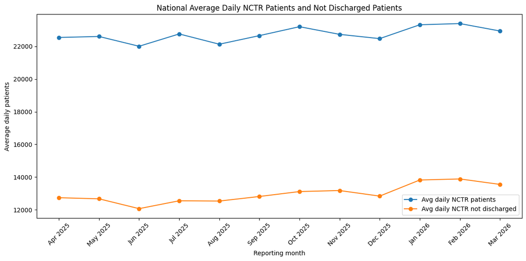

```python
plt.figure(figsize=(12, 6))

plt.plot(
    national_monthly_summary["reporting_month_label"],
    national_monthly_summary["avg_daily_nctr"],
    marker="o",
    label="Avg daily NCTR patients"
)

plt.plot(
    national_monthly_summary["reporting_month_label"],
    national_monthly_summary["avg_daily_not_discharged"],
    marker="o",
    label="Avg daily NCTR not discharged"
)

plt.title("National Average Daily NCTR Patients and Not Discharged Patients")
plt.xlabel("Reporting month")
plt.ylabel("Average daily patients")
plt.xticks(rotation=45)
plt.legend()
plt.tight_layout()

plt.show()
```

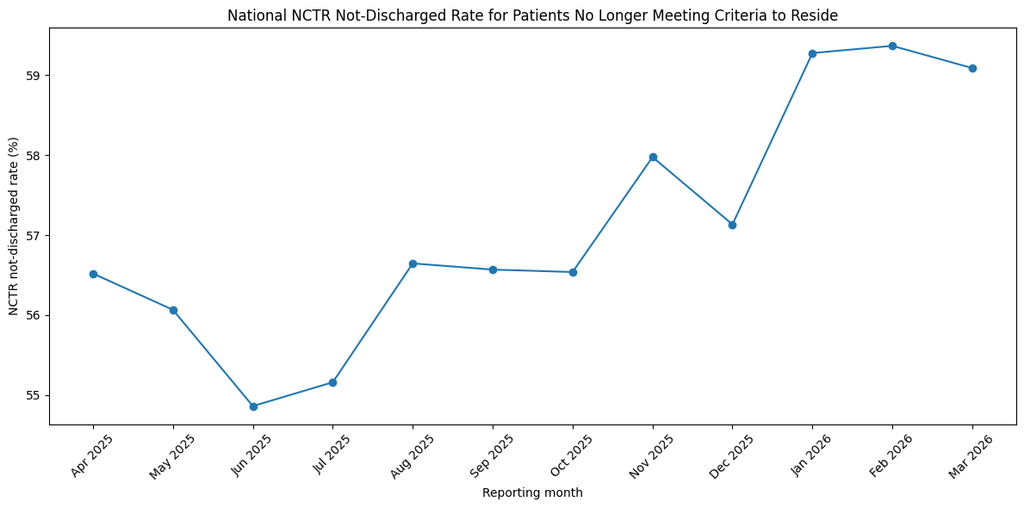

```python
plt.figure(figsize=(12, 6))

plt.plot(
    national_monthly_summary["reporting_month_label"],
    national_monthly_summary["nctr_not_discharged_rate"],
    marker="o"
)

plt.title("National NCTR Not-Discharged Rate for Patients No Longer Meeting Criteria to Reside")
plt.xlabel("Reporting month")
plt.ylabel("NCTR not-discharged rate (%)")
plt.xticks(rotation=45)
plt.tight_layout()

plt.show()
```

```python
national_quarterly_summary = (
    national_monthly_summary
    .groupby("reporting_quarter", as_index=False)
    .agg(
        avg_daily_nctr=("avg_daily_nctr", "mean"),
        avg_daily_discharged=("avg_daily_discharged", "mean"),
        avg_daily_not_discharged=("avg_daily_not_discharged", "mean"),
        total_nctr=("total_nctr", "sum"),
        total_discharged=("total_discharged", "sum"),
        total_not_discharged=("total_not_discharged", "sum")
    )
)

national_quarterly_summary["nctr_not_discharged_rate"] = (
    national_quarterly_summary["total_not_discharged"] /
    national_quarterly_summary["total_nctr"] * 100
)

national_quarterly_summary["nctr_discharged_rate"] = (
    national_quarterly_summary["total_discharged"] /
    national_quarterly_summary["total_nctr"] * 100
)

quarter_order = {"Q1": 1, "Q2": 2, "Q3": 3, "Q4": 4}
national_quarterly_summary["quarter_order"] = national_quarterly_summary["reporting_quarter"].map(quarter_order)

national_quarterly_summary = national_quarterly_summary.sort_values("quarter_order")

display(national_quarterly_summary)
```

|  | reporting_quarter | avg_daily_nctr | avg_daily_discharged | avg_daily_not_discharged | total_nctr | total_discharged | total_not_discharged | nctr_not_discharged_rate | nctr_discharged_rate | quarter_order |
| --- | --- | --- | --- | --- | --- | --- | --- | --- | --- | --- |
| 0 | Q1 | 22382.967384 | 9888.413978 | 12494.553405 | 2037070.0 | 899888.0 | 1137182.0 | 55.824395 | 44.175605 | 1 |
| 1 | Q2 | 22513.665233 | 9879.528315 | 12634.136918 | 2071117.0 | 908957.0 | 1162160.0 | 56.112716 | 43.887284 | 2 |
| 2 | Q3 | 22801.174194 | 9756.321147 | 13044.853047 | 2097777.0 | 897785.0 | 1199992.0 | 57.203030 | 42.796970 | 3 |
| 3 | Q4 | 23216.129416 | 9461.236943 | 13754.892473 | 2088922.0 | 851381.0 | 1237541.0 | 59.243045 | 40.756955 | 4 |

### National Findings

The national daily discharge-flow data shows that a large proportion of patients who no longer met the criteria to reside remained in hospital during 2025–26.

Across the year, the national NCTR not-discharged rate generally remained above 54%. The rate increased towards the end of the financial year, reaching around 59% in Q4.

This suggests that discharge-flow pressure became more visible in the later months of 2025–26. However, this analysis does not prove a direct causal relationship between delayed discharge, bed occupancy or A&E performance.

### Quarterly National Trend

The quarterly national summary shows a clear increase in discharge-flow pressure across 2025–26.

The NCTR not-discharged rate increased from 55.8% in Q1 to 59.2% in Q4. During the same period, the average daily number of patients who no longer met the criteria to reside increased, while the average daily number of NCTR patients discharged decreased.

This suggests that discharge delays became more pronounced toward the end of the financial year, with a larger proportion of patients remaining in hospital after no longer meeting the criteria to reside.

## Regional Discharge Delay Analysis

Regional analysis explores whether discharge-flow pressure was evenly distributed across NHS England regions or concentrated in specific areas.

```python
regional_daily_flow = daily_flow_wide[
    daily_flow_wide["level"] == "Region"
].copy()

print("Regional daily rows:", regional_daily_flow.shape[0])
display(regional_daily_flow.head())
```

```
Regional daily rows: 2555
```

|  | period_date | period | reporting_month | reporting_month_label | reporting_quarter | file_month | level | region | icb | org_code | org_name | patients_discharged | nctr_patients | nctr_not_discharged | nctr_not_discharged_rate | nctr_discharged_rate |
| --- | --- | --- | --- | --- | --- | --- | --- | --- | --- | --- | --- | --- | --- | --- | --- | --- |
| 161 | 2025-04-01 | 01/04/2025 | 2025-04-01 | Apr 2025 | Q1 | apr_2025 | Region | EAST OF ENGLAND | [z] | Y61 | EAST OF ENGLAND | 1357.0 | 2182.0 | 825.0 | 37.809349 | 62.190651 |
| 162 | 2025-04-01 | 01/04/2025 | 2025-04-01 | Apr 2025 | Q1 | apr_2025 | Region | LONDON | [z] | Y56 | LONDON | 1542.0 | 3285.0 | 1743.0 | 53.059361 | 46.940639 |
| 163 | 2025-04-01 | 01/04/2025 | 2025-04-01 | Apr 2025 | Q1 | apr_2025 | Region | MIDLANDS | [z] | Y60 | MIDLANDS | 1883.0 | 4208.0 | 2325.0 | 55.251901 | 44.748099 |
| 164 | 2025-04-01 | 01/04/2025 | 2025-04-01 | Apr 2025 | Q1 | apr_2025 | Region | NORTH EAST AND YORKSHIRE | [z] | Y63 | NORTH EAST AND YORKSHIRE | 1971.0 | 4090.0 | 2119.0 | 51.809291 | 48.190709 |
| 165 | 2025-04-01 | 01/04/2025 | 2025-04-01 | Apr 2025 | Q1 | apr_2025 | Region | NORTH WEST | [z] | Y62 | NORTH WEST | 1511.0 | 3835.0 | 2324.0 | 60.599739 | 39.400261 |

```python
regional_monthly_summary = (
    regional_daily_flow
    .groupby(
        ["region", "reporting_month", "reporting_month_label", "reporting_quarter"],
        as_index=False
    )
    .agg(
        avg_daily_nctr=("nctr_patients", "mean"),
        avg_daily_discharged=("patients_discharged", "mean"),
        avg_daily_not_discharged=("nctr_not_discharged", "mean"),
        total_nctr=("nctr_patients", "sum"),
        total_discharged=("patients_discharged", "sum"),
        total_not_discharged=("nctr_not_discharged", "sum")
    )
)

regional_monthly_summary["nctr_not_discharged_rate"] = (
    regional_monthly_summary["total_not_discharged"] /
    regional_monthly_summary["total_nctr"] * 100
)

regional_monthly_summary["nctr_discharged_rate"] = (
    regional_monthly_summary["total_discharged"] /
    regional_monthly_summary["total_nctr"] * 100
)

regional_monthly_summary = regional_monthly_summary.sort_values(
    ["region", "reporting_month"]
)

display(regional_monthly_summary.head(20))
```

|  | region | reporting_month | reporting_month_label | reporting_quarter | avg_daily_nctr | avg_daily_discharged | avg_daily_not_discharged | total_nctr | total_discharged | total_not_discharged | nctr_not_discharged_rate | nctr_discharged_rate |
| --- | --- | --- | --- | --- | --- | --- | --- | --- | --- | --- | --- | --- |
| 0 | EAST OF ENGLAND | 2025-04-01 | Apr 2025 | Q1 | 1994.200000 | 1253.533333 | 740.666667 | 59826.0 | 37606.0 | 22220.0 | 37.141042 | 62.858958 |
| 1 | EAST OF ENGLAND | 2025-05-01 | May 2025 | Q1 | 2030.354839 | 1256.000000 | 774.354839 | 62941.0 | 38936.0 | 24005.0 | 38.138892 | 61.861108 |
| 2 | EAST OF ENGLAND | 2025-06-01 | Jun 2025 | Q1 | 1993.533333 | 1245.366667 | 748.166667 | 59806.0 | 37361.0 | 22445.0 | 37.529679 | 62.470321 |
| 3 | EAST OF ENGLAND | 2025-07-01 | Jul 2025 | Q2 | 2095.645161 | 1229.645161 | 866.000000 | 64965.0 | 38119.0 | 26846.0 | 41.323790 | 58.676210 |
| 4 | EAST OF ENGLAND | 2025-08-01 | Aug 2025 | Q2 | 1933.612903 | 1124.516129 | 809.096774 | 59942.0 | 34860.0 | 25082.0 | 41.843782 | 58.156218 |
| 5 | EAST OF ENGLAND | 2025-09-01 | Sep 2025 | Q2 | 2035.366667 | 1184.266667 | 851.100000 | 61061.0 | 35528.0 | 25533.0 | 41.815561 | 58.184439 |
| 6 | EAST OF ENGLAND | 2025-10-01 | Oct 2025 | Q3 | 2109.064516 | 1193.709677 | 915.354839 | 65381.0 | 37005.0 | 28376.0 | 43.400988 | 56.599012 |
| 7 | EAST OF ENGLAND | 2025-11-01 | Nov 2025 | Q3 | 2170.966667 | 1100.633333 | 1070.333333 | 65129.0 | 33019.0 | 32110.0 | 49.302154 | 50.697846 |
| 8 | EAST OF ENGLAND | 2025-12-01 | Dec 2025 | Q3 | 2235.419355 | 1118.677419 | 1116.741935 | 69298.0 | 34679.0 | 34619.0 | 49.956709 | 50.043291 |
| 9 | EAST OF ENGLAND | 2026-01-01 | Jan 2026 | Q4 | 2097.548387 | 1102.419355 | 995.129032 | 65024.0 | 34175.0 | 30849.0 | 47.442483 | 52.557517 |
| 10 | EAST OF ENGLAND | 2026-02-01 | Feb 2026 | Q4 | 2096.035714 | 1061.821429 | 1034.214286 | 58689.0 | 29731.0 | 28958.0 | 49.341444 | 50.658556 |
| 11 | EAST OF ENGLAND | 2026-03-01 | Mar 2026 | Q4 | 2136.516129 | 1070.000000 | 1066.516129 | 66232.0 | 33170.0 | 33062.0 | 49.918468 | 50.081532 |
| 12 | LONDON | 2025-04-01 | Apr 2025 | Q1 | 3041.166667 | 1334.400000 | 1706.766667 | 91235.0 | 40032.0 | 51203.0 | 56.122102 | 43.877898 |
| 13 | LONDON | 2025-05-01 | May 2025 | Q1 | 2851.161290 | 1264.709677 | 1586.451613 | 88386.0 | 39206.0 | 49180.0 | 55.642296 | 44.357704 |
| 14 | LONDON | 2025-06-01 | Jun 2025 | Q1 | 2922.133333 | 1331.333333 | 1590.800000 | 87664.0 | 39940.0 | 47724.0 | 54.439679 | 45.560321 |
| 15 | LONDON | 2025-07-01 | Jul 2025 | Q2 | 2879.677419 | 1301.354839 | 1578.322581 | 89270.0 | 40342.0 | 48928.0 | 54.809006 | 45.190994 |
| 16 | LONDON | 2025-08-01 | Aug 2025 | Q2 | 2920.774194 | 1267.322581 | 1653.451613 | 90544.0 | 39287.0 | 51257.0 | 56.610046 | 43.389954 |
| 17 | LONDON | 2025-09-01 | Sep 2025 | Q2 | 2997.300000 | 1270.033333 | 1727.266667 | 89919.0 | 38101.0 | 51818.0 | 57.627420 | 42.372580 |
| 18 | LONDON | 2025-10-01 | Oct 2025 | Q3 | 3041.258065 | 1320.064516 | 1721.193548 | 94279.0 | 40922.0 | 53357.0 | 56.594788 | 43.405212 |
| 19 | LONDON | 2025-11-01 | Nov 2025 | Q3 | 2847.266667 | 1208.200000 | 1639.066667 | 85418.0 | 36246.0 | 49172.0 | 57.566321 | 42.433679 |

```python
regional_year_summary = (
    regional_monthly_summary
    .groupby("region", as_index=False)
    .agg(
        avg_daily_nctr=("avg_daily_nctr", "mean"),
        avg_daily_discharged=("avg_daily_discharged", "mean"),
        avg_daily_not_discharged=("avg_daily_not_discharged", "mean"),
        total_nctr=("total_nctr", "sum"),
        total_discharged=("total_discharged", "sum"),
        total_not_discharged=("total_not_discharged", "sum")
    )
)

regional_year_summary["nctr_not_discharged_rate"] = (
    regional_year_summary["total_not_discharged"] /
    regional_year_summary["total_nctr"] * 100
)

regional_year_summary["nctr_discharged_rate"] = (
    regional_year_summary["total_discharged"] /
    regional_year_summary["total_nctr"] * 100
)

regional_year_summary = regional_year_summary.sort_values(
    "nctr_not_discharged_rate",
    ascending=False
)

display(regional_year_summary)
```

|  | region | avg_daily_nctr | avg_daily_discharged | avg_daily_not_discharged | total_nctr | total_discharged | total_not_discharged | nctr_not_discharged_rate | nctr_discharged_rate |
| --- | --- | --- | --- | --- | --- | --- | --- | --- | --- |
| 5 | SOUTH EAST | 3604.444579 | 1337.016231 | 2267.428347 | 1316193.0 | 488324.0 | 827869.0 | 62.898754 | 37.101246 |
| 4 | NORTH WEST | 3563.807079 | 1368.032380 | 2195.774699 | 1300349.0 | 499098.0 | 801251.0 | 61.618150 | 38.381850 |
| 6 | SOUTH WEST | 2730.724136 | 1146.399379 | 1584.324757 | 996596.0 | 418584.0 | 578012.0 | 57.998627 | 42.001373 |
| 1 | LONDON | 2983.910740 | 1270.699315 | 1713.211425 | 1088734.0 | 463799.0 | 624935.0 | 57.400155 | 42.599845 |
| 3 | NORTH EAST AND YORKSHIRE | 3727.615156 | 1602.241731 | 2125.373425 | 1360315.0 | 584989.0 | 775326.0 | 56.996063 | 43.003937 |
| 2 | MIDLANDS | 4040.627061 | 1860.270296 | 2180.356765 | 1474405.0 | 679028.0 | 795377.0 | 53.945626 | 46.054374 |
| 0 | EAST OF ENGLAND | 2077.355306 | 1161.715764 | 915.639542 | 758294.0 | 424189.0 | 334105.0 | 44.060088 | 55.939912 |

```python
regional_q4_summary = (
    regional_monthly_summary[
        regional_monthly_summary["reporting_quarter"] == "Q4"
    ]
    .groupby("region", as_index=False)
    .agg(
        avg_daily_nctr=("avg_daily_nctr", "mean"),
        avg_daily_discharged=("avg_daily_discharged", "mean"),
        avg_daily_not_discharged=("avg_daily_not_discharged", "mean"),
        total_nctr=("total_nctr", "sum"),
        total_discharged=("total_discharged", "sum"),
        total_not_discharged=("total_not_discharged", "sum")
    )
)

regional_q4_summary["nctr_not_discharged_rate"] = (
    regional_q4_summary["total_not_discharged"] /
    regional_q4_summary["total_nctr"] * 100
)

regional_q4_summary["nctr_discharged_rate"] = (
    regional_q4_summary["total_discharged"] /
    regional_q4_summary["total_nctr"] * 100
)

regional_q4_summary = regional_q4_summary.sort_values(
    "nctr_not_discharged_rate",
    ascending=False
)

display(regional_q4_summary)
```

|  | region | avg_daily_nctr | avg_daily_discharged | avg_daily_not_discharged | total_nctr | total_discharged | total_not_discharged | nctr_not_discharged_rate | nctr_discharged_rate |
| --- | --- | --- | --- | --- | --- | --- | --- | --- | --- |
| 5 | SOUTH EAST | 3485.685484 | 1233.887865 | 2251.797619 | 313992.0 | 111125.0 | 202867.0 | 64.608971 | 35.391029 |
| 3 | NORTH EAST AND YORKSHIRE | 3822.006144 | 1474.907066 | 2347.099078 | 343822.0 | 132685.0 | 211137.0 | 61.408810 | 38.591190 |
| 4 | NORTH WEST | 3742.327957 | 1460.469662 | 2281.858295 | 336494.0 | 131228.0 | 205266.0 | 61.001385 | 38.998615 |
| 1 | LONDON | 3108.246544 | 1237.152458 | 1871.094086 | 279594.0 | 111298.0 | 168296.0 | 60.192994 | 39.807006 |
| 6 | SOUTH WEST | 2769.937404 | 1117.150922 | 1652.786482 | 249221.0 | 100599.0 | 148622.0 | 59.634621 | 40.365379 |
| 2 | MIDLANDS | 4177.892473 | 1859.588710 | 2318.303763 | 375854.0 | 167370.0 | 208484.0 | 55.469411 | 44.530589 |
| 0 | EAST OF ENGLAND | 2110.033410 | 1078.080261 | 1031.953149 | 189945.0 | 97076.0 | 92869.0 | 48.892574 | 51.107426 |

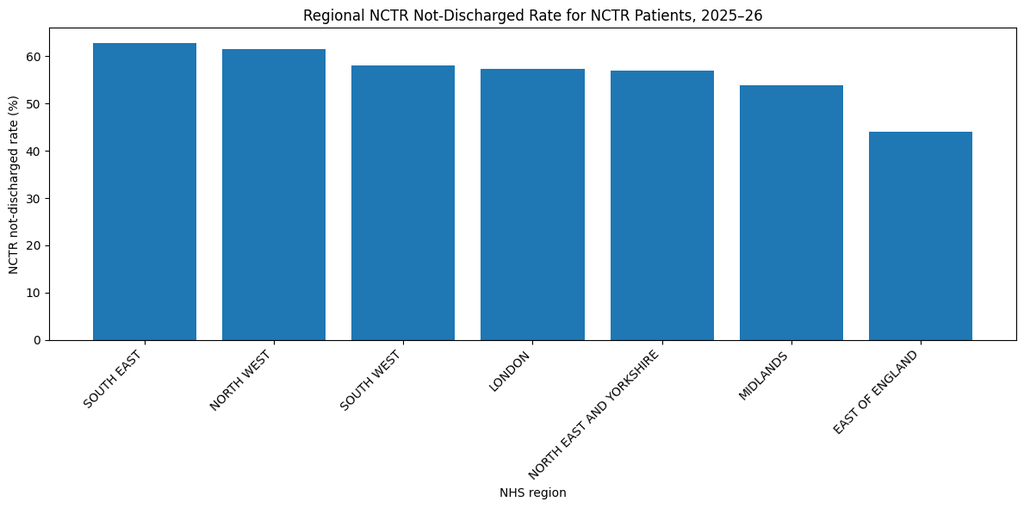

```python
plt.figure(figsize=(12, 6))

plt.bar(
    regional_year_summary["region"],
    regional_year_summary["nctr_not_discharged_rate"]
)

plt.title("Regional NCTR Not-Discharged Rate for NCTR Patients, 2025–26")
plt.xlabel("NHS region")
plt.ylabel("NCTR not-discharged rate (%)")
plt.xticks(rotation=45, ha="right")
plt.tight_layout()

plt.show()
```

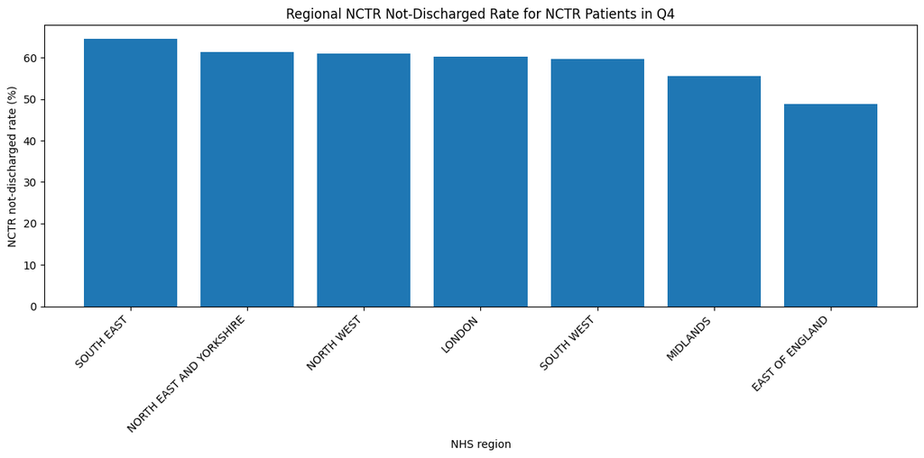

```python
plt.figure(figsize=(12, 6))

plt.bar(
    regional_q4_summary["region"],
    regional_q4_summary["nctr_not_discharged_rate"]
)

plt.title("Regional NCTR Not-Discharged Rate for NCTR Patients in Q4")
plt.xlabel("NHS region")
plt.ylabel("NCTR not-discharged rate (%)")
plt.xticks(rotation=45, ha="right")
plt.tight_layout()

plt.show()
```

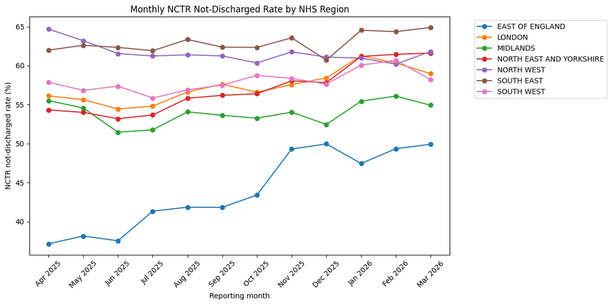

```python
plt.figure(figsize=(12, 6))

for region in regional_monthly_summary["region"].unique():
    temp = regional_monthly_summary[
        regional_monthly_summary["region"] == region
    ]

    plt.plot(
        temp["reporting_month_label"],
        temp["nctr_not_discharged_rate"],
        marker="o",
        label=region
    )

plt.title("Monthly NCTR Not-Discharged Rate by NHS Region")
plt.xlabel("Reporting month")
plt.ylabel("NCTR not-discharged rate (%)")
plt.xticks(rotation=45)
plt.legend(bbox_to_anchor=(1.05, 1), loc="upper left")
plt.tight_layout()

plt.show()
```

### Regional Findings

Regional analysis shows that discharge-flow pressure was not evenly distributed across NHS regions during 2025–26.

Across the full financial year, the South East had the highest annual NCTR not-discharged rate, followed by the North West and South West. The East of England had the lowest NCTR not-discharged rate and the highest NCTR discharged rate.

Q4 showed particularly high regional discharge-flow pressure. Several regions had NCTR not-discharged rates above 60%, including the South East, North East and Yorkshire, North West and London.

## ICB-Level Discharge Delay Analysis

ICB-level analysis provides a more detailed view of variation within and across regions.

```python
icb_daily_flow = daily_flow_wide[
    daily_flow_wide["level"] == "ICB"
].copy()

print("ICB daily rows:", icb_daily_flow.shape[0])
display(icb_daily_flow.head())
```

```
ICB daily rows: 15330
```

|  | period_date | period | reporting_month | reporting_month_label | reporting_quarter | file_month | level | region | icb | org_code | org_name | patients_discharged | nctr_patients | nctr_not_discharged | nctr_not_discharged_rate | nctr_discharged_rate |
| --- | --- | --- | --- | --- | --- | --- | --- | --- | --- | --- | --- | --- | --- | --- | --- | --- |
| 0 | 2025-04-01 | 01/04/2025 | 2025-04-01 | Apr 2025 | Q1 | apr_2025 | ICB | EAST OF ENGLAND | NHS BEDFORDSHIRE, LUTON AND MILTON KEYNES INTEGRATED CARE BOARD | QHG | NHS BEDFORDSHIRE, LUTON AND MILTON KEYNES INTEGRATED CARE BOARD | 201.0 | 409.0 | 208.0 | 50.855746 | 49.144254 |
| 1 | 2025-04-01 | 01/04/2025 | 2025-04-01 | Apr 2025 | Q1 | apr_2025 | ICB | EAST OF ENGLAND | NHS CAMBRIDGESHIRE AND PETERBOROUGH INTEGRATED CARE BOARD | QUE | NHS CAMBRIDGESHIRE AND PETERBOROUGH INTEGRATED CARE BOARD | 223.0 | 330.0 | 107.0 | 32.424242 | 67.575758 |
| 2 | 2025-04-01 | 01/04/2025 | 2025-04-01 | Apr 2025 | Q1 | apr_2025 | ICB | EAST OF ENGLAND | NHS HERTFORDSHIRE AND WEST ESSEX INTEGRATED CARE BOARD | QM7 | NHS HERTFORDSHIRE AND WEST ESSEX INTEGRATED CARE BOARD | 209.0 | 359.0 | 150.0 | 41.782730 | 58.217270 |
| 3 | 2025-04-01 | 01/04/2025 | 2025-04-01 | Apr 2025 | Q1 | apr_2025 | ICB | EAST OF ENGLAND | NHS MID AND SOUTH ESSEX INTEGRATED CARE BOARD | QH8 | NHS MID AND SOUTH ESSEX INTEGRATED CARE BOARD | 279.0 | 365.0 | 86.0 | 23.561644 | 76.438356 |
| 4 | 2025-04-01 | 01/04/2025 | 2025-04-01 | Apr 2025 | Q1 | apr_2025 | ICB | EAST OF ENGLAND | NHS NORFOLK AND WAVENEY INTEGRATED CARE BOARD | QMM | NHS NORFOLK AND WAVENEY INTEGRATED CARE BOARD | 212.0 | 359.0 | 147.0 | 40.947075 | 59.052925 |

```python
icb_year_summary = (
    icb_daily_flow
    .groupby(["region", "icb", "org_code", "org_name"], as_index=False)
    .agg(
        avg_daily_nctr=("nctr_patients", "mean"),
        avg_daily_discharged=("patients_discharged", "mean"),
        avg_daily_not_discharged=("nctr_not_discharged", "mean"),
        total_nctr=("nctr_patients", "sum"),
        total_discharged=("patients_discharged", "sum"),
        total_not_discharged=("nctr_not_discharged", "sum")
    )
)

icb_year_summary["nctr_not_discharged_rate"] = (
    icb_year_summary["total_not_discharged"] /
    icb_year_summary["total_nctr"] * 100
)

icb_year_summary["nctr_discharged_rate"] = (
    icb_year_summary["total_discharged"] /
    icb_year_summary["total_nctr"] * 100
)

icb_year_summary = icb_year_summary.sort_values(
    "nctr_not_discharged_rate",
    ascending=False
)

display(icb_year_summary.head(15))
```

|  | region | icb | org_code | org_name | avg_daily_nctr | avg_daily_discharged | avg_daily_not_discharged | total_nctr | total_discharged | total_not_discharged | nctr_not_discharged_rate | nctr_discharged_rate |
| --- | --- | --- | --- | --- | --- | --- | --- | --- | --- | --- | --- | --- |
| 34 | SOUTH EAST | NHS SUSSEX INTEGRATED CARE BOARD | QNX | NHS SUSSEX INTEGRATED CARE BOARD | 748.846575 | 205.471233 | 543.375342 | 273329.0 | 74997.0 | 198332.0 | 72.561638 | 27.438362 |
| 18 | MIDLANDS | NHS NORTHAMPTONSHIRE INTEGRATED CARE BOARD | QPM | NHS NORTHAMPTONSHIRE INTEGRATED CARE BOARD | 271.465753 | 86.739726 | 184.726027 | 99085.0 | 31660.0 | 67425.0 | 68.047636 | 31.952364 |
| 17 | MIDLANDS | NHS LINCOLNSHIRE INTEGRATED CARE BOARD | QJM | NHS LINCOLNSHIRE INTEGRATED CARE BOARD | 234.649315 | 77.545205 | 157.104110 | 85647.0 | 28304.0 | 57343.0 | 66.952725 | 33.047275 |
| 10 | LONDON | NHS SOUTH WEST LONDON INTEGRATED CARE BOARD | QWE | NHS SOUTH WEST LONDON INTEGRATED CARE BOARD | 412.726027 | 136.942466 | 275.783562 | 150645.0 | 49984.0 | 100661.0 | 66.820007 | 33.179993 |
| 22 | NORTH EAST AND YORKSHIRE | NHS HUMBER AND NORTH YORKSHIRE INTEGRATED CARE BOARD | QOQ | NHS HUMBER AND NORTH YORKSHIRE INTEGRATED CARE BOARD | 541.397260 | 184.528767 | 356.868493 | 197610.0 | 67353.0 | 130257.0 | 65.916199 | 34.083801 |
| 26 | NORTH WEST | NHS CHESHIRE AND MERSEYSIDE INTEGRATED CARE BOARD | QYG | NHS CHESHIRE AND MERSEYSIDE INTEGRATED CARE BOARD | 1603.391781 | 548.654795 | 1054.736986 | 585238.0 | 200259.0 | 384979.0 | 65.781614 | 34.218386 |
| 31 | SOUTH EAST | NHS HAMPSHIRE AND ISLE OF WIGHT INTEGRATED CARE BOARD | QRL | NHS HAMPSHIRE AND ISLE OF WIGHT INTEGRATED CARE BOARD | 1081.942466 | 377.117808 | 704.824658 | 394909.0 | 137648.0 | 257261.0 | 65.144375 | 34.855625 |
| 41 | SOUTH WEST | NHS SOMERSET INTEGRATED CARE BOARD | QSL | NHS SOMERSET INTEGRATED CARE BOARD | 301.071233 | 107.638356 | 193.432877 | 109891.0 | 39288.0 | 70603.0 | 64.248210 | 35.751790 |
| 13 | MIDLANDS | NHS COVENTRY AND WARWICKSHIRE INTEGRATED CARE BOARD | QWU | NHS COVENTRY AND WARWICKSHIRE INTEGRATED CARE BOARD | 357.882192 | 130.975342 | 226.906849 | 130627.0 | 47806.0 | 82821.0 | 63.402666 | 36.597334 |
| 32 | SOUTH EAST | NHS KENT AND MEDWAY INTEGRATED CARE BOARD | QKS | NHS KENT AND MEDWAY INTEGRATED CARE BOARD | 678.816438 | 250.539726 | 428.276712 | 247768.0 | 91447.0 | 156321.0 | 63.091683 | 36.908317 |
| 27 | NORTH WEST | NHS GREATER MANCHESTER INTEGRATED CARE BOARD | QOP | NHS GREATER MANCHESTER INTEGRATED CARE BOARD | 1256.671233 | 467.035616 | 789.635616 | 458685.0 | 170468.0 | 288217.0 | 62.835497 | 37.164503 |
| 39 | SOUTH WEST | NHS DORSET INTEGRATED CARE BOARD | QVV | NHS DORSET INTEGRATED CARE BOARD | 429.482192 | 160.756164 | 268.726027 | 156761.0 | 58676.0 | 98085.0 | 62.569772 | 37.430228 |
| 36 | SOUTH WEST | NHS BRISTOL, NORTH SOMERSET AND SOUTH GLOUCESTERSHIRE INTEGRATED CARE BOARD | QUY | NHS BRISTOL, NORTH SOMERSET AND SOUTH GLOUCESTERSHIRE INTEGRATED CARE BOARD | 587.846575 | 220.515068 | 367.331507 | 214564.0 | 80488.0 | 134076.0 | 62.487649 | 37.512351 |
| 11 | MIDLANDS | NHS BIRMINGHAM AND SOLIHULL INTEGRATED CARE BOARD | QHL | NHS BIRMINGHAM AND SOLIHULL INTEGRATED CARE BOARD | 465.882192 | 175.427397 | 290.454795 | 170047.0 | 64031.0 | 106016.0 | 62.345116 | 37.654884 |
| 30 | SOUTH EAST | NHS FRIMLEY INTEGRATED CARE BOARD | QNQ | NHS FRIMLEY INTEGRATED CARE BOARD | 308.975342 | 124.394521 | 184.580822 | 112776.0 | 45404.0 | 67372.0 | 59.739661 | 40.260339 |

```python
display(icb_year_summary[["total_nctr", "nctr_not_discharged_rate"]].describe())
```

|  | total_nctr | nctr_not_discharged_rate |
| --- | --- | --- |
| count | 42.000000 | 42.000000 |
| mean | 197497.285714 | 55.666135 |
| std | 116081.117887 | 9.018386 |
| min | 61279.000000 | 29.650606 |
| 25% | 121609.750000 | 49.501113 |
| 50% | 163572.000000 | 56.143027 |
| 75% | 236646.250000 | 62.769066 |
| max | 585238.000000 | 72.561638 |

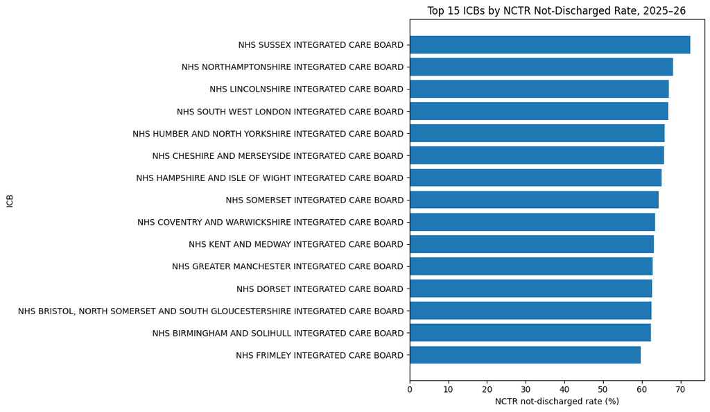

```python
top15_icb_not_discharged = icb_year_summary.head(15).copy()

plt.figure(figsize=(12, 7))

plt.barh(
    top15_icb_not_discharged["org_name"],
    top15_icb_not_discharged["nctr_not_discharged_rate"]
)

plt.title("Top 15 ICBs by NCTR Not-Discharged Rate, 2025–26")
plt.xlabel("NCTR not-discharged rate (%)")
plt.ylabel("ICB")
plt.gca().invert_yaxis()
plt.tight_layout()

plt.show()
```

```python
icb_year_summary.to_csv(
    os.path.join(tables_path, "icb_discharge_delay_summary_2025_26.csv"),
    index=False
)

print("ICB summary saved.")
```

```
ICB summary saved.
```

### ICB-Level Findings

ICB-level analysis shows substantial variation in the proportion of patients who no longer met the criteria to reside but were not discharged.

Across 2025–26, NHS Sussex Integrated Care Board had the highest NCTR not-discharged rate among ICBs, followed by NHS Northamptonshire Integrated Care Board, NHS Lincolnshire Integrated Care Board, NHS South West London Integrated Care Board and NHS Humber and North Yorkshire Integrated Care Board.

This suggests that discharge-flow pressure varied meaningfully within and across regions, highlighting the importance of analysing ICB-level patterns rather than relying only on national or regional averages.

## Provider-Level Discharge Delay Analysis

Provider-level analysis explores variation between acute providers. To support fairer comparison, annual provider rankings are restricted to organisations with at least 300 reporting days and at least 10,000 NCTR patients during 2025–26.

```python
provider_daily_flow = daily_flow_wide[
    daily_flow_wide["level"] == "PROVIDER"
].copy()

print("Provider daily rows:", provider_daily_flow.shape[0])
display(provider_daily_flow.head())
```

```
Provider daily rows: 43070
```

|  | period_date | period | reporting_month | reporting_month_label | reporting_quarter | file_month | level | region | icb | org_code | org_name | patients_discharged | nctr_patients | nctr_not_discharged | nctr_not_discharged_rate | nctr_discharged_rate |
| --- | --- | --- | --- | --- | --- | --- | --- | --- | --- | --- | --- | --- | --- | --- | --- | --- |
| 43 | 2025-04-01 | 01/04/2025 | 2025-04-01 | Apr 2025 | Q1 | apr_2025 | PROVIDER | EAST OF ENGLAND | NHS BEDFORDSHIRE, LUTON AND MILTON KEYNES INTEGRATED CARE BOARD | RC9 | BEDFORDSHIRE HOSPITALS NHS FOUNDATION TRUST | 112.0 | 203.0 | 91.0 | 44.827586 | 55.172414 |
| 44 | 2025-04-01 | 01/04/2025 | 2025-04-01 | Apr 2025 | Q1 | apr_2025 | PROVIDER | EAST OF ENGLAND | NHS BEDFORDSHIRE, LUTON AND MILTON KEYNES INTEGRATED CARE BOARD | RD8 | MILTON KEYNES UNIVERSITY HOSPITAL NHS FOUNDATION TRUST | 89.0 | 206.0 | 117.0 | 56.796117 | 43.203883 |
| 45 | 2025-04-01 | 01/04/2025 | 2025-04-01 | Apr 2025 | Q1 | apr_2025 | PROVIDER | EAST OF ENGLAND | NHS CAMBRIDGESHIRE AND PETERBOROUGH INTEGRATED CARE BOARD | RGN | NORTH WEST ANGLIA NHS FOUNDATION TRUST | 116.0 | 134.0 | 18.0 | 13.432836 | 86.567164 |
| 46 | 2025-04-01 | 01/04/2025 | 2025-04-01 | Apr 2025 | Q1 | apr_2025 | PROVIDER | EAST OF ENGLAND | NHS CAMBRIDGESHIRE AND PETERBOROUGH INTEGRATED CARE BOARD | RGT | CAMBRIDGE UNIVERSITY HOSPITALS NHS FOUNDATION TRUST | 107.0 | 196.0 | 89.0 | 45.408163 | 54.591837 |
| 47 | 2025-04-01 | 01/04/2025 | 2025-04-01 | Apr 2025 | Q1 | apr_2025 | PROVIDER | EAST OF ENGLAND | NHS HERTFORDSHIRE AND WEST ESSEX INTEGRATED CARE BOARD | RQW | THE PRINCESS ALEXANDRA HOSPITAL NHS TRUST | 48.0 | 90.0 | 42.0 | 46.666667 | 53.333333 |

```python
provider_year_summary = (
    provider_daily_flow
    .groupby(["region", "icb", "org_code", "org_name"], as_index=False)
    .agg(
        avg_daily_nctr=("nctr_patients", "mean"),
        avg_daily_discharged=("patients_discharged", "mean"),
        avg_daily_not_discharged=("nctr_not_discharged", "mean"),
        total_nctr=("nctr_patients", "sum"),
        total_discharged=("patients_discharged", "sum"),
        total_not_discharged=("nctr_not_discharged", "sum"),
        reporting_days=("period_date", "nunique")
    )
)

provider_year_summary["nctr_not_discharged_rate"] = (
    provider_year_summary["total_not_discharged"] /
    provider_year_summary["total_nctr"] * 100
)

provider_year_summary["nctr_discharged_rate"] = (
    provider_year_summary["total_discharged"] /
    provider_year_summary["total_nctr"] * 100
)

provider_year_summary = provider_year_summary.sort_values(
    "nctr_not_discharged_rate",
    ascending=False
)

display(provider_year_summary.head(20))
```

|  | region | icb | org_code | org_name | avg_daily_nctr | avg_daily_discharged | avg_daily_not_discharged | total_nctr | total_discharged | total_not_discharged | reporting_days | nctr_not_discharged_rate | nctr_discharged_rate |
| --- | --- | --- | --- | --- | --- | --- | --- | --- | --- | --- | --- | --- | --- |
| 79 | NORTH WEST | NHS GREATER MANCHESTER INTEGRATED CARE BOARD | RM3 | NORTHERN CARE ALLIANCE NHS FOUNDATION TRUST | 213.953425 | 12.183562 | 201.769863 | 78093.0 | 4447.0 | 73646.0 | 365 | 94.305508 | 5.694492 |
| 28 | LONDON | NHS SOUTH WEST LONDON INTEGRATED CARE BOARD | RJ7 | ST GEORGE'S UNIVERSITY HOSPITALS NHS FOUNDATION TRUST | 114.230137 | 18.347945 | 95.882192 | 41694.0 | 6697.0 | 34997.0 | 365 | 83.937737 | 16.062263 |
| 31 | MIDLANDS | NHS BLACK COUNTRY INTEGRATED CARE BOARD | RBK | WALSALL HEALTHCARE NHS TRUST | 87.465753 | 15.624658 | 71.841096 | 31925.0 | 5703.0 | 26222.0 | 365 | 82.136257 | 17.863743 |
| 51 | NORTH EAST AND YORKSHIRE | NHS HUMBER AND NORTH YORKSHIRE INTEGRATED CARE BOARD | RJL | NORTHERN LINCOLNSHIRE AND GOOLE NHS FOUNDATION TRUST | 106.350685 | 20.156164 | 86.194521 | 38818.0 | 7357.0 | 31461.0 | 365 | 81.047452 | 18.952548 |
| 44 | MIDLANDS | NHS NORTHAMPTONSHIRE INTEGRATED CARE BOARD | RNS | NORTHAMPTON GENERAL HOSPITAL NHS TRUST | 153.254795 | 30.819178 | 122.435616 | 55938.0 | 11249.0 | 44689.0 | 365 | 79.890236 | 20.109764 |
| 75 | NORTH WEST | NHS CHESHIRE AND MERSEYSIDE INTEGRATED CARE BOARD | RJN | EAST CHESHIRE NHS TRUST | 77.008219 | 17.038356 | 59.969863 | 28108.0 | 6219.0 | 21889.0 | 365 | 77.874626 | 22.125374 |
| 103 | SOUTH EAST | NHS SUSSEX INTEGRATED CARE BOARD | RXC | EAST SUSSEX HEALTHCARE NHS TRUST | 215.410959 | 48.134247 | 167.276712 | 78625.0 | 17569.0 | 61056.0 | 365 | 77.654690 | 22.345310 |
| 64 | NORTH EAST AND YORKSHIRE | NHS SOUTH YORKSHIRE INTEGRATED CARE BOARD | RP5 | DONCASTER AND BASSETLAW TEACHING HOSPITALS NHS FOUNDATION TRUST | 137.024658 | 31.684932 | 105.339726 | 50014.0 | 11565.0 | 38449.0 | 365 | 76.876475 | 23.123525 |
| 29 | LONDON | NHS SOUTH WEST LONDON INTEGRATED CARE BOARD | RVR | EPSOM AND ST HELIER UNIVERSITY HOSPITALS NHS TRUST | 163.443836 | 41.443836 | 122.000000 | 59657.0 | 15127.0 | 44530.0 | 365 | 74.643378 | 25.356622 |
| 66 | NORTH EAST AND YORKSHIRE | NHS WEST YORKSHIRE INTEGRATED CARE BOARD | RCD | HARROGATE AND DISTRICT NHS FOUNDATION TRUST | 34.334247 | 9.131507 | 25.202740 | 12532.0 | 3333.0 | 9199.0 | 365 | 73.404086 | 26.595914 |
| 60 | NORTH EAST AND YORKSHIRE | NHS NORTH EAST AND NORTH CUMBRIA INTEGRATED CARE BOARD | RXP | COUNTY DURHAM AND DARLINGTON NHS FOUNDATION TRUST | 62.926027 | 17.065753 | 45.860274 | 22968.0 | 6229.0 | 16739.0 | 365 | 72.879659 | 27.120341 |
| 50 | NORTH EAST AND YORKSHIRE | NHS HUMBER AND NORTH YORKSHIRE INTEGRATED CARE BOARD | RCB | YORK AND SCARBOROUGH TEACHING HOSPITALS NHS FOUNDATION TRUST | 158.630137 | 43.553425 | 115.076712 | 57900.0 | 15897.0 | 42003.0 | 365 | 72.544041 | 27.455959 |
| 36 | MIDLANDS | NHS COVENTRY AND WARWICKSHIRE INTEGRATED CARE BOARD | RKB | UNIVERSITY HOSPITALS COVENTRY AND WARWICKSHIRE NHS TRUST | 236.649315 | 66.408219 | 170.241096 | 86377.0 | 24239.0 | 62138.0 | 365 | 71.938132 | 28.061868 |
| 104 | SOUTH EAST | NHS SUSSEX INTEGRATED CARE BOARD | RYR | UNIVERSITY HOSPITALS SUSSEX NHS FOUNDATION TRUST | 533.435616 | 157.336986 | 376.098630 | 194704.0 | 57428.0 | 137276.0 | 365 | 70.504972 | 29.495028 |
| 77 | NORTH WEST | NHS CHESHIRE AND MERSEYSIDE INTEGRATED CARE BOARD | RWW | WARRINGTON AND HALTON TEACHING HOSPITALS NHS FOUNDATION TRUST | 175.813699 | 51.895890 | 123.917808 | 64172.0 | 18942.0 | 45230.0 | 365 | 70.482453 | 29.517547 |
| 84 | NORTH WEST | NHS LANCASHIRE AND SOUTH CUMBRIA INTEGRATED CARE BOARD | RTX | UNIVERSITY HOSPITALS OF MORECAMBE BAY NHS FOUNDATION TRUST | 202.424658 | 63.134247 | 139.290411 | 73885.0 | 23044.0 | 50841.0 | 365 | 68.810990 | 31.189010 |
| 97 | SOUTH EAST | NHS KENT AND MEDWAY INTEGRATED CARE BOARD | RPA | MEDWAY NHS FOUNDATION TRUST | 179.939726 | 56.293151 | 123.646575 | 65678.0 | 20547.0 | 45131.0 | 365 | 68.715552 | 31.284448 |
| 74 | NORTH WEST | NHS CHESHIRE AND MERSEYSIDE INTEGRATED CARE BOARD | REM | LIVERPOOL UNIVERSITY HOSPITALS NHS FOUNDATION TRUST | 476.868493 | 149.350685 | 327.517808 | 174057.0 | 54513.0 | 119544.0 | 365 | 68.680949 | 31.319051 |
| 94 | SOUTH EAST | NHS HAMPSHIRE AND ISLE OF WIGHT INTEGRATED CARE BOARD | RHU | PORTSMOUTH HOSPITALS UNIVERSITY NATIONAL HEALTH SERVICE TRUST | 375.835616 | 118.065753 | 257.769863 | 137180.0 | 43094.0 | 94086.0 | 365 | 68.585800 | 31.414200 |
| 14 | LONDON | NHS NORTH CENTRAL LONDON INTEGRATED CARE BOARD | RKE | WHITTINGTON HEALTH NHS TRUST | 68.797260 | 21.693151 | 47.104110 | 25111.0 | 7918.0 | 17193.0 | 365 | 68.468002 | 31.531998 |

```python
display(
    provider_year_summary[
        ["total_nctr", "reporting_days", "nctr_not_discharged_rate"]
    ].describe()
)
```

|  | total_nctr | reporting_days | nctr_not_discharged_rate |
| --- | --- | --- | --- |
| count | 119.000000 | 119.000000 | 119.000000 |
| mean | 69704.924370 | 361.932773 | 55.897408 |
| std | 39515.206452 | 30.809071 | 13.555953 |
| min | 6245.000000 | 30.000000 | 15.883966 |
| 25% | 41993.000000 | 365.000000 | 47.534423 |
| 50% | 59657.000000 | 365.000000 | 56.356937 |
| 75% | 86012.000000 | 365.000000 | 63.371171 |
| max | 195389.000000 | 365.000000 | 94.305508 |

```python
provider_comparison = provider_year_summary[
    (provider_year_summary["reporting_days"] >= 300) &
    (provider_year_summary["total_nctr"] >= 10000)
].copy()

print("All providers:", provider_year_summary.shape[0])
print("Providers included after threshold:", provider_comparison.shape[0])
print("Providers excluded:", provider_year_summary.shape[0] - provider_comparison.shape[0])

display(provider_comparison.head(20))
```

```
All providers: 119
Providers included after threshold: 118
Providers excluded: 1
```

|  | region | icb | org_code | org_name | avg_daily_nctr | avg_daily_discharged | avg_daily_not_discharged | total_nctr | total_discharged | total_not_discharged | reporting_days | nctr_not_discharged_rate | nctr_discharged_rate |
| --- | --- | --- | --- | --- | --- | --- | --- | --- | --- | --- | --- | --- | --- |
| 79 | NORTH WEST | NHS GREATER MANCHESTER INTEGRATED CARE BOARD | RM3 | NORTHERN CARE ALLIANCE NHS FOUNDATION TRUST | 213.953425 | 12.183562 | 201.769863 | 78093.0 | 4447.0 | 73646.0 | 365 | 94.305508 | 5.694492 |
| 28 | LONDON | NHS SOUTH WEST LONDON INTEGRATED CARE BOARD | RJ7 | ST GEORGE'S UNIVERSITY HOSPITALS NHS FOUNDATION TRUST | 114.230137 | 18.347945 | 95.882192 | 41694.0 | 6697.0 | 34997.0 | 365 | 83.937737 | 16.062263 |
| 31 | MIDLANDS | NHS BLACK COUNTRY INTEGRATED CARE BOARD | RBK | WALSALL HEALTHCARE NHS TRUST | 87.465753 | 15.624658 | 71.841096 | 31925.0 | 5703.0 | 26222.0 | 365 | 82.136257 | 17.863743 |
| 51 | NORTH EAST AND YORKSHIRE | NHS HUMBER AND NORTH YORKSHIRE INTEGRATED CARE BOARD | RJL | NORTHERN LINCOLNSHIRE AND GOOLE NHS FOUNDATION TRUST | 106.350685 | 20.156164 | 86.194521 | 38818.0 | 7357.0 | 31461.0 | 365 | 81.047452 | 18.952548 |
| 44 | MIDLANDS | NHS NORTHAMPTONSHIRE INTEGRATED CARE BOARD | RNS | NORTHAMPTON GENERAL HOSPITAL NHS TRUST | 153.254795 | 30.819178 | 122.435616 | 55938.0 | 11249.0 | 44689.0 | 365 | 79.890236 | 20.109764 |
| 75 | NORTH WEST | NHS CHESHIRE AND MERSEYSIDE INTEGRATED CARE BOARD | RJN | EAST CHESHIRE NHS TRUST | 77.008219 | 17.038356 | 59.969863 | 28108.0 | 6219.0 | 21889.0 | 365 | 77.874626 | 22.125374 |
| 103 | SOUTH EAST | NHS SUSSEX INTEGRATED CARE BOARD | RXC | EAST SUSSEX HEALTHCARE NHS TRUST | 215.410959 | 48.134247 | 167.276712 | 78625.0 | 17569.0 | 61056.0 | 365 | 77.654690 | 22.345310 |
| 64 | NORTH EAST AND YORKSHIRE | NHS SOUTH YORKSHIRE INTEGRATED CARE BOARD | RP5 | DONCASTER AND BASSETLAW TEACHING HOSPITALS NHS FOUNDATION TRUST | 137.024658 | 31.684932 | 105.339726 | 50014.0 | 11565.0 | 38449.0 | 365 | 76.876475 | 23.123525 |
| 29 | LONDON | NHS SOUTH WEST LONDON INTEGRATED CARE BOARD | RVR | EPSOM AND ST HELIER UNIVERSITY HOSPITALS NHS TRUST | 163.443836 | 41.443836 | 122.000000 | 59657.0 | 15127.0 | 44530.0 | 365 | 74.643378 | 25.356622 |
| 66 | NORTH EAST AND YORKSHIRE | NHS WEST YORKSHIRE INTEGRATED CARE BOARD | RCD | HARROGATE AND DISTRICT NHS FOUNDATION TRUST | 34.334247 | 9.131507 | 25.202740 | 12532.0 | 3333.0 | 9199.0 | 365 | 73.404086 | 26.595914 |
| 60 | NORTH EAST AND YORKSHIRE | NHS NORTH EAST AND NORTH CUMBRIA INTEGRATED CARE BOARD | RXP | COUNTY DURHAM AND DARLINGTON NHS FOUNDATION TRUST | 62.926027 | 17.065753 | 45.860274 | 22968.0 | 6229.0 | 16739.0 | 365 | 72.879659 | 27.120341 |
| 50 | NORTH EAST AND YORKSHIRE | NHS HUMBER AND NORTH YORKSHIRE INTEGRATED CARE BOARD | RCB | YORK AND SCARBOROUGH TEACHING HOSPITALS NHS FOUNDATION TRUST | 158.630137 | 43.553425 | 115.076712 | 57900.0 | 15897.0 | 42003.0 | 365 | 72.544041 | 27.455959 |
| 36 | MIDLANDS | NHS COVENTRY AND WARWICKSHIRE INTEGRATED CARE BOARD | RKB | UNIVERSITY HOSPITALS COVENTRY AND WARWICKSHIRE NHS TRUST | 236.649315 | 66.408219 | 170.241096 | 86377.0 | 24239.0 | 62138.0 | 365 | 71.938132 | 28.061868 |
| 104 | SOUTH EAST | NHS SUSSEX INTEGRATED CARE BOARD | RYR | UNIVERSITY HOSPITALS SUSSEX NHS FOUNDATION TRUST | 533.435616 | 157.336986 | 376.098630 | 194704.0 | 57428.0 | 137276.0 | 365 | 70.504972 | 29.495028 |
| 77 | NORTH WEST | NHS CHESHIRE AND MERSEYSIDE INTEGRATED CARE BOARD | RWW | WARRINGTON AND HALTON TEACHING HOSPITALS NHS FOUNDATION TRUST | 175.813699 | 51.895890 | 123.917808 | 64172.0 | 18942.0 | 45230.0 | 365 | 70.482453 | 29.517547 |
| 84 | NORTH WEST | NHS LANCASHIRE AND SOUTH CUMBRIA INTEGRATED CARE BOARD | RTX | UNIVERSITY HOSPITALS OF MORECAMBE BAY NHS FOUNDATION TRUST | 202.424658 | 63.134247 | 139.290411 | 73885.0 | 23044.0 | 50841.0 | 365 | 68.810990 | 31.189010 |
| 97 | SOUTH EAST | NHS KENT AND MEDWAY INTEGRATED CARE BOARD | RPA | MEDWAY NHS FOUNDATION TRUST | 179.939726 | 56.293151 | 123.646575 | 65678.0 | 20547.0 | 45131.0 | 365 | 68.715552 | 31.284448 |
| 74 | NORTH WEST | NHS CHESHIRE AND MERSEYSIDE INTEGRATED CARE BOARD | REM | LIVERPOOL UNIVERSITY HOSPITALS NHS FOUNDATION TRUST | 476.868493 | 149.350685 | 327.517808 | 174057.0 | 54513.0 | 119544.0 | 365 | 68.680949 | 31.319051 |
| 94 | SOUTH EAST | NHS HAMPSHIRE AND ISLE OF WIGHT INTEGRATED CARE BOARD | RHU | PORTSMOUTH HOSPITALS UNIVERSITY NATIONAL HEALTH SERVICE TRUST | 375.835616 | 118.065753 | 257.769863 | 137180.0 | 43094.0 | 94086.0 | 365 | 68.585800 | 31.414200 |
| 14 | LONDON | NHS NORTH CENTRAL LONDON INTEGRATED CARE BOARD | RKE | WHITTINGTON HEALTH NHS TRUST | 68.797260 | 21.693151 | 47.104110 | 25111.0 | 7918.0 | 17193.0 | 365 | 68.468002 | 31.531998 |

```python
excluded_providers = provider_year_summary[
    ~(
        (provider_year_summary["reporting_days"] >= 300) &
        (provider_year_summary["total_nctr"] >= 10000)
    )
].copy()

display(
    excluded_providers.sort_values(
        ["reporting_days", "total_nctr"],
        ascending=[True, True]
    )
)
```

|  | region | icb | org_code | org_name | avg_daily_nctr | avg_daily_discharged | avg_daily_not_discharged | total_nctr | total_discharged | total_not_discharged | reporting_days | nctr_not_discharged_rate | nctr_discharged_rate |
| --- | --- | --- | --- | --- | --- | --- | --- | --- | --- | --- | --- | --- | --- |
| 111 | SOUTH WEST | NHS CORNWALL AND THE ISLES OF SCILLY INTEGRATED CARE BOARD | RK9 | UNIVERSITY HOSPITALS PLYMOUTH NHS TRUST | 208.166667 | 113.566667 | 94.6 | 6245.0 | 3407.0 | 2838.0 | 30 | 45.444355 | 54.555645 |

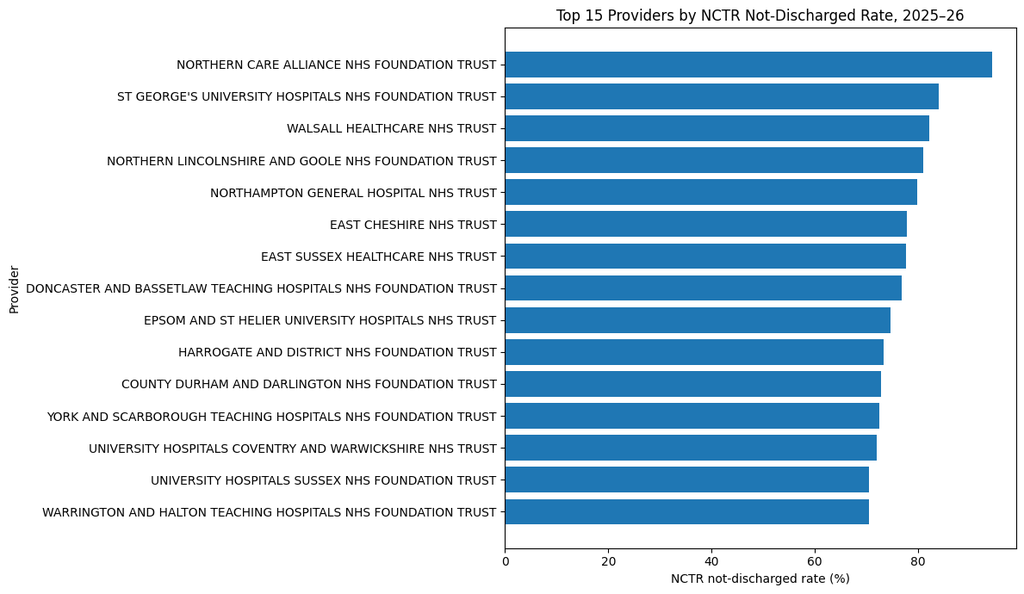

```python
top15_provider_not_discharged = provider_comparison.head(15).copy()

plt.figure(figsize=(12, 7))

plt.barh(
    top15_provider_not_discharged["org_name"],
    top15_provider_not_discharged["nctr_not_discharged_rate"]
)

plt.title("Top 15 Providers by NCTR Not-Discharged Rate, 2025–26")
plt.xlabel("NCTR not-discharged rate (%)")
plt.ylabel("Provider")
plt.gca().invert_yaxis()
plt.tight_layout()

plt.show()
```

```python
provider_comparison.to_csv(
    os.path.join(tables_path, "provider_discharge_delay_summary_2025_26.csv"),
    index=False
)

print("Provider discharge delay summary saved.")
```

```
Provider discharge delay summary saved.
```

### Provider-Level Findings

Provider-level analysis shows substantial variation in discharge-flow pressure across NHS acute providers.

The provider-level threshold excluded one provider with only 30 reporting days. Among included providers, Northern Care Alliance NHS Foundation Trust had the highest NCTR not-discharged rate, followed by St George’s University Hospitals NHS Foundation Trust and Walsall Healthcare NHS Trust.

These findings should be interpreted carefully. A high NCTR not-discharged rate does not necessarily indicate poorer clinical performance; it may reflect case mix, local discharge pathway capacity, social care availability, reporting practices and wider system pressures.

## Additional Bed Days Lost Analysis

Additional bed days lost provide a capacity-impact view of discharge delays.

The dataset includes weekly snapshot metrics for patients with length of stay of 7 days or over, 14 days or over, and 21 days or over. These categories are overlapping rather than mutually exclusive, so they are not summed together for provider ranking.

The main bed-days analysis uses the LOS 7+ metric as the headline measure, while LOS 14+ and LOS 21+ are retained as indicators of longer-stay discharge delay pressure.

```python
additional_bed_days_clean = additional_bed_days.copy()

print("Additional bed days rows:", additional_bed_days_clean.shape[0])

display(additional_bed_days_clean.head())

print("Unique metrics:")
print(additional_bed_days_clean["metric"].unique())
```

```
Additional bed days rows: 26208
```

|  | period | level | region | icb | org_code | org_name | metric | metric_type | metric_group | value | file_month | source_file | period_date | date_status | reporting_month | reporting_quarter | reporting_month_label | data_quality_flag | value_clean |
| --- | --- | --- | --- | --- | --- | --- | --- | --- | --- | --- | --- | --- | --- | --- | --- | --- | --- | --- | --- |
| 15120 | 31/03/2025 | National | [z] | [z] | ENG | ENGLAND (Type 1 Trusts) | Number of additional bed days, patients with length of stay of 7 days or over | Weekly snapshot metric | Additional bed days lost | 126525 | apr_2025 | acute_discharge_sitrep_apr_2025.csv | 2025-03-31 | Previous-month weekly boundary | 2025-04-01 | Q1 | Apr 2025 | Valid weekly boundary row | 126525.0 |
| 15121 | 31/03/2025 | Region | EAST OF ENGLAND | [z] | Y61 | EAST OF ENGLAND | Number of additional bed days, patients with length of stay of 7 days or over | Weekly snapshot metric | Additional bed days lost | 9050 | apr_2025 | acute_discharge_sitrep_apr_2025.csv | 2025-03-31 | Previous-month weekly boundary | 2025-04-01 | Q1 | Apr 2025 | Valid weekly boundary row | 9050.0 |
| 15122 | 31/03/2025 | Region | LONDON | [z] | Y56 | LONDON | Number of additional bed days, patients with length of stay of 7 days or over | Weekly snapshot metric | Additional bed days lost | 20391 | apr_2025 | acute_discharge_sitrep_apr_2025.csv | 2025-03-31 | Previous-month weekly boundary | 2025-04-01 | Q1 | Apr 2025 | Valid weekly boundary row | 20391.0 |
| 15123 | 31/03/2025 | Region | MIDLANDS | [z] | Y60 | MIDLANDS | Number of additional bed days, patients with length of stay of 7 days or over | Weekly snapshot metric | Additional bed days lost | 12602 | apr_2025 | acute_discharge_sitrep_apr_2025.csv | 2025-03-31 | Previous-month weekly boundary | 2025-04-01 | Q1 | Apr 2025 | Valid weekly boundary row | 12602.0 |
| 15124 | 31/03/2025 | Region | NORTH EAST AND YORKSHIRE | [z] | Y63 | NORTH EAST AND YORKSHIRE | Number of additional bed days, patients with length of stay of 7 days or over | Weekly snapshot metric | Additional bed days lost | 17080 | apr_2025 | acute_discharge_sitrep_apr_2025.csv | 2025-03-31 | Previous-month weekly boundary | 2025-04-01 | Q1 | Apr 2025 | Valid weekly boundary row | 17080.0 |

```
Unique metrics:
<StringArray>
[ 'Number of additional bed days, patients with length of stay of 7 days or over',
 'Number of additional bed days, patients with length of stay of 14 days or over',
 'Number of additional bed days, patients with length of stay of 21 days or over']
Length: 3, dtype: str
```

```python
def bed_day_los_category(metric):
    if "7 days or over" in metric:
        return "LOS 7+"
    elif "14 days or over" in metric:
        return "LOS 14+"
    elif "21 days or over" in metric:
        return "LOS 21+"
    else:
        return "Other"

additional_bed_days_clean["los_category"] = additional_bed_days_clean["metric"].apply(bed_day_los_category)

display(
    additional_bed_days_clean[["metric", "los_category"]]
    .drop_duplicates()
    .sort_values("los_category")
)
```

|  | metric | los_category |
| --- | --- | --- |
| 15960 | Number of additional bed days, patients with length of stay of 14 days or over | LOS 14+ |
| 16800 | Number of additional bed days, patients with length of stay of 21 days or over | LOS 21+ |
| 15120 | Number of additional bed days, patients with length of stay of 7 days or over | LOS 7+ |

```python
national_bed_days = additional_bed_days_clean[
    additional_bed_days_clean["level"] == "National"
].copy()

national_bed_days_summary = (
    national_bed_days
    .groupby("los_category", as_index=False)
    .agg(
        total_additional_bed_days=("value_clean", "sum"),
        avg_weekly_additional_bed_days=("value_clean", "mean"),
        max_weekly_additional_bed_days=("value_clean", "max"),
        reporting_points=("period_date", "nunique")
    )
    .sort_values("total_additional_bed_days", ascending=False)
)

display(national_bed_days_summary)
```

|  | los_category | total_additional_bed_days | avg_weekly_additional_bed_days | max_weekly_additional_bed_days | reporting_points |
| --- | --- | --- | --- | --- | --- |
| 2 | LOS 7+ | 6744370.0 | 129699.423077 | 137816.0 | 52 |
| 0 | LOS 14+ | 6238506.0 | 119971.269231 | 127505.0 | 52 |
| 1 | LOS 21+ | 5534650.0 | 106435.576923 | 113621.0 | 52 |

```python
national_bed_days_los7 = national_bed_days[
    national_bed_days["los_category"] == "LOS 7+"
].copy()

national_bed_days_los7_monthly = (
    national_bed_days_los7
    .groupby(["reporting_month", "reporting_month_label", "reporting_quarter"], as_index=False)
    .agg(
        monthly_total_bed_days=("value_clean", "sum"),
        avg_weekly_bed_days=("value_clean", "mean"),
        max_weekly_bed_days=("value_clean", "max"),
        reporting_points=("period_date", "nunique")
    )
    .sort_values("reporting_month")
)

display(national_bed_days_los7_monthly)
```

|  | reporting_month | reporting_month_label | reporting_quarter | monthly_total_bed_days | avg_weekly_bed_days | max_weekly_bed_days | reporting_points |
| --- | --- | --- | --- | --- | --- | --- | --- |
| 0 | 2025-04-01 | Apr 2025 | Q1 | 627316.0 | 125463.20 | 130965.0 | 5 |
| 1 | 2025-05-01 | May 2025 | Q1 | 507701.0 | 126925.25 | 135267.0 | 4 |
| 2 | 2025-06-01 | Jun 2025 | Q1 | 502128.0 | 125532.00 | 129174.0 | 4 |
| 3 | 2025-07-01 | Jul 2025 | Q2 | 631434.0 | 126286.80 | 128446.0 | 5 |
| 4 | 2025-08-01 | Aug 2025 | Q2 | 534963.0 | 133740.75 | 136610.0 | 4 |
| 5 | 2025-09-01 | Sep 2025 | Q2 | 542636.0 | 135659.00 | 136318.0 | 4 |
| 6 | 2025-10-01 | Oct 2025 | Q3 | 668551.0 | 133710.20 | 135220.0 | 5 |
| 7 | 2025-11-01 | Nov 2025 | Q3 | 519229.0 | 129807.25 | 130329.0 | 4 |
| 8 | 2025-12-01 | Dec 2025 | Q3 | 485059.0 | 121264.75 | 125365.0 | 4 |
| 9 | 2026-01-01 | Jan 2026 | Q4 | 647816.0 | 129563.20 | 132295.0 | 5 |
| 10 | 2026-02-01 | Feb 2026 | Q4 | 531146.0 | 132786.50 | 134062.0 | 4 |
| 11 | 2026-03-01 | Mar 2026 | Q4 | 546391.0 | 136597.75 | 137816.0 | 4 |

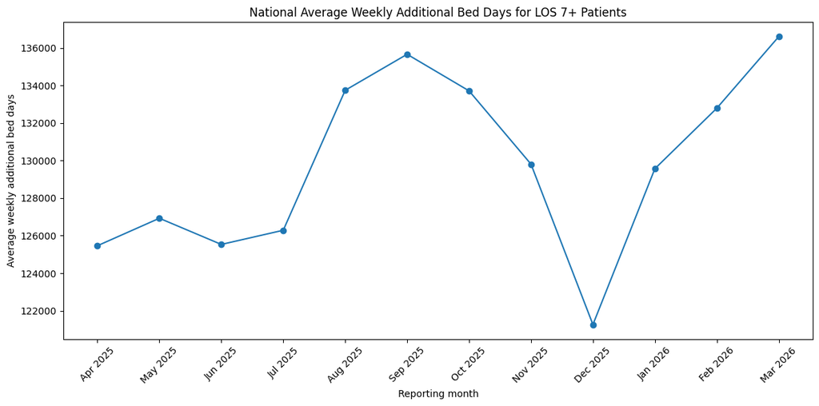

```python
plt.figure(figsize=(12, 6))

plt.plot(
    national_bed_days_los7_monthly["reporting_month_label"],
    national_bed_days_los7_monthly["avg_weekly_bed_days"],
    marker="o"
)

plt.title("National Average Weekly Additional Bed Days for LOS 7+ Patients")
plt.xlabel("Reporting month")
plt.ylabel("Average weekly additional bed days")
plt.xticks(rotation=45)
plt.tight_layout()

plt.show()
```

```python
provider_bed_days_los7 = additional_bed_days_clean[
    (additional_bed_days_clean["level"] == "PROVIDER") &
    (additional_bed_days_clean["los_category"] == "LOS 7+")
].copy()

provider_bed_days_los7_summary = (
    provider_bed_days_los7
    .groupby(["region", "icb", "org_code", "org_name"], as_index=False)
    .agg(
        total_los7_bed_days=("value_clean", "sum"),
        avg_weekly_los7_bed_days=("value_clean", "mean"),
        max_weekly_los7_bed_days=("value_clean", "max"),
        reporting_points=("period_date", "nunique")
    )
    .sort_values("total_los7_bed_days", ascending=False)
)

display(provider_bed_days_los7_summary.head(20))
```

|  | region | icb | org_code | org_name | total_los7_bed_days | avg_weekly_los7_bed_days | max_weekly_los7_bed_days | reporting_points |
| --- | --- | --- | --- | --- | --- | --- | --- | --- |
| 104 | SOUTH EAST | NHS SUSSEX INTEGRATED CARE BOARD | RYR | UNIVERSITY HOSPITALS SUSSEX NHS FOUNDATION TRUST | 313608.0 | 6030.923077 | 7442.0 | 52 |
| 68 | NORTH EAST AND YORKSHIRE | NHS WEST YORKSHIRE INTEGRATED CARE BOARD | RR8 | LEEDS TEACHING HOSPITALS NHS TRUST | 234764.0 | 4514.692308 | 5748.0 | 52 |
| 78 | NORTH WEST | NHS GREATER MANCHESTER INTEGRATED CARE BOARD | R0A | MANCHESTER UNIVERSITY NHS FOUNDATION TRUST | 222596.0 | 4280.692308 | 5979.0 | 52 |
| 74 | NORTH WEST | NHS CHESHIRE AND MERSEYSIDE INTEGRATED CARE BOARD | REM | LIVERPOOL UNIVERSITY HOSPITALS NHS FOUNDATION TRUST | 192067.0 | 3766.019608 | 5564.0 | 52 |
| 79 | NORTH WEST | NHS GREATER MANCHESTER INTEGRATED CARE BOARD | RM3 | NORTHERN CARE ALLIANCE NHS FOUNDATION TRUST | 180168.0 | 3464.769231 | 4493.0 | 52 |
| 24 | LONDON | NHS SOUTH EAST LONDON INTEGRATED CARE BOARD | RJ2 | LEWISHAM AND GREENWICH NHS TRUST | 171558.0 | 3299.192308 | 5362.0 | 52 |
| 115 | SOUTH WEST | NHS DORSET INTEGRATED CARE BOARD | R0D | UNIVERSITY HOSPITALS DORSET NHS FOUNDATION TRUST | 167836.0 | 3227.615385 | 4202.0 | 52 |
| 102 | SOUTH EAST | NHS SUSSEX INTEGRATED CARE BOARD | RTP | SURREY AND SUSSEX HEALTHCARE NHS TRUST | 158540.0 | 3048.846154 | 4655.0 | 52 |
| 108 | SOUTH WEST | NHS BRISTOL, NORTH SOMERSET AND SOUTH GLOUCESTERSHIRE INTEGRATED CARE BOARD | RA7 | UNIVERSITY HOSPITALS BRISTOL AND WESTON NHS FOUNDATION TRUST | 143965.0 | 2768.557692 | 3539.0 | 52 |
| 91 | SOUTH EAST | NHS FRIMLEY INTEGRATED CARE BOARD | RDU | FRIMLEY HEALTH NHS FOUNDATION TRUST | 141351.0 | 2827.020000 | 3769.0 | 52 |
| 13 | LONDON | NHS NORTH CENTRAL LONDON INTEGRATED CARE BOARD | RAL | ROYAL FREE LONDON NHS FOUNDATION TRUST | 139803.0 | 2688.519231 | 3534.0 | 52 |
| 93 | SOUTH EAST | NHS HAMPSHIRE AND ISLE OF WIGHT INTEGRATED CARE BOARD | RHM | UNIVERSITY HOSPITAL SOUTHAMPTON NHS FOUNDATION TRUST | 138108.0 | 2655.923077 | 3389.0 | 52 |
| 30 | MIDLANDS | NHS BIRMINGHAM AND SOLIHULL INTEGRATED CARE BOARD | RRK | UNIVERSITY HOSPITALS BIRMINGHAM NHS FOUNDATION TRUST | 129080.0 | 2482.307692 | 4593.0 | 52 |
| 72 | NORTH WEST | NHS CHESHIRE AND MERSEYSIDE INTEGRATED CARE BOARD | RBN | MERSEY AND WEST LANCASHIRE TEACHING HOSPITALS NHS TRUST | 125274.0 | 2409.115385 | 3240.0 | 52 |
| 22 | LONDON | NHS NORTH WEST LONDON INTEGRATED CARE BOARD | RYJ | IMPERIAL COLLEGE HEALTHCARE NHS TRUST | 122654.0 | 2358.730769 | 3469.0 | 52 |
| 103 | SOUTH EAST | NHS SUSSEX INTEGRATED CARE BOARD | RXC | EAST SUSSEX HEALTHCARE NHS TRUST | 116727.0 | 2244.750000 | 3715.0 | 52 |
| 94 | SOUTH EAST | NHS HAMPSHIRE AND ISLE OF WIGHT INTEGRATED CARE BOARD | RHU | PORTSMOUTH HOSPITALS UNIVERSITY NATIONAL HEALTH SERVICE TRUST | 115949.0 | 2229.788462 | 2989.0 | 52 |
| 81 | NORTH WEST | NHS GREATER MANCHESTER INTEGRATED CARE BOARD | RMP | TAMESIDE AND GLOSSOP INTEGRATED CARE NHS FOUNDATION TRUST | 112621.0 | 2165.788462 | 2627.0 | 52 |
| 109 | SOUTH WEST | NHS BRISTOL, NORTH SOMERSET AND SOUTH GLOUCESTERSHIRE INTEGRATED CARE BOARD | RVJ | NORTH BRISTOL NHS TRUST | 101252.0 | 2025.040000 | 2560.0 | 52 |
| 118 | SOUTH WEST | NHS SOMERSET INTEGRATED CARE BOARD | RH5 | SOMERSET NHS FOUNDATION TRUST | 101181.0 | 1945.788462 | 2500.0 | 52 |

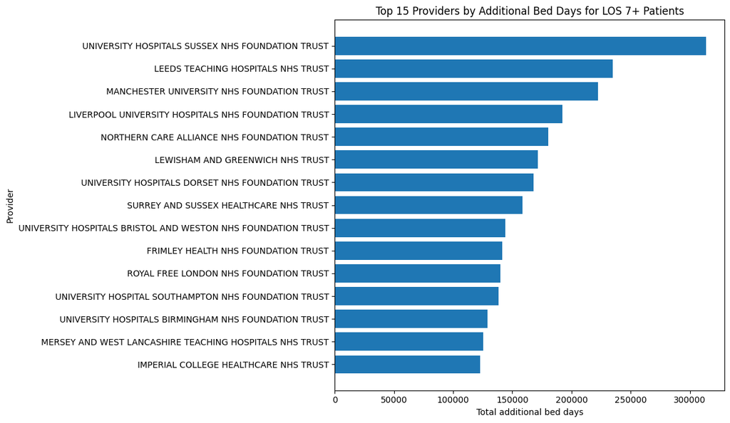

```python
top15_provider_los7_bed_days = provider_bed_days_los7_summary.head(15).copy()

plt.figure(figsize=(12, 7))

plt.barh(
    top15_provider_los7_bed_days["org_name"],
    top15_provider_los7_bed_days["total_los7_bed_days"]
)

plt.title("Top 15 Providers by Additional Bed Days for LOS 7+ Patients")
plt.xlabel("Total additional bed days")
plt.ylabel("Provider")
plt.gca().invert_yaxis()
plt.tight_layout()

plt.show()
```

### Additional Bed Days Findings

At national level, the LOS 7+ metric recorded over 6.7 million additional bed days across 52 weekly reporting points in 2025–26. This suggests that delayed discharge represented a substantial capacity burden across the acute hospital system.

Provider-level additional bed days show the scale of capacity impact linked to delayed discharge. University Hospitals Sussex NHS Foundation Trust recorded the highest LOS 7+ additional bed days total, followed by Leeds Teaching Hospitals NHS Trust and Manchester University NHS Foundation Trust.

This differs from the provider ranking by NCTR not-discharged rate, highlighting the difference between proportional discharge-flow pressure and total bed-day burden.

## Delay Reason Analysis

Delay reason analysis provides insight into why patients with longer lengths of stay remained in hospital after no longer meeting the criteria to reside.

The main analysis focuses on LOS 7+ delay reasons because this provides the broadest view of delayed discharge pressure.

```python
delay_reason_clean = delay_reason.copy()

print("Delay reason rows:", delay_reason_clean.shape)

display(delay_reason_clean.head())

print("Metric groups:")
print(delay_reason_clean["metric_group"].value_counts())

print("\nUnique delay reason metrics:")
display(
    delay_reason_clean["metric"]
    .drop_duplicates()
    .sort_values()
    .reset_index(drop=True)
)
```

```
Delay reason rows: (149184, 19)
```

|  | period | level | region | icb | org_code | org_name | metric | metric_type | metric_group | value | file_month | source_file | period_date | date_status | reporting_month | reporting_quarter | reporting_month_label | data_quality_flag | value_clean |
| --- | --- | --- | --- | --- | --- | --- | --- | --- | --- | --- | --- | --- | --- | --- | --- | --- | --- | --- | --- |
| 18984 | 01/04/2025 | National | [z] | [z] | ENG | ENGLAND (Type 1 Trusts) | Hospital process – Awaiting therapy review of need for supported discharge | Weekly snapshot metric | Delay reason | 506.8 | apr_2025 | acute_discharge_sitrep_apr_2025.csv | 2025-04-01 | Inside expected month | 2025-04-01 | Q1 | Apr 2025 | Valid reporting-month row | 506.8 |
| 18985 | 01/04/2025 | Region | EAST OF ENGLAND | [z] | Y61 | EAST OF ENGLAND | Hospital process – Awaiting therapy review of need for supported discharge | Weekly snapshot metric | Delay reason | 31.6 | apr_2025 | acute_discharge_sitrep_apr_2025.csv | 2025-04-01 | Inside expected month | 2025-04-01 | Q1 | Apr 2025 | Valid reporting-month row | 31.6 |
| 18986 | 01/04/2025 | Region | LONDON | [z] | Y56 | LONDON | Hospital process – Awaiting therapy review of need for supported discharge | Weekly snapshot metric | Delay reason | 109.6 | apr_2025 | acute_discharge_sitrep_apr_2025.csv | 2025-04-01 | Inside expected month | 2025-04-01 | Q1 | Apr 2025 | Valid reporting-month row | 109.6 |
| 18987 | 01/04/2025 | Region | MIDLANDS | [z] | Y60 | MIDLANDS | Hospital process – Awaiting therapy review of need for supported discharge | Weekly snapshot metric | Delay reason | 78.8 | apr_2025 | acute_discharge_sitrep_apr_2025.csv | 2025-04-01 | Inside expected month | 2025-04-01 | Q1 | Apr 2025 | Valid reporting-month row | 78.8 |
| 18988 | 01/04/2025 | Region | NORTH EAST AND YORKSHIRE | [z] | Y63 | NORTH EAST AND YORKSHIRE | Hospital process – Awaiting therapy review of need for supported discharge | Weekly snapshot metric | Delay reason | 49.6 | apr_2025 | acute_discharge_sitrep_apr_2025.csv | 2025-04-01 | Inside expected month | 2025-04-01 | Q1 | Apr 2025 | Valid reporting-month row | 49.6 |

```
Metric groups:
metric_group
Delay reason LOS 7+     74592
Delay reason LOS 14+    49728
Delay reason            24864
Name: count, dtype: int64

Unique delay reason metrics:
```

```
0                                              Capacity – Awaiting restart of existing social care arrangements (Pathway 0)
1                        Capacity – Bed-based rehabilitation, reablement or recovery services not yet available (Pathway 2)
2                                         Capacity – End of life care inc Fast-Track CHC not yet available (Pathway 1 or 3)
3                                              Capacity – Equipment and associated training not yet delivered (Pathway 1-3)
4                       Capacity – Home-based rehabilitation, reablement or recovery services not yet available (Pathway 1)
5                                                         Capacity – Housing adaptations not yet completed (Pathway 1 or 3)
6                                                           Capacity – Housing provision not yet available (Pathway 0 or 1)
7                                              Capacity – Mental health admitted patient care not yet available (Pathway 2)
8                                       Capacity – Other home-based community health services not yet available (Pathway 1)
9                                             Capacity – Other home-based social care service not yet available (Pathway 1)
10                                                   Capacity – Residential/nursing home care not yet available (Pathway 3)
11                                                 Care transfer hub process – Awaiting confirmation of funding eligibility
12                                 Care transfer hub process – Waiting for confirmation of immediate care needs and pathway
13                                             Care transfer hub process– Awaiting necessary referrals by care transfer hub
14                                               Hospital process - Awaiting medical review of need for supported discharge
```

[output cut: 23 more lines]

```python
def standardise_delay_group(metric_group):
    if metric_group == "Delay reason":
        return "LOS 14+"
    elif metric_group == "Delay reason LOS 14+":
        return "LOS 14+"
    elif metric_group == "Delay reason LOS 7+":
        return "LOS 7+"
    else:
        return metric_group

delay_reason_clean["delay_los_group"] = delay_reason_clean["metric_group"].apply(
    standardise_delay_group
)

display(
    delay_reason_clean[["metric_group", "delay_los_group"]]
    .drop_duplicates()
    .sort_values(["metric_group", "delay_los_group"])
)
```

|  | metric_group | delay_los_group |
| --- | --- | --- |
| 18984 | Delay reason | LOS 14+ |
| 144816 | Delay reason LOS 14+ | LOS 14+ |
| 25200 | Delay reason LOS 7+ | LOS 7+ |

```python
national_delay_reasons_los7 = delay_reason_clean[
    (delay_reason_clean["level"] == "National") &
    (delay_reason_clean["delay_los_group"] == "LOS 7+")
].copy()

national_delay_reason_summary_los7 = (
    national_delay_reasons_los7
    .groupby("metric", as_index=False)
    .agg(
        total_value=("value_clean", "sum"),
        avg_monthly_value=("value_clean", "mean"),
        max_monthly_value=("value_clean", "max"),
        reporting_months=("reporting_month", "nunique")
    )
    .sort_values("total_value", ascending=False)
)

display(national_delay_reason_summary_los7.head(15))
```

|  | metric | total_value | avg_monthly_value | max_monthly_value | reporting_months |
| --- | --- | --- | --- | --- | --- |
| 12 | Care transfer hub process – Waiting for confirmation of immediate care needs and pathway | 12996.116667 | 1083.009722 | 1252.000000 | 12 |
| 1 | Capacity – Bed-based rehabilitation, reablement or recovery services not yet available (Pathway 2) | 12119.233333 | 1009.936111 | 1066.500000 | 12 |
| 19 | Hospital process – Awaiting therapy review of need for supported discharge | 9636.433333 | 803.036111 | 934.250000 | 12 |
| 10 | Capacity – Residential/nursing home care not yet available (Pathway 3) | 9375.866667 | 781.322222 | 820.416667 | 12 |
| 25 | Interface process – Residential/nursing home care arrangements still underway (Pathway 3) | 9086.433333 | 757.202778 | 857.500000 | 12 |
| 21 | Interface process – Bed-based rehabilitation, reablement or recovery service arrangements still underway (Pathway 2) | 8877.350000 | 739.779167 | 900.750000 | 12 |
| 4 | Capacity – Home-based rehabilitation, reablement or recovery services not yet available (Pathway 1) | 8114.433333 | 676.202778 | 790.000000 | 12 |
| 24 | Interface process – Other home-based social care service arrangements still underway (Pathway 1) | 6639.516667 | 553.293056 | 623.000000 | 12 |
| 18 | Hospital process – Awaiting referral to care transfer hub for supported discharge | 5898.750000 | 491.562500 | 549.250000 | 12 |
| 22 | Interface process – Home based rehabilitation, reablement or recovery service arrangements still underway (Pathway 1) | 5744.633333 | 478.719444 | 562.250000 | 12 |
| 13 | Care transfer hub process– Awaiting necessary referrals by care transfer hub | 4734.566667 | 394.547222 | 441.100000 | 12 |
| 14 | Hospital process - Awaiting medical review of need for supported discharge | 4506.300000 | 375.525000 | 411.283333 | 12 |
| 16 | Hospital process – Awaiting medicines to take home, discharge letter or other discharge documentation | 4231.766667 | 352.647222 | 421.500000 | 12 |
| 9 | Capacity – Other home-based social care service not yet available (Pathway 1) | 3882.550000 | 323.545833 | 366.250000 | 12 |
| 15 | Hospital process – Awaiting formal decision to discharge (inc diagnostic test results) | 3355.350000 | 279.612500 | 378.333333 | 12 |

```python
def shorten_delay_reason(reason):
    replacements = {
        "Care transfer hub process – Waiting for confirmation of immediate care needs and pathway":
            "CTH: awaiting care needs/pathway confirmation",
        "Capacity – Bed-based rehabilitation, reablement or recovery services not yet available (Pathway 2)":
            "Capacity: bed-based rehab/reablement unavailable",
        "Hospital process – Awaiting therapy review of need for supported discharge":
            "Hospital: awaiting therapy review",
        "Capacity – Residential/nursing home care not yet available (Pathway 3)":
            "Capacity: residential/nursing home unavailable",
        "Interface process – Residential/nursing home care arrangements still underway (Pathway 3)":
            "Interface: residential/nursing home arrangements",
        "Interface process – Bed-based rehabilitation, reablement or recovery service arrangements still underway (Pathway 2)":
            "Interface: bed-based rehab arrangements",
        "Capacity – Home-based rehabilitation, reablement or recovery services not yet available (Pathway 1)":
            "Capacity: home-based rehab/reablement unavailable",
        "Interface process – Other home-based social care service arrangements still underway (Pathway 1)":
            "Interface: home-based social care arrangements",
        "Hospital process – Awaiting referral to care transfer hub for supported discharge":
            "Hospital: awaiting referral to care transfer hub",
        "Interface process – Home based rehabilitation, reablement or recovery service arrangements still underway (Pathway 1)":
            "Interface: home-based rehab arrangements",
        "Care transfer hub process– Awaiting necessary referrals by care transfer hub":
            "CTH: awaiting necessary referrals",
        "Hospital process - Awaiting medical review of need for supported discharge":
            "Hospital: awaiting medical review",
        "Hospital process – Awaiting medicines to take home, discharge letter or other discharge documentation":
            "Hospital: medicines/discharge documentation",
        "Capacity – Other home-based social care service not yet available (Pathway 1)":
            "Capacity: home-based social care unavailable",
        "Hospital process – Awaiting formal decision to discharge (inc diagnostic test results)":
            "Hospital: awaiting formal discharge decision"
    }

    if reason in replacements:
        return replacements[reason]

    # Flexible fallbacks for closely related labels.
    if reason.startswith("Capacity") and "Home-based rehabilitation" in reason:
        return "Capacity: home-based rehab/reablement unavailable"
    if reason.startswith("Hospital process") and "medicines" in reason:
        return "Hospital: medicines/discharge documentation"

    return reason

delay_reason_clean["delay_reason_short"] = delay_reason_clean["metric"].apply(shorten_delay_reason)

national_delay_reason_summary_los7["delay_reason_short"] = (
    national_delay_reason_summary_los7["metric"].apply(shorten_delay_reason)
)

display(
    national_delay_reason_summary_los7[
        ["metric", "delay_reason_short", "total_value"]
    ].head(15)
)
```

|  | metric | delay_reason_short | total_value |
| --- | --- | --- | --- |
| 12 | Care transfer hub process – Waiting for confirmation of immediate care needs and pathway | CTH: awaiting care needs/pathway confirmation | 12996.116667 |
| 1 | Capacity – Bed-based rehabilitation, reablement or recovery services not yet available (Pathway 2) | Capacity: bed-based rehab/reablement unavailable | 12119.233333 |
| 19 | Hospital process – Awaiting therapy review of need for supported discharge | Hospital: awaiting therapy review | 9636.433333 |
| 10 | Capacity – Residential/nursing home care not yet available (Pathway 3) | Capacity: residential/nursing home unavailable | 9375.866667 |
| 25 | Interface process – Residential/nursing home care arrangements still underway (Pathway 3) | Interface: residential/nursing home arrangements | 9086.433333 |
| 21 | Interface process – Bed-based rehabilitation, reablement or recovery service arrangements still underway (Pathway 2) | Interface: bed-based rehab arrangements | 8877.350000 |
| 4 | Capacity – Home-based rehabilitation, reablement or recovery services not yet available (Pathway 1) | Capacity: home-based rehab/reablement unavailable | 8114.433333 |
| 24 | Interface process – Other home-based social care service arrangements still underway (Pathway 1) | Interface: home-based social care arrangements | 6639.516667 |
| 18 | Hospital process – Awaiting referral to care transfer hub for supported discharge | Hospital: awaiting referral to care transfer hub | 5898.750000 |
| 22 | Interface process – Home based rehabilitation, reablement or recovery service arrangements still underway (Pathway 1) | Interface: home-based rehab arrangements | 5744.633333 |
| 13 | Care transfer hub process– Awaiting necessary referrals by care transfer hub | CTH: awaiting necessary referrals | 4734.566667 |
| 14 | Hospital process - Awaiting medical review of need for supported discharge | Hospital: awaiting medical review | 4506.300000 |
| 16 | Hospital process – Awaiting medicines to take home, discharge letter or other discharge documentation | Hospital: medicines/discharge documentation | 4231.766667 |
| 9 | Capacity – Other home-based social care service not yet available (Pathway 1) | Capacity: home-based social care unavailable | 3882.550000 |
| 15 | Hospital process – Awaiting formal decision to discharge (inc diagnostic test results) | Hospital: awaiting formal discharge decision | 3355.350000 |

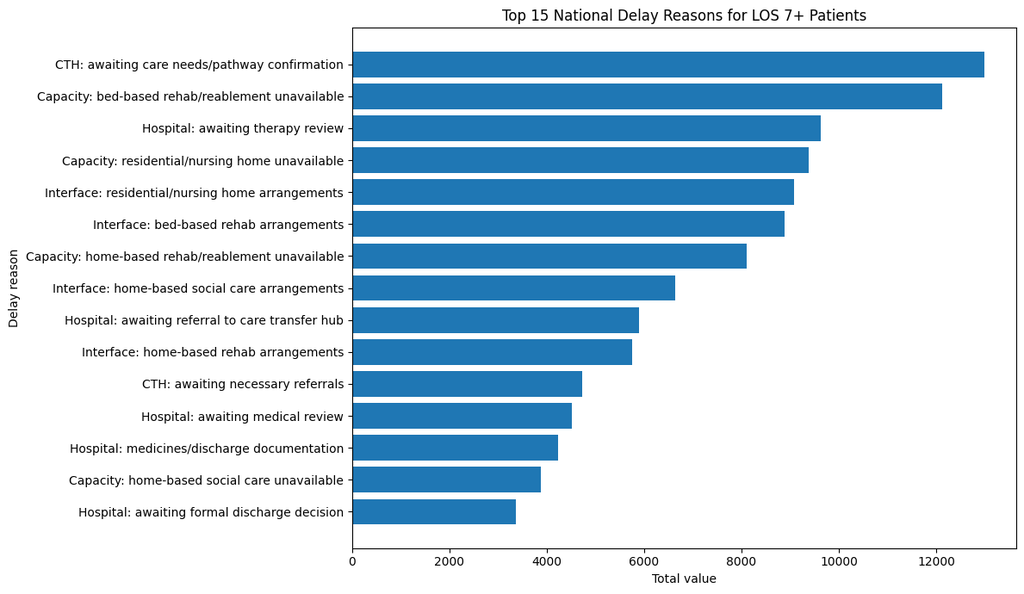

```python
top15_delay_reasons_los7 = national_delay_reason_summary_los7.head(15).copy()

plt.figure(figsize=(12, 7))

plt.barh(
    top15_delay_reasons_los7["delay_reason_short"],
    top15_delay_reasons_los7["total_value"]
)

plt.title("Top 15 National Delay Reasons for LOS 7+ Patients")
plt.xlabel("Total value")
plt.ylabel("Delay reason")
plt.gca().invert_yaxis()
plt.tight_layout()

plt.show()
```

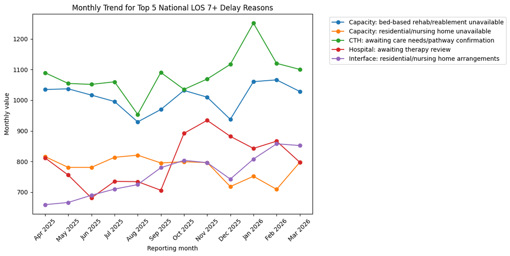

```python
top5_delay_reason_names = national_delay_reason_summary_los7.head(5)["metric"].tolist()

national_delay_reason_monthly_los7 = (
    national_delay_reasons_los7[
        national_delay_reasons_los7["metric"].isin(top5_delay_reason_names)
    ]
    .groupby(["reporting_month", "reporting_month_label", "metric"], as_index=False)
    .agg(monthly_value=("value_clean", "sum"))
    .sort_values(["metric", "reporting_month"])
)

national_delay_reason_monthly_los7["delay_reason_short"] = (
    national_delay_reason_monthly_los7["metric"].apply(shorten_delay_reason)
)

plt.figure(figsize=(12, 6))

for reason in national_delay_reason_monthly_los7["delay_reason_short"].unique():
    temp = national_delay_reason_monthly_los7[
        national_delay_reason_monthly_los7["delay_reason_short"] == reason
    ]

    plt.plot(
        temp["reporting_month_label"],
        temp["monthly_value"],
        marker="o",
        label=reason
    )

plt.title("Monthly Trend for Top 5 National LOS 7+ Delay Reasons")
plt.xlabel("Reporting month")
plt.ylabel("Monthly value")
plt.xticks(rotation=45)
plt.legend(bbox_to_anchor=(1.05, 1), loc="upper left")
plt.tight_layout()

plt.show()
```

```python
def delay_reason_category(reason):
    if reason.startswith("Capacity"):
        return "Capacity"
    elif reason.startswith("Interface process"):
        return "Interface process"
    elif reason.startswith("Hospital process"):
        return "Hospital process"
    elif reason.startswith("Care transfer hub process"):
        return "Care transfer hub process"
    elif reason.startswith("Care transfer hub process–"):
        return "Care transfer hub process"
    elif reason.startswith("Wellbeing concerns"):
        return "Wellbeing concerns"
    else:
        return "Other"

delay_reason_clean["delay_reason_category"] = delay_reason_clean["metric"].apply(delay_reason_category)

national_delay_reasons_los7 = delay_reason_clean[
    (delay_reason_clean["level"] == "National") &
    (delay_reason_clean["delay_los_group"] == "LOS 7+")
].copy()

national_delay_category_summary_los7 = (
    national_delay_reasons_los7
    .groupby("delay_reason_category", as_index=False)
    .agg(
        total_value=("value_clean", "sum"),
        avg_monthly_value=("value_clean", "mean"),
        unique_reasons=("metric", "nunique")
    )
    .sort_values("total_value", ascending=False)
)

display(national_delay_category_summary_los7)
```

|  | delay_reason_category | total_value | avg_monthly_value | unique_reasons |
| --- | --- | --- | --- | --- |
| 0 | Capacity | 44031.516667 | 333.572096 | 11 |
| 3 | Interface process | 31044.200000 | 517.403333 | 5 |
| 2 | Hospital process | 30219.016667 | 359.750198 | 7 |
| 1 | Care transfer hub process | 18741.200000 | 520.588889 | 3 |
| 4 | Other | 9477.983333 | 112.833135 | 7 |
| 5 | Wellbeing concerns | 7619.916667 | 158.748264 | 4 |

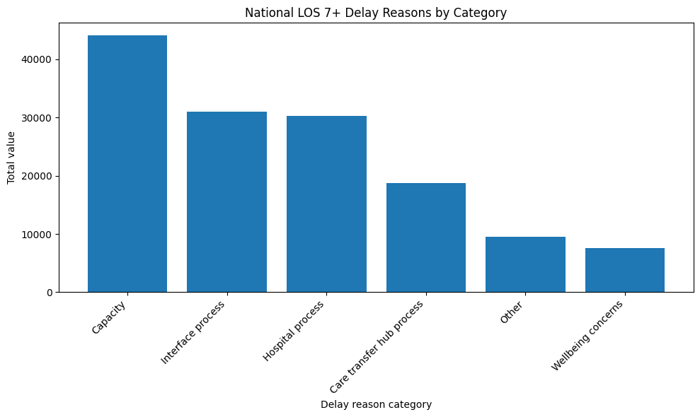

```python
plt.figure(figsize=(10, 6))

plt.bar(
    national_delay_category_summary_los7["delay_reason_category"],
    national_delay_category_summary_los7["total_value"]
)

plt.title("National LOS 7+ Delay Reasons by Category")
plt.xlabel("Delay reason category")
plt.ylabel("Total value")
plt.xticks(rotation=45, ha="right")
plt.tight_layout()

plt.show()
```

```python
national_delay_reasons_los14 = delay_reason_clean[
    (delay_reason_clean["level"] == "National") &
    (delay_reason_clean["delay_los_group"] == "LOS 14+")
].copy()

national_delay_reason_summary_los14 = (
    national_delay_reasons_los14
    .groupby("metric", as_index=False)
    .agg(
        total_value=("value_clean", "sum"),
        avg_monthly_value=("value_clean", "mean"),
        max_monthly_value=("value_clean", "max"),
        reporting_months=("reporting_month", "nunique")
    )
    .sort_values("total_value", ascending=False)
)

national_delay_reason_summary_los14["delay_reason_short"] = (
    national_delay_reason_summary_los14["metric"].apply(shorten_delay_reason)
)

display(
    national_delay_reason_summary_los14[
        ["delay_reason_short", "total_value", "avg_monthly_value", "reporting_months"]
    ].head(15)
)
```

|  | delay_reason_short | total_value | avg_monthly_value | reporting_months |
| --- | --- | --- | --- | --- |
| 1 | Capacity: bed-based rehab/reablement unavailable | 9548.70 | 795.725000 | 12 |
| 12 | CTH: awaiting care needs/pathway confirmation | 8832.90 | 736.075000 | 12 |
| 10 | Capacity: residential/nursing home unavailable | 8338.55 | 694.879167 | 12 |
| 25 | Interface: residential/nursing home arrangements | 7950.45 | 662.537500 | 12 |
| 21 | Interface: bed-based rehab arrangements | 6737.95 | 561.495833 | 12 |
| 19 | Hospital: awaiting therapy review | 5936.35 | 494.695833 | 12 |
| 4 | Capacity: home-based rehab/reablement unavailable | 5333.85 | 444.487500 | 12 |
| 24 | Interface: home-based social care arrangements | 4949.25 | 412.437500 | 12 |
| 18 | Hospital: awaiting referral to care transfer hub | 3884.10 | 323.675000 | 12 |
| 22 | Interface: home-based rehab arrangements | 3812.50 | 317.708333 | 12 |
| 13 | CTH: awaiting necessary referrals | 3438.85 | 286.570833 | 12 |
| 14 | Hospital: awaiting medical review | 2982.40 | 248.533333 | 12 |
| 9 | Capacity: home-based social care unavailable | 2892.15 | 241.012500 | 12 |
| 16 | Hospital: medicines/discharge documentation | 2526.90 | 210.575000 | 12 |
| 3 | Capacity – Equipment and associated training not yet delivered (Pathway 1-3) | 2246.95 | 187.245833 | 12 |

```python
national_delay_category_summary_los14 = (
    national_delay_reasons_los14
    .groupby("delay_reason_category", as_index=False)
    .agg(
        total_value=("value_clean", "sum"),
        avg_monthly_value=("value_clean", "mean"),
        unique_reasons=("metric", "nunique")
    )
    .sort_values("total_value", ascending=False)
)

display(national_delay_category_summary_los14)
```

|  | delay_reason_category | total_value | avg_monthly_value | unique_reasons |
| --- | --- | --- | --- | --- |
| 0 | Capacity | 33957.90 | 257.256818 | 11 |
| 3 | Interface process | 23973.30 | 399.555000 | 5 |
| 2 | Hospital process | 19125.35 | 227.682738 | 7 |
| 1 | Care transfer hub process | 13129.60 | 364.711111 | 3 |
| 4 | Other | 7481.05 | 89.060119 | 7 |
| 5 | Wellbeing concerns | 5819.60 | 121.241667 | 4 |

### Delay Reason Findings

The top national LOS 7+ delay reasons included care transfer hub processes, limited availability of bed-based rehabilitation or reablement services, therapy review delays, and residential or nursing home care capacity.

Delay reason categories show that capacity-related reasons accounted for the largest share of LOS 7+ delayed discharge reasons nationally. The largest category was Capacity, followed by Interface process and Hospital process.

This suggests that acute discharge delays were shaped by a combination of onward-care capacity constraints, coordination across the hospital-community interface and internal hospital processes. It also shows that discharge delays are not only an acute hospital issue; they reflect wider system pressures across rehabilitation, reablement, residential and nursing home care, community services and care transfer processes.

### LOS 14+ Delay Reason Check

A supporting check was completed for LOS 14+ delay reasons to understand whether longer-stay patients showed a different pattern.

The LOS 14+ results showed a similar structure to the LOS 7+ analysis. Capacity-related reasons remained the largest category, followed by interface processes, hospital processes and care transfer hub processes.

This suggests that longer-stay discharge delays were also strongly linked to onward-care capacity, rehabilitation and reablement availability, residential or nursing home capacity, and coordination across the hospital-community interface.

## Discharge Destination Analysis

Discharge destination analysis shows where patients were discharged after no longer meeting the criteria to reside.

```python
discharge_destination_clean = discharge_destination.copy()

print("Discharge destination rows:", discharge_destination_clean.shape)

display(discharge_destination_clean.head())

print("Unique discharge destination metrics:")
display(
    discharge_destination_clean["metric"]
    .drop_duplicates()
    .sort_values()
    .reset_index(drop=True)
)
```

```
Discharge destination rows: (16128, 19)
```

|  | period | level | region | icb | org_code | org_name | metric | metric_type | metric_group | value | file_month | source_file | period_date | date_status | reporting_month | reporting_quarter | reporting_month_label | data_quality_flag | value_clean |
| --- | --- | --- | --- | --- | --- | --- | --- | --- | --- | --- | --- | --- | --- | --- | --- | --- | --- | --- | --- |
| 17640 | 01/04/2025 | National | [z] | [z] | ENG | ENGLAND (Type 1 Trusts) | Pathway 0: Discharge to a domestic home, hotel, or other temporary accommodation without the need for new/increased ... | Daily metric | Discharge destination | 244247 | apr_2025 | acute_discharge_sitrep_apr_2025.csv | 2025-04-01 | Inside expected month | 2025-04-01 | Q1 | Apr 2025 | Valid reporting-month row | 244247.0 |
| 17641 | 01/04/2025 | Region | EAST OF ENGLAND | [z] | Y61 | EAST OF ENGLAND | Pathway 0: Discharge to a domestic home, hotel, or other temporary accommodation without the need for new/increased ... | Daily metric | Discharge destination | 30659 | apr_2025 | acute_discharge_sitrep_apr_2025.csv | 2025-04-01 | Inside expected month | 2025-04-01 | Q1 | Apr 2025 | Valid reporting-month row | 30659.0 |
| 17642 | 01/04/2025 | Region | LONDON | [z] | Y56 | LONDON | Pathway 0: Discharge to a domestic home, hotel, or other temporary accommodation without the need for new/increased ... | Daily metric | Discharge destination | 33639 | apr_2025 | acute_discharge_sitrep_apr_2025.csv | 2025-04-01 | Inside expected month | 2025-04-01 | Q1 | Apr 2025 | Valid reporting-month row | 33639.0 |
| 17643 | 01/04/2025 | Region | MIDLANDS | [z] | Y60 | MIDLANDS | Pathway 0: Discharge to a domestic home, hotel, or other temporary accommodation without the need for new/increased ... | Daily metric | Discharge destination | 43872 | apr_2025 | acute_discharge_sitrep_apr_2025.csv | 2025-04-01 | Inside expected month | 2025-04-01 | Q1 | Apr 2025 | Valid reporting-month row | 43872.0 |
| 17644 | 01/04/2025 | Region | NORTH EAST AND YORKSHIRE | [z] | Y63 | NORTH EAST AND YORKSHIRE | Pathway 0: Discharge to a domestic home, hotel, or other temporary accommodation without the need for new/increased ... | Daily metric | Discharge destination | 42721 | apr_2025 | acute_discharge_sitrep_apr_2025.csv | 2025-04-01 | Inside expected month | 2025-04-01 | Q1 | Apr 2025 | Valid reporting-month row | 42721.0 |

```
Unique discharge destination metrics:
```

```
0    Pathway 0: Discharge back to an original care home placement when the care home has confirmed they can continue to m...
1    Pathway 0: Discharge to a domestic home, hotel, or other temporary accommodation without the need for new/increased ...
2    Pathway 1: Discharge back to original care home placement with rehabilitation, reablement and recovery or with an in...
3    Pathway 1: Discharge to a domestic home, hotel, or other temporary accommodation, or hospice at home with other new/...
4    Pathway 1: Discharge to a domestic home, hotel, or other temporary accommodation, or hospice at home with rehabilita...
5                           Pathway 2: Short-term bed/hospice for rehabilitation, reablement and recovery / end of life care
6                                                                     Pathway 3: Discharge to a care home as a new admission
7                                        Pathway 3: Discharge to a care home/hospice as a new admission for end-of-life care
Name: metric, dtype: str
```

```python
national_discharge_destination = discharge_destination_clean[
    discharge_destination_clean["level"] == "National"
].copy()

national_discharge_destination_summary = (
    national_discharge_destination
    .groupby("metric", as_index=False)
    .agg(
        total_value=("value_clean", "sum"),
        avg_monthly_value=("value_clean", "mean"),
        max_monthly_value=("value_clean", "max"),
        reporting_months=("reporting_month", "nunique")
    )
    .sort_values("total_value", ascending=False)
)

display(national_discharge_destination_summary)
```

|  | metric | total_value | avg_monthly_value | max_monthly_value | reporting_months |
| --- | --- | --- | --- | --- | --- |
| 1 | Pathway 0: Discharge to a domestic home, hotel, or other temporary accommodation without the need for new/increased ... | 2963125.0 | 246927.083333 | 265596.0 | 12 |
| 4 | Pathway 1: Discharge to a domestic home, hotel, or other temporary accommodation, or hospice at home with rehabilita... | 258059.0 | 21504.916667 | 24112.0 | 12 |
| 5 | Pathway 2: Short-term bed/hospice for rehabilitation, reablement and recovery / end of life care | 114157.0 | 9513.083333 | 10625.0 | 12 |
| 3 | Pathway 1: Discharge to a domestic home, hotel, or other temporary accommodation, or hospice at home with other new/... | 73622.0 | 6135.166667 | 6718.0 | 12 |
| 0 | Pathway 0: Discharge back to an original care home placement when the care home has confirmed they can continue to m... | 67504.0 | 5625.333333 | 6103.0 | 12 |
| 6 | Pathway 3: Discharge to a care home as a new admission | 44435.0 | 3702.916667 | 4141.0 | 12 |
| 2 | Pathway 1: Discharge back to original care home placement with rehabilitation, reablement and recovery or with an in... | 20046.0 | 1670.500000 | 2177.0 | 12 |
| 7 | Pathway 3: Discharge to a care home/hospice as a new admission for end-of-life care | 17063.0 | 1421.916667 | 1613.0 | 12 |

```python
def shorten_discharge_destination(destination):
    if destination.startswith("Pathway 0: Discharge to a domestic home"):
        return "P0: home/temp accommodation, no new support"
    elif destination.startswith("Pathway 0: Discharge back to an original care home"):
        return "P0: return to original care home"
    elif destination.startswith("Pathway 1: Discharge to a domestic home") and "rehabilita" in destination:
        return "P1: home with rehab/reablement"
    elif destination.startswith("Pathway 1: Discharge to a domestic home"):
        return "P1: home with other new support"
    elif destination.startswith("Pathway 1: Discharge back to original care home"):
        return "P1: original care home with support"
    elif destination.startswith("Pathway 2"):
        return "P2: short-term bed/hospice"
    elif destination.startswith("Pathway 3: Discharge to a care home as a new admission"):
        return "P3: new care home admission"
    elif destination.startswith("Pathway 3: Discharge to a care home/hospice"):
        return "P3: care home/hospice EOL admission"
    else:
        return destination

discharge_destination_clean["destination_short"] = (
    discharge_destination_clean["metric"].apply(shorten_discharge_destination)
)

national_discharge_destination_summary["destination_short"] = (
    national_discharge_destination_summary["metric"].apply(shorten_discharge_destination)
)

display(
    national_discharge_destination_summary[
        ["metric", "destination_short", "total_value"]
    ]
)
```

|  | metric | destination_short | total_value |
| --- | --- | --- | --- |
| 1 | Pathway 0: Discharge to a domestic home, hotel, or other temporary accommodation without the need for new/increased ... | P0: home/temp accommodation, no new support | 2963125.0 |
| 4 | Pathway 1: Discharge to a domestic home, hotel, or other temporary accommodation, or hospice at home with rehabilita... | P1: home with rehab/reablement | 258059.0 |
| 5 | Pathway 2: Short-term bed/hospice for rehabilitation, reablement and recovery / end of life care | P2: short-term bed/hospice | 114157.0 |
| 3 | Pathway 1: Discharge to a domestic home, hotel, or other temporary accommodation, or hospice at home with other new/... | P1: home with other new support | 73622.0 |
| 0 | Pathway 0: Discharge back to an original care home placement when the care home has confirmed they can continue to m... | P0: return to original care home | 67504.0 |
| 6 | Pathway 3: Discharge to a care home as a new admission | P3: new care home admission | 44435.0 |
| 2 | Pathway 1: Discharge back to original care home placement with rehabilitation, reablement and recovery or with an in... | P1: original care home with support | 20046.0 |
| 7 | Pathway 3: Discharge to a care home/hospice as a new admission for end-of-life care | P3: care home/hospice EOL admission | 17063.0 |

```python
national_discharge_destination_summary["destination_share_pct"] = (
    national_discharge_destination_summary["total_value"] /
    national_discharge_destination_summary["total_value"].sum() * 100
)

display(
    national_discharge_destination_summary[
        ["destination_short", "total_value", "destination_share_pct"]
    ].sort_values("total_value", ascending=False)
)
```

|  | destination_short | total_value | destination_share_pct |
| --- | --- | --- | --- |
| 1 | P0: home/temp accommodation, no new support | 2963125.0 | 83.280378 |
| 4 | P1: home with rehab/reablement | 258059.0 | 7.252901 |
| 5 | P2: short-term bed/hospice | 114157.0 | 3.208450 |
| 3 | P1: home with other new support | 73622.0 | 2.069190 |
| 0 | P0: return to original care home | 67504.0 | 1.897240 |
| 6 | P3: new care home admission | 44435.0 | 1.248872 |
| 2 | P1: original care home with support | 20046.0 | 0.563405 |
| 7 | P3: care home/hospice EOL admission | 17063.0 | 0.479566 |

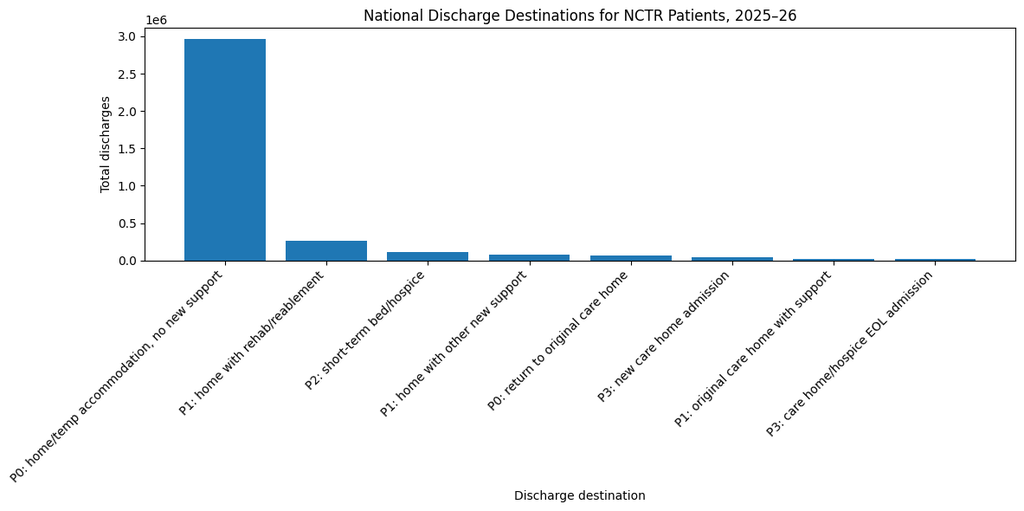

```python
plt.figure(figsize=(12, 6))

plt.bar(
    national_discharge_destination_summary["destination_short"],
    national_discharge_destination_summary["total_value"]
)

plt.title("National Discharge Destinations for NCTR Patients, 2025–26")
plt.xlabel("Discharge destination")
plt.ylabel("Total discharges")
plt.xticks(rotation=45, ha="right")
plt.tight_layout()

plt.show()
```

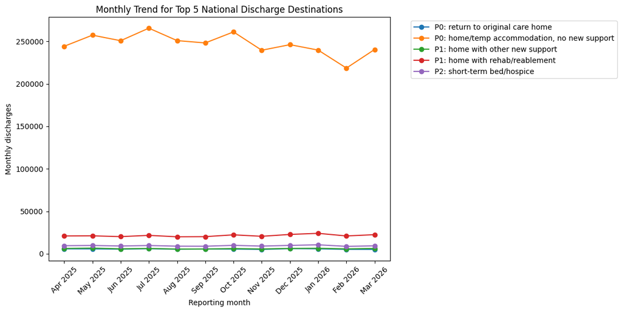

```python
top5_destination_names = (
    national_discharge_destination_summary
    .head(5)["metric"]
    .tolist()
)

national_destination_monthly = (
    national_discharge_destination[
        national_discharge_destination["metric"].isin(top5_destination_names)
    ]
    .groupby(["reporting_month", "reporting_month_label", "metric"], as_index=False)
    .agg(monthly_value=("value_clean", "sum"))
    .sort_values(["metric", "reporting_month"])
)

national_destination_monthly["destination_short"] = (
    national_destination_monthly["metric"].apply(shorten_discharge_destination)
)

plt.figure(figsize=(12, 6))

for destination in national_destination_monthly["destination_short"].unique():
    temp = national_destination_monthly[
        national_destination_monthly["destination_short"] == destination
    ]

    plt.plot(
        temp["reporting_month_label"],
        temp["monthly_value"],
        marker="o",
        label=destination
    )

plt.title("Monthly Trend for Top 5 National Discharge Destinations")
plt.xlabel("Reporting month")
plt.ylabel("Monthly discharges")
plt.xticks(rotation=45)
plt.legend(bbox_to_anchor=(1.05, 1), loc="upper left")
plt.tight_layout()

plt.show()
```

### Discharge Destination Findings

Across 2025–26, the largest discharge destination category was Pathway 0: discharge to a domestic home, hotel or other temporary accommodation without the need for new or increased support. This accounted for 83.3% of recorded discharge destinations nationally.

More complex discharge pathways, including Pathway 1, Pathway 2 and Pathway 3, accounted for a much smaller share of recorded discharge destinations.

This suggests that most recorded discharges occurred through the least complex discharge route, while a smaller proportion required rehabilitation, reablement, short-term bed-based care, care home admission or end-of-life care pathways.

## Exporting Clean Analytical Outputs

The main cleaned analytical summaries are exported to the `outputs/tables` folder for documentation, GitHub and future reuse.

```python
# National outputs
national_monthly_summary.to_csv(
    os.path.join(tables_path, "national_monthly_discharge_flow_summary_2025_26.csv"),
    index=False
)

national_quarterly_summary.to_csv(
    os.path.join(tables_path, "national_quarterly_discharge_flow_summary_2025_26.csv"),
    index=False
)

# Regional and ICB outputs
regional_year_summary.to_csv(
    os.path.join(tables_path, "regional_discharge_delay_summary_2025_26.csv"),
    index=False
)

regional_q4_summary.to_csv(
    os.path.join(tables_path, "regional_q4_discharge_delay_summary_2025_26.csv"),
    index=False
)

icb_year_summary.to_csv(
    os.path.join(tables_path, "icb_discharge_delay_summary_2025_26.csv"),
    index=False
)

# Provider outputs
provider_comparison.to_csv(
    os.path.join(tables_path, "provider_discharge_delay_summary_2025_26.csv"),
    index=False
)

provider_bed_days_los7_summary.to_csv(
    os.path.join(tables_path, "provider_los7_additional_bed_days_summary_2025_26.csv"),
    index=False
)

# Additional bed days outputs
national_bed_days_summary.to_csv(
    os.path.join(tables_path, "national_additional_bed_days_summary_2025_26.csv"),
    index=False
)

national_bed_days_los7_monthly.to_csv(
    os.path.join(tables_path, "national_los7_additional_bed_days_monthly_2025_26.csv"),
    index=False
)

# Delay reason outputs
national_delay_reason_summary_los7.to_csv(
    os.path.join(tables_path, "national_los7_delay_reason_summary_2025_26.csv"),
    index=False
)

national_delay_category_summary_los7.to_csv(
    os.path.join(tables_path, "national_los7_delay_reason_category_summary_2025_26.csv"),
    index=False
)

# Discharge destination outputs
national_discharge_destination_summary.to_csv(
    os.path.join(tables_path, "national_discharge_destination_summary_2025_26.csv"),
    index=False
)

print("Main analysis outputs saved to:", tables_path)
```

```
Main analysis outputs saved to: C:\Users\raahu\OneDrive\Desktop\nhs-discharge-delays-sitrep-analysis\outputs\tables
```

```python
saved_tables = sorted(os.listdir(tables_path))

print("Saved table files:")
for file in saved_tables:
    print(file)
```

```
Saved table files:
icb_discharge_delay_summary_2025_26.csv
national_additional_bed_days_summary_2025_26.csv
national_discharge_destination_summary_2025_26.csv
national_los7_additional_bed_days_monthly_2025_26.csv
national_los7_delay_reason_category_summary_2025_26.csv
national_los7_delay_reason_summary_2025_26.csv
national_monthly_discharge_flow_summary_2025_26.csv
national_quarterly_discharge_flow_summary_2025_26.csv
provider_discharge_delay_summary_2025_26.csv
provider_los7_additional_bed_days_summary_2025_26.csv
regional_discharge_delay_summary_2025_26.csv
regional_q4_discharge_delay_summary_2025_26.csv
```

## Tableau Dashboard Preparation

The Tableau-ready outputs below are simplified CSV files designed for dashboard development. These outputs support national KPIs, geographic comparisons, provider rankings, bed-day burden, delay reasons and discharge destinations.

```python
tableau_national_kpis = national_monthly_summary.copy()

tableau_national_kpis = tableau_national_kpis[
    [
        "reporting_month",
        "reporting_month_label",
        "reporting_quarter",
        "avg_daily_nctr",
        "avg_daily_discharged",
        "avg_daily_not_discharged",
        "total_nctr",
        "total_discharged",
        "total_not_discharged",
        "nctr_not_discharged_rate",
        "nctr_discharged_rate"
    ]
].copy()

tableau_national_kpis.to_csv(
    os.path.join(tableau_path, "tableau_national_discharge_kpis_2025_26.csv"),
    index=False
)

display(tableau_national_kpis)
```

|  | reporting_month | reporting_month_label | reporting_quarter | avg_daily_nctr | avg_daily_discharged | avg_daily_not_discharged | total_nctr | total_discharged | total_not_discharged | nctr_not_discharged_rate | nctr_discharged_rate |
| --- | --- | --- | --- | --- | --- | --- | --- | --- | --- | --- | --- |
| 0 | 2025-04-01 | Apr 2025 | Q1 | 22541.633333 | 9801.433333 | 12740.200000 | 676249.0 | 294043.0 | 382206.0 | 56.518531 | 43.481469 |
| 1 | 2025-05-01 | May 2025 | Q1 | 22602.935484 | 9930.741935 | 12672.193548 | 700691.0 | 307853.0 | 392838.0 | 56.064371 | 43.935629 |
| 2 | 2025-06-01 | Jun 2025 | Q1 | 22004.333333 | 9933.066667 | 12071.266667 | 660130.0 | 297992.0 | 362138.0 | 54.858588 | 45.141412 |
| 3 | 2025-07-01 | Jul 2025 | Q2 | 22757.677419 | 10205.225806 | 12552.451613 | 705488.0 | 316362.0 | 389126.0 | 55.156998 | 44.843002 |
| 4 | 2025-08-01 | Aug 2025 | Q2 | 22129.451613 | 9594.225806 | 12535.225806 | 686013.0 | 297421.0 | 388592.0 | 56.644991 | 43.355009 |
| 5 | 2025-09-01 | Sep 2025 | Q2 | 22653.866667 | 9839.133333 | 12814.733333 | 679616.0 | 295174.0 | 384442.0 | 56.567532 | 43.432468 |
| 6 | 2025-10-01 | Oct 2025 | Q3 | 23200.516129 | 10083.580645 | 13116.935484 | 719216.0 | 312591.0 | 406625.0 | 56.537257 | 43.462743 |
| 7 | 2025-11-01 | Nov 2025 | Q3 | 22732.200000 | 9552.866667 | 13179.333333 | 681966.0 | 286586.0 | 395380.0 | 57.976497 | 42.023503 |
| 8 | 2025-12-01 | Dec 2025 | Q3 | 22470.806452 | 9632.516129 | 12838.290323 | 696595.0 | 298608.0 | 397987.0 | 57.133198 | 42.866802 |
| 9 | 2026-01-01 | Jan 2026 | Q4 | 23318.451613 | 9495.580645 | 13822.870968 | 722872.0 | 294363.0 | 428509.0 | 59.278683 | 40.721317 |
| 10 | 2026-02-01 | Feb 2026 | Q4 | 23392.678571 | 9504.678571 | 13888.000000 | 654995.0 | 266131.0 | 388864.0 | 59.369003 | 40.630997 |
| 11 | 2026-03-01 | Mar 2026 | Q4 | 22937.258065 | 9383.451613 | 13553.806452 | 711055.0 | 290887.0 | 420168.0 | 59.090788 | 40.909212 |

```python
# Region level
tableau_region = regional_year_summary.copy()
tableau_region["geography_level"] = "Region"
tableau_region["geography_name"] = tableau_region["region"]
tableau_region["parent_region"] = tableau_region["region"]
tableau_region["parent_icb"] = np.nan

tableau_region = tableau_region[
    [
        "geography_level",
        "geography_name",
        "parent_region",
        "parent_icb",
        "avg_daily_nctr",
        "avg_daily_discharged",
        "avg_daily_not_discharged",
        "total_nctr",
        "total_discharged",
        "total_not_discharged",
        "nctr_not_discharged_rate",
        "nctr_discharged_rate"
    ]
]

# ICB level
tableau_icb = icb_year_summary.copy()
tableau_icb["geography_level"] = "ICB"
tableau_icb["geography_name"] = tableau_icb["org_name"]
tableau_icb["parent_region"] = tableau_icb["region"]
tableau_icb["parent_icb"] = tableau_icb["icb"]

tableau_icb = tableau_icb[
    [
        "geography_level",
        "geography_name",
        "parent_region",
        "parent_icb",
        "avg_daily_nctr",
        "avg_daily_discharged",
        "avg_daily_not_discharged",
        "total_nctr",
        "total_discharged",
        "total_not_discharged",
        "nctr_not_discharged_rate",
        "nctr_discharged_rate"
    ]
]

# Provider level
tableau_provider = provider_comparison.copy()
tableau_provider["geography_level"] = "Provider"
tableau_provider["geography_name"] = tableau_provider["org_name"]
tableau_provider["parent_region"] = tableau_provider["region"]
tableau_provider["parent_icb"] = tableau_provider["icb"]

tableau_provider = tableau_provider[
    [
        "geography_level",
        "geography_name",
        "parent_region",
        "parent_icb",
        "avg_daily_nctr",
        "avg_daily_discharged",
        "avg_daily_not_discharged",
        "total_nctr",
        "total_discharged",
        "total_not_discharged",
        "nctr_not_discharged_rate",
        "nctr_discharged_rate"
    ]
]

tableau_geography_summary = pd.concat(
    [tableau_region, tableau_icb, tableau_provider],
    ignore_index=True
)

tableau_geography_summary.to_csv(
    os.path.join(tableau_path, "tableau_geography_discharge_summary_2025_26.csv"),
    index=False
)

display(tableau_geography_summary.head())
print("Rows:", tableau_geography_summary.shape[0])
```

|  | geography_level | geography_name | parent_region | parent_icb | avg_daily_nctr | avg_daily_discharged | avg_daily_not_discharged | total_nctr | total_discharged | total_not_discharged | nctr_not_discharged_rate | nctr_discharged_rate |
| --- | --- | --- | --- | --- | --- | --- | --- | --- | --- | --- | --- | --- |
| 0 | Region | SOUTH EAST | SOUTH EAST | NaN | 3604.444579 | 1337.016231 | 2267.428347 | 1316193.0 | 488324.0 | 827869.0 | 62.898754 | 37.101246 |
| 1 | Region | NORTH WEST | NORTH WEST | NaN | 3563.807079 | 1368.032380 | 2195.774699 | 1300349.0 | 499098.0 | 801251.0 | 61.618150 | 38.381850 |
| 2 | Region | SOUTH WEST | SOUTH WEST | NaN | 2730.724136 | 1146.399379 | 1584.324757 | 996596.0 | 418584.0 | 578012.0 | 57.998627 | 42.001373 |
| 3 | Region | LONDON | LONDON | NaN | 2983.910740 | 1270.699315 | 1713.211425 | 1088734.0 | 463799.0 | 624935.0 | 57.400155 | 42.599845 |
| 4 | Region | NORTH EAST AND YORKSHIRE | NORTH EAST AND YORKSHIRE | NaN | 3727.615156 | 1602.241731 | 2125.373425 | 1360315.0 | 584989.0 | 775326.0 | 56.996063 | 43.003937 |

```
Rows: 167
```

```python
tableau_bed_days = national_bed_days_los7_monthly.copy()

tableau_bed_days.to_csv(
    os.path.join(tableau_path, "tableau_national_los7_bed_days_monthly_2025_26.csv"),
    index=False
)

tableau_provider_bed_days = provider_bed_days_los7_summary.copy()

tableau_provider_bed_days.to_csv(
    os.path.join(tableau_path, "tableau_provider_los7_bed_days_2025_26.csv"),
    index=False
)

display(tableau_bed_days)
display(tableau_provider_bed_days.head())
```

|  | reporting_month | reporting_month_label | reporting_quarter | monthly_total_bed_days | avg_weekly_bed_days | max_weekly_bed_days | reporting_points |
| --- | --- | --- | --- | --- | --- | --- | --- |
| 0 | 2025-04-01 | Apr 2025 | Q1 | 627316.0 | 125463.20 | 130965.0 | 5 |
| 1 | 2025-05-01 | May 2025 | Q1 | 507701.0 | 126925.25 | 135267.0 | 4 |
| 2 | 2025-06-01 | Jun 2025 | Q1 | 502128.0 | 125532.00 | 129174.0 | 4 |
| 3 | 2025-07-01 | Jul 2025 | Q2 | 631434.0 | 126286.80 | 128446.0 | 5 |
| 4 | 2025-08-01 | Aug 2025 | Q2 | 534963.0 | 133740.75 | 136610.0 | 4 |
| 5 | 2025-09-01 | Sep 2025 | Q2 | 542636.0 | 135659.00 | 136318.0 | 4 |
| 6 | 2025-10-01 | Oct 2025 | Q3 | 668551.0 | 133710.20 | 135220.0 | 5 |
| 7 | 2025-11-01 | Nov 2025 | Q3 | 519229.0 | 129807.25 | 130329.0 | 4 |
| 8 | 2025-12-01 | Dec 2025 | Q3 | 485059.0 | 121264.75 | 125365.0 | 4 |
| 9 | 2026-01-01 | Jan 2026 | Q4 | 647816.0 | 129563.20 | 132295.0 | 5 |
| 10 | 2026-02-01 | Feb 2026 | Q4 | 531146.0 | 132786.50 | 134062.0 | 4 |
| 11 | 2026-03-01 | Mar 2026 | Q4 | 546391.0 | 136597.75 | 137816.0 | 4 |

|  | region | icb | org_code | org_name | total_los7_bed_days | avg_weekly_los7_bed_days | max_weekly_los7_bed_days | reporting_points |
| --- | --- | --- | --- | --- | --- | --- | --- | --- |
| 104 | SOUTH EAST | NHS SUSSEX INTEGRATED CARE BOARD | RYR | UNIVERSITY HOSPITALS SUSSEX NHS FOUNDATION TRUST | 313608.0 | 6030.923077 | 7442.0 | 52 |
| 68 | NORTH EAST AND YORKSHIRE | NHS WEST YORKSHIRE INTEGRATED CARE BOARD | RR8 | LEEDS TEACHING HOSPITALS NHS TRUST | 234764.0 | 4514.692308 | 5748.0 | 52 |
| 78 | NORTH WEST | NHS GREATER MANCHESTER INTEGRATED CARE BOARD | R0A | MANCHESTER UNIVERSITY NHS FOUNDATION TRUST | 222596.0 | 4280.692308 | 5979.0 | 52 |
| 74 | NORTH WEST | NHS CHESHIRE AND MERSEYSIDE INTEGRATED CARE BOARD | REM | LIVERPOOL UNIVERSITY HOSPITALS NHS FOUNDATION TRUST | 192067.0 | 3766.019608 | 5564.0 | 52 |
| 79 | NORTH WEST | NHS GREATER MANCHESTER INTEGRATED CARE BOARD | RM3 | NORTHERN CARE ALLIANCE NHS FOUNDATION TRUST | 180168.0 | 3464.769231 | 4493.0 | 52 |

```python
tableau_delay_reasons = national_delay_reason_summary_los7.copy()

tableau_delay_reasons = tableau_delay_reasons[
    [
        "metric",
        "delay_reason_short",
        "total_value",
        "avg_monthly_value",
        "max_monthly_value",
        "reporting_months"
    ]
].copy()

tableau_delay_reasons.to_csv(
    os.path.join(tableau_path, "tableau_national_los7_delay_reasons_2025_26.csv"),
    index=False
)

tableau_delay_categories = national_delay_category_summary_los7.copy()

tableau_delay_categories.to_csv(
    os.path.join(tableau_path, "tableau_national_los7_delay_reason_categories_2025_26.csv"),
    index=False
)

display(tableau_delay_reasons.head())
display(tableau_delay_categories)
```

|  | metric | delay_reason_short | total_value | avg_monthly_value | max_monthly_value | reporting_months |
| --- | --- | --- | --- | --- | --- | --- |
| 12 | Care transfer hub process – Waiting for confirmation of immediate care needs and pathway | CTH: awaiting care needs/pathway confirmation | 12996.116667 | 1083.009722 | 1252.000000 | 12 |
| 1 | Capacity – Bed-based rehabilitation, reablement or recovery services not yet available (Pathway 2) | Capacity: bed-based rehab/reablement unavailable | 12119.233333 | 1009.936111 | 1066.500000 | 12 |
| 19 | Hospital process – Awaiting therapy review of need for supported discharge | Hospital: awaiting therapy review | 9636.433333 | 803.036111 | 934.250000 | 12 |
| 10 | Capacity – Residential/nursing home care not yet available (Pathway 3) | Capacity: residential/nursing home unavailable | 9375.866667 | 781.322222 | 820.416667 | 12 |
| 25 | Interface process – Residential/nursing home care arrangements still underway (Pathway 3) | Interface: residential/nursing home arrangements | 9086.433333 | 757.202778 | 857.500000 | 12 |

|  | delay_reason_category | total_value | avg_monthly_value | unique_reasons |
| --- | --- | --- | --- | --- |
| 0 | Capacity | 44031.516667 | 333.572096 | 11 |
| 3 | Interface process | 31044.200000 | 517.403333 | 5 |
| 2 | Hospital process | 30219.016667 | 359.750198 | 7 |
| 1 | Care transfer hub process | 18741.200000 | 520.588889 | 3 |
| 4 | Other | 9477.983333 | 112.833135 | 7 |
| 5 | Wellbeing concerns | 7619.916667 | 158.748264 | 4 |

```python
tableau_discharge_destinations = national_discharge_destination_summary.copy()

tableau_discharge_destinations = tableau_discharge_destinations[
    [
        "metric",
        "destination_short",
        "total_value",
        "avg_monthly_value",
        "max_monthly_value",
        "reporting_months",
        "destination_share_pct"
    ]
].copy()

tableau_discharge_destinations.to_csv(
    os.path.join(tableau_path, "tableau_national_discharge_destinations_2025_26.csv"),
    index=False
)

display(tableau_discharge_destinations)
```

|  | metric | destination_short | total_value | avg_monthly_value | max_monthly_value | reporting_months | destination_share_pct |
| --- | --- | --- | --- | --- | --- | --- | --- |
| 1 | Pathway 0: Discharge to a domestic home, hotel, or other temporary accommodation without the need for new/increased ... | P0: home/temp accommodation, no new support | 2963125.0 | 246927.083333 | 265596.0 | 12 | 83.280378 |
| 4 | Pathway 1: Discharge to a domestic home, hotel, or other temporary accommodation, or hospice at home with rehabilita... | P1: home with rehab/reablement | 258059.0 | 21504.916667 | 24112.0 | 12 | 7.252901 |
| 5 | Pathway 2: Short-term bed/hospice for rehabilitation, reablement and recovery / end of life care | P2: short-term bed/hospice | 114157.0 | 9513.083333 | 10625.0 | 12 | 3.208450 |
| 3 | Pathway 1: Discharge to a domestic home, hotel, or other temporary accommodation, or hospice at home with other new/... | P1: home with other new support | 73622.0 | 6135.166667 | 6718.0 | 12 | 2.069190 |
| 0 | Pathway 0: Discharge back to an original care home placement when the care home has confirmed they can continue to m... | P0: return to original care home | 67504.0 | 5625.333333 | 6103.0 | 12 | 1.897240 |
| 6 | Pathway 3: Discharge to a care home as a new admission | P3: new care home admission | 44435.0 | 3702.916667 | 4141.0 | 12 | 1.248872 |
| 2 | Pathway 1: Discharge back to original care home placement with rehabilitation, reablement and recovery or with an in... | P1: original care home with support | 20046.0 | 1670.500000 | 2177.0 | 12 | 0.563405 |
| 7 | Pathway 3: Discharge to a care home/hospice as a new admission for end-of-life care | P3: care home/hospice EOL admission | 17063.0 | 1421.916667 | 1613.0 | 12 | 0.479566 |

```python
tableau_files = sorted(os.listdir(tableau_path))

print("Tableau-ready files:")
for file in tableau_files:
    print(file)
```

```
Tableau-ready files:
tableau_geography_discharge_summary_2025_26.csv
tableau_national_discharge_destinations_2025_26.csv
tableau_national_discharge_kpis_2025_26.csv
tableau_national_los7_bed_days_monthly_2025_26.csv
tableau_national_los7_delay_reason_categories_2025_26.csv
tableau_national_los7_delay_reasons_2025_26.csv
tableau_provider_los7_bed_days_2025_26.csv
```

## Key Findings

This analysis identified several key findings from the NHS Acute Discharge SitRep data for 2025–26.

Nationally, a large proportion of patients who no longer met the criteria to reside remained in hospital. The national NCTR not-discharged rate increased from 55.8% in Q1 to 59.2% in Q4, suggesting that discharge-flow pressure became more pronounced toward the end of the financial year.

Regional analysis showed that discharge-flow pressure was not evenly distributed across NHS England regions. The South East had the highest annual NCTR not-discharged rate, followed by the North West and South West. In Q4, several regions had NCTR not-discharged rates above 60%, including the South East, North East and Yorkshire, North West and London.

ICB-level analysis showed further variation within regions. NHS Sussex Integrated Care Board had the highest annual NCTR not-discharged rate among ICBs, followed by NHS Northamptonshire Integrated Care Board and NHS Lincolnshire Integrated Care Board.

Provider-level analysis also showed substantial variation. Among providers with at least 300 reporting days and at least 10,000 NCTR patients, Northern Care Alliance NHS Foundation Trust had the highest NCTR not-discharged rate. However, this should be interpreted carefully, as provider-level variation may reflect local pathway capacity, case mix, reporting practices, social care availability and wider system pressures.

Additional bed days analysis showed that delayed discharge represented a substantial capacity burden. Nationally, the LOS 7+ additional bed days metric recorded more than 6.7 million additional bed days across 52 weekly reporting points in 2025–26.

Delay reason analysis showed that the largest category of LOS 7+ delay reasons was Capacity, followed by Interface process and Hospital process. This suggests that acute discharge delays were shaped by both internal hospital processes and wider system constraints, including rehabilitation, reablement, residential and nursing home care, community services and care transfer processes.

Discharge destination analysis showed that most recorded discharges were through Pathway 0, where patients were discharged to a domestic home, hotel or temporary accommodation without the need for new or increased support. This accounted for 83.3% of recorded discharge destinations nationally.

## Limitations

This analysis is based on publicly available NHS England Acute Daily Discharge Situation Report data. The findings should be interpreted in the context of the dataset structure and reporting definitions.

The analysis is descriptive and does not prove causation. For example, higher NCTR not-discharged rates or additional bed days may be associated with wider system pressures, but this analysis cannot directly determine the causes of those pressures.

The calculated discharged and not-discharged rates refer only to patients who no longer met the criteria to reside. They should not be interpreted as overall hospital discharge rates.

Some metrics are reported as daily measures, while others are weekly snapshot measures. These were analysed separately to avoid mixing different reporting frequencies.

Additional bed days metrics for LOS 7+, LOS 14+ and LOS 21+ are overlapping categories. Therefore, they were not summed together for the main provider ranking. The LOS 7+ metric was used as the headline measure for additional bed days analysis.

Provider-level comparisons should be interpreted carefully. Differences may reflect local case mix, discharge pathway availability, social care capacity, community service provision, reporting practices and organisational context.

The dataset does not include patient-level information, clinical complexity, local operational context or detailed social care capacity data. Therefore, the analysis can identify patterns and variation but cannot fully explain the underlying reasons for all observed differences.

## Conclusion

This project analysed NHS acute discharge delays across the 2025–26 financial year, focusing on patients who no longer met the criteria to reside, NCTR discharged and not-discharged rates, patients remaining in hospital, additional bed days lost, delay reasons and discharge destinations.

The analysis showed that discharge-flow pressure increased toward the end of the financial year, with the national NCTR not-discharged rate rising from 55.8% in Q1 to 59.2% in Q4. Regional, ICB and provider-level analysis showed substantial variation across the system.

Additional bed days analysis highlighted the capacity impact of delayed discharge, with more than 6.7 million LOS 7+ additional bed days recorded nationally across 52 weekly reporting points. Delay reason analysis suggested that discharge delays were shaped by a combination of onward-care capacity constraints, hospital-community interface processes and internal hospital processes.

This project completes the third phase of the NHS patient-flow analytics portfolio, complementing earlier analysis of A&E performance and bed occupancy. Together, the three projects provide a wider view of hospital flow, from urgent care demand to inpatient capacity and discharge flow.

## Future Work

Future work could link discharge delay findings with A&E performance and bed occupancy metrics to explore wider patient-flow pressures across the hospital system.

Further analysis could also examine provider-level trends over time, compare discharge delays with regional bed occupancy, and explore whether high discharge delay areas also experience higher urgent and emergency care pressure.

Additional external datasets, such as social care capacity, community rehabilitation availability or care home capacity, could help provide more context for the delay reason findings.

## Final Output Check

The final check confirms that the analysis and Tableau-ready files have been created successfully.

```python
print("Final project outputs created successfully.")

print("\nAnalysis tables:")
for file in sorted(os.listdir(tables_path)):
    print("-", file)

print("\nTableau-ready files:")
for file in sorted(os.listdir(tableau_path)):
    print("-", file)
```

```
Final project outputs created successfully.

Analysis tables:
- icb_discharge_delay_summary_2025_26.csv
- national_additional_bed_days_summary_2025_26.csv
- national_discharge_destination_summary_2025_26.csv
- national_los7_additional_bed_days_monthly_2025_26.csv
- national_los7_delay_reason_category_summary_2025_26.csv
- national_los7_delay_reason_summary_2025_26.csv
- national_monthly_discharge_flow_summary_2025_26.csv
- national_quarterly_discharge_flow_summary_2025_26.csv
- provider_discharge_delay_summary_2025_26.csv
- provider_los7_additional_bed_days_summary_2025_26.csv
- regional_discharge_delay_summary_2025_26.csv
- regional_q4_discharge_delay_summary_2025_26.csv

Tableau-ready files:
- tableau_geography_discharge_summary_2025_26.csv
- tableau_national_discharge_destinations_2025_26.csv
- tableau_national_discharge_kpis_2025_26.csv
- tableau_national_los7_bed_days_monthly_2025_26.csv
- tableau_national_los7_delay_reason_categories_2025_26.csv
- tableau_national_los7_delay_reasons_2025_26.csv
- tableau_provider_los7_bed_days_2025_26.csv
```